# The Calculi of Lambda-Conversion

阿隆佐·丘奇

Alonzo Church

《数学年刊研究丛书》第 6 号。1941 年初版，1951 年第二次印刷；本扫描件为 1965 年经原出版者许可重印的版本。

Annals of Mathematics Studies, Number 6. Copyright 1941, Princeton University Press. Second Printing 1951. Reprinted with the permission of the original publishers, Kraus Reprint Corporation, New York, 1965.

## Chapter I. Introductory

### 1. 函数的概念

### 1. The Concept of a Function

我们将要建立的形式演算，以数学各分支中出现的函数概念为基础。这个概念有时称为“函数”，有时也使用同义名称“运算”或“变换”。不依赖于函数在任何特定数学领域或其他领域中的具体表现，而研究函数的一般性质，属于形式逻辑，或者处于逻辑与数学的交界处。这种研究是建立这些演算的最初动机；不过，我们将以这样的方式构造它们，使人们可以撇开预期意义，只把它们看作形式系统。

Underlying the formal calculi which we shall develop is the concept of a function, as it appears in various branches of mathematics, either under that name or under one of the synonymous names, “operation” or “transformation.” The study of the general properties of functions, independently of their appearance in any particular mathematical (or other) domain, belongs to formal logic or lies on the boundary line between logic and mathematics. This study is the original motivation for the calculi, but they are so formulated that it is possible to abstract from the intended meaning and regard them merely as formal systems.

函数是一条对应规则：给定某个东西作为自变量，就能得到另一个东西，作为函数对该自变量的值。也就是说，函数是一种运算，可以作用于一个东西，即自变量，而产生另一个东西，即函数值。不过，并不要求这种运算必然能够作用于一切东西。对于每个函数，都有一个可能自变量的类或范围，即这种运算能够有意义地作用于其上的那些东西所构成的类；我们称它为该函数的自变量范围，或独立变量的范围。取遍所有可能自变量所得到的全部函数值构成的类，称为值域，或因变量的范围。

A function is a rule of correspondence by which when anything is given (as argument) another thing (the value of the function for that argument) may be obtained. That is, a function is an operation which may be applied on one thing (the argument) to yield another thing (the value of the function). It is not, however, required that the operation shall necessarily be applicable to everything whatsoever; but for each function there is a class, or range, of possible arguments, the class of things to which the operation is significantly applicable, and this we shall call the range of arguments, or range of the independent variable, for that function. The class of all values of the function, obtained by taking all possible arguments, will be called the range of values, or range of the dependent variable.

如果 f 表示一个特定函数，我们用记法 $(fa)$ 表示函数 f 对自变量 a 的值。如果 a 不属于 f 的自变量范围，记法 $(fa)$ 就没有意义。

If f denotes a particular function, we shall use the notation $(fa)$ for the value of the function f for the argument a. If a does not belong to the range of arguments of f, the notation $(fa)$ shall be meaningless.

当然，函数的自变量范围或值域，可以全部或部分由函数组成。初等微分学中的求导，就是一个熟知的数学例子，它的两个范围都由函数组成。再看积分学，如果在表达式 $∫01(fx)dx$ 中把函数 f 作为独立变量，就得到一个自变量范围由函数组成、值域由数构成的函数。形式逻辑还提供了其他例子：按照这里的说法，存在量词是一个函数，其自变量范围由命题函数组成，值域由真值组成。

It is, of course, not excluded that the range of arguments or range of values of a function should consist wholly or partly of functions. The derivative, as this notion appears in the elementary differential calculus, is a familiar mathematical example of a function for which both ranges consist of functions. Or, turning to the integral calculus, if in the expression $∫01(fx)dx$ we take the function f as independent variable, we are led to a function for which the range of arguments consists of functions and the range of values, of numbers. Formal logic provides other examples; thus the existential quantifier, according to the present account, is a function for which the range of arguments consists of propositional functions, and the range of values consists of truth-values.

特别地，并不排除函数 f 本身就是 f 的自变量范围中的一个元素。这种可能性常常受到否认；确实，如果把函数定义为两个预先给定范围之间的对应关系，否认的理由就很清楚。但在这里，我们认为构成函数的运算或对应规则是首先给定的，自变量范围随后才被确定为该运算能够作用于其上的那些东西。这偏离了数学中通常的观点；然而，从考察某个特定领域中的函数，转向考察一般的函数时，这种偏离是自然的，而且下面将证明的一致性定理也支持这种观点。

In particular it is not excluded that one of the elements of the range of arguments of a function f should be the function f itself. This possibility has frequently been denied, and indeed, if a function is defined as a correspondence between two previously given ranges, the reason for the denial is clear. Here, however, we regard the operation or rule of correspondence, which constitutes the function, as being first given, and the range of arguments then determined as consisting of the things to which the operation is applicable. This is a departure from the point of view usual in mathematics, but it is a departure which is natural in passing from consideration of functions in a special domain to the consideration of function in general, and it finds support in consistency theorems which will be proved below.

恒等函数 I 由如下规则定义：无论 x 是什么，$(Ix)$ 都是 x；于是特别地，$(II)$ 是 I。如果函数 H 由如下规则定义：无论 x 是什么，$(Hx)$ 都是 I，那么特别地，$(HH)$ 是 I。如果 Σ 是存在量词，那么 $(ΣΣ)$ 就是真值“真”。

The identity function I is defined by the rule that $(Ix)$ is x, whatever x may be; then in particular $(II)$ is I. If a function H is defined by the rule that $(Hx)$ is I, whatever x may be, then in particular $(HH)$ is I. If Σ is the existential quantifier, then $(ΣΣ)$ is the truth-value truth.

函数 I 和 H 也可以作为这样的例子：它们的自变量范围由一切东西组成。

The functions I and H may also be cited as examples of functions for which the range of arguments consists of all things whatsoever.

### 2. 外延与内涵

### 2. Extension and Intension

前面的讨论没有确定，在什么情况下应当把两个函数看作相同的。

The foregoing discussion leaves it undetermined under what circumstances two functions shall be considered the same.

最直接的、从某些观点看来也是最好的处理办法，是规定：两个函数 f 和 g 相同，当且仅当它们具有相同的自变量范围，而且对于属于该范围的每个元素 a，$(fa)$ 与 $(ga)$ 相同。采用这种做法时，我们说所讨论的是外延意义上的函数。

The most immediate and, from some points of view, the best way to settle this question is to specify that two functions f and g are the same if they have the same range of arguments and, for every element a that belongs to this range, $(fa)$ is the same as $(ga)$. When this is done we shall say that we are dealing with functions in extension.

不过，也可以允许两个函数因其对应规则的意义不同而有所区别，即使把这两条规则作用于任何一个特定自变量，总会得到相同结果。采用这种做法时，我们说所讨论的是内涵意义上的函数。两条对应规则“意义不同”的概念是模糊的，但借助某种记法系统，可以用多种方式使它精确。我们不试图判定什么才是意义不同的真正概念；只要所采用的同一性标准比外延函数的标准更严格，就称其为内涵函数。因此，内涵函数的概念并非只有一个，而是有许多个，涉及不同程度的内涵性。

It is possible, however, to allow two functions to be different on the ground that the rule of correspondence is different in meaning in the two cases although always yielding the same result when applied to any particular argument. When this is done we shall say that we are dealing with functions in intension. The notion of difference in meaning between two rules of correspondence is a vague one, but, in terms of some system of notation, it can be made exact in various ways. We shall not attempt to decide what is the true notion of difference in meaning but shall speak of functions in intension in any case where a more severe criterion of identity is adopted than for functions in extension. There is thus not one notion of function in intension, but many notions, involving various degrees of intensionality.

在下面建立的 λ 转换演算和受限 λ-K 转换演算中，如果愿意，可以把演算的表达式解释为表示外延函数。但在 λ-δ 转换演算中，函数同一性的概念通过符号 δ 被引入系统。为了保持变换规则的有限性，必须以某种方式表述这些规则，从而使外延函数的解释不再可能。λ-δ 转换演算中的表达式，可以解释为表示适当类型的内涵函数。

In the calculus of λ-conversion and the calculus of restricted λ-K-conversion, as developed below, it is possible, if desired, to interpret the expressions of the calculus as denoting functions in extension. However, in the calculus of λ-δ-conversion, where the notion of identity of functions is introduced into the system by the symbol δ, it is necessary, in order to preserve the finitary character of the transformation rules, so to formulate these rules that an interpretation by functions in extension becomes impossible. The expressions which appear in the calculus of λ-δ-conversion are interpretable as denoting functions in intension of an appropriate kind.

### 3. 多变量函数

### 3. Functions of Several Variables

到目前为止，我们一直默默地把“函数”限制为单变量函数，或单自变量函数。但对于每个正整数 n，我们都希望有 n 变量函数的概念。而且，为了避免对每个 n 都引入一个独立的原始概念，我们希望找到一种办法，把 n 变量函数解释为单变量函数的特例。就目前的目的而言，最方便、最自然的办法，是采用 Schönfinkel [49] 的一个思想：把二变量函数看作其值为单变量函数的单变量函数，把三变量函数看作其值为二变量函数的单变量函数，依此类推。

So far we have tacitly restricted the term “function” to functions of one variable (or, of one argument). It is desirable, however, for each positive integer n, to have the notion of a function of n variables. And, in order to avoid the introduction of a separate primitive idea for each n, it is desirable to find a means of explaining functions of n variables as particular cases of functions of one variable. For our present purpose, the most convenient and natural method of doing this is to adopt an idea of Schönfinkel [49], according to which a function of two variables is regarded as a function of one variable whose values are functions of one variable, a function of three variables as a function of one variable whose values are functions of two variables, and so on.

因此，如果 f 表示一个特定的二变量函数，记法 $((fa)b)$，我们常把它缩写为 $(fab)$ 或 fab，表示 f 对自变量 a、b 的值。记法 $(fa)$，我们常把它缩写为 fa，表示一个单变量函数，它对任意自变量 x 的值是 fax。函数 f 有一个自变量范围，只有当 a 属于该范围时，记法 fa 才有意义；函数 fa 又有自己的自变量范围，一般说来，这个范围随 a 的不同而不同，只有当 b 属于 fa 的自变量范围时，记法 fab 才有意义。

Thus if f denotes a particular function of two variables, the notation $((fa)b)$, which we shall frequently abbreviate as $(fab)$ or fab, represents the value of f for the arguments a,b. The notation $(fa)$, which we shall frequently abbreviate as fa, represents a function of one variable, whose value for any argument x is fax. The function f has a range of arguments, and the notation fa is meaningful only when a belongs to that range; the function fa again has a range of arguments, which is, in general, different for different elements a, and the notation fab is meaningful only when b belongs to the range of arguments of fa.

类似地，如果 f 表示一个三变量函数，$(((fa)b)c)$ 或 fabc 表示 f 对自变量 a、b、c 的值；fa 表示某个二变量函数，而 $((fa)b)$ 或 fab 表示某个单变量函数，依此类推。

Similarly, if f denotes a function of three variables, $(((fa)b)c)$ or fabc denotes the value of f for the arguments a,b,c, fa denoting a certain function of two variables, and $((fa)b)$ or fab denoting a certain function of one variable, and so on.

按照另一种在某些场合更好的方案，二变量函数被看作自变量为有序对的单变量函数，三变量函数被看作自变量为有序三元组的函数，依此类推。不过，这里并没有排除这种多变量函数概念。因为下面将看到，有序对、有序三元组等概念，可以借助抽象，即第 4 节，以及 Schönfinkel 的多变量函数概念来定义；因此，另一种意义上的多变量函数也得到了处理。

According to another scheme, which is the better one for certain purposes, a function of two variables is regarded as a function (of one variable) whose arguments are ordered pairs, a function of three variables as a function whose arguments are ordered triads, and so on. This other concept of a function of several variables is not, however, excluded here. For, as will appear below, the notions of ordered pair, ordered triad, etc., are definable by means of abstraction (§4) and the Schönfinkel concept of a function of several variables; and thus functions of several variables in the other sense are also provided for.

Schönfinkel 意义下的二变量函数的一个例子，是常值函数 K，定义规则是：无论 x 和 y 是什么，Kxy 都是 x。例如，KII 是 I，KHI 是 H，等等。而且 KI 是 H，其中 H 是上面第 1 节定义的函数。类似地，KK 是一个值恒等于 K 的函数。

An example of a function of two variables (in the sense of Schönfinkel) is the constancy function K, defined by the rule that Kxy is x, whatever x and y may be. We have, for instance, that KII is I, KHI is H, and so on. Also KI is H (where H is the function defined above in §1). Similarly KK is a function whose value is constant and equal to K.

另一个二变量函数的例子，是对自变量 f、x 的值为 $(fx)$ 的函数；由于稍后将说明的理由，我们用符号 1 表示它。把函数 1 看作单变量函数时，它是一种恒等函数，因为只要记法 $(1f)$ 有意义，它就表示与 f 相同的函数。不过，函数 I 与 1 并不相同，因为前者的自变量范围包含一切东西，而后者只包含所有函数。

Another example of a function of two variables is the function whose value for the arguments f,x is $(fx)$; for reasons which will appear later we designate this function by the symbol 1. The function 1, regarded as a function of one variable, is a kind of identity function, since the notation $(1f)$, whenever significant, denotes the same function as f; the functions I and 1 are not, however, the same function, since the range of arguments consists in one case of all things whatever, in the other case merely of all functions.

二变量或更多变量函数的其他例子，包括已经定义的 H，以及函数 T、J、B、C、W、S。它们分别由以下规则定义：Txf 是 $(fx)$，Jfxyz 是 $fx(fzy)$，Bfgx 是 $f(gx)$，Cfxy 是 $(fyx)$，Wfx 是 $(fxx)$，Snfx 是 $f(nfx)$。

Other examples of functions of two or more variables are the function H, already defined, and the functions T,J,B,C,W,S, defined respectively by the rules that Txf is $(fx)$, Jfxyz is $fx(fzy)$, Bfgx is $f(gx)$, Cfxy is $(fyx)$, Wfx is $(fxx)$, Snfx is $f(nfx)$.

其中，B 和 C 对读者来说，可能以别的名称更为熟悉：B 是两个变换 f 和 g 的积或合成，C 是二变量函数 f 的逆序函数。说 BII 是 I，就是说，无论在哪个领域内考虑变换，恒等变换与恒等变换的积都是恒等变换；说 B11 是 1，就是说，在任何完全由函数组成的领域内，恒等变换与自身的积都是恒等变换。BI 是 1，因为它是与恒等变换作合成的运算，因此是一种恒等运算，但只适用于变换。

Of these, B and C may be more familiar to the reader under other names, as the product or resultant of two transformations f and g, and as the converse of a function of two variables f. To say that BII is I is to say that the product of the identity transformation by the identity transformation is the identity transformation, whatever the domain within which transformations are being considered; to say that B11 is 1 is to say that within any domain consisting entirely of functions the product of the identity transformation by itself is the identity transformation. BI is 1, since it is the operation of composition with the identity transformation, and thus an identity operation, but one applicable only to transformations.

读者还可以验证：CK 是 H，CT 是 1，C1 是 T，CI 是 T。1 与 I 具有相同逆序函数，原因是：虽然它们不是同一个函数，但在所有能够有意义地作用于两个自变量的情况下，它们的效果相同。函数 BCC，即逆序的逆序，在作用于二变量函数时具有恒等的效果；但作用于单变量函数时，其效果是限制自变量范围，使该函数在可能时变成二变量函数。因此，BCCI 是 1。

The reader may further verify that CK is H, CT is 1, C1 is T, CI is T. That 1 and I have the same converse is explained by the fact that, while not the same function, they have the same effect in all cases where they can significantly be applied to two arguments. The function BCC, the converse of the converse, has the effect of an identity when applied to a function of two variables, but when applied to a function of one variable it has the effect of so restricting the range of arguments as to transform the function into a function of two variables (if possible); thus BCCI is 1.

这些函数之间还有许多类似关系，其中有些相当复杂。

There are many similar relations between these functions, some of them quite complicated.

### 4. 抽象

### 4. Abstraction

就目前的目的而言，必须仔细区分两类表达式：一类是表示函数的符号或表达式；另一类含有变量，不确定地表示函数的某个值。这种区别在通常的数学函数论语言中，多少有些模糊。

For our present purpose it is necessary to distinguish carefully between a symbol or expression which denotes a function and an expression which contains a variable and denotes ambiguously some value of the function, a distinction which is more or less obscured in the usual language of mathematical function theory.

以自然数函数论为例，考虑表达式 $(x2+x)2$。如果我们说“$(x2+x)2$ 大于 1,000”，就是在作出一个依赖于 x 的陈述；除非把 x 确定为某个特定自然数，否则这个陈述实际上没有意义。另一方面，如果我们说“$(x2+x)2$ 是原始递归函数”，就是在作出一个确定的陈述，其意义完全不依赖于变量 x 的取值；因此，在这种情况下，x 起着表观变量或约束变量的作用。两种情况的区别是：第一种情况下，表达式 $(x2+x)2$ 是自然数的不确定的、或可变的名称；第二种情况下，它是一个特定函数的名称。今后，我们将用 $(x2+x)2$ 表示自然数的不确定名称，而用 $(λx(x2+x)2)$ 表示相应的函数；其他情况也同样区分。

To take an example from the theory of functions of natural numbers, consider the expression $(x2+x)2$. If we say, “$(x2+x)2$ is greater than 1,000,” we make a statement which depends on x and actually has no meaning unless x is determined as some particular natural number. On the other hand, if we say, “$(x2+x)2$ is a primitive recursive function,” we make a definite statement whose meaning in no way depends on a determination of the variable x (so that in this case x plays the rôle of an apparent, or bound, variable). The difference between the two cases is that in the first case the expression $(x2+x)2$ serves as an ambiguous, or variable, denotation of a natural number, while in the second case it serves as the denotation of a particular function. We shall hereafter distinguish by using $(x2+x)2$ when we intend an ambiguous denotation of a natural number, but $(λx(x2+x)2)$ as the denotation of the corresponding function, and likewise in other cases.

当然，记法 $(x2+x)2$ 通常也用于某个实数函数、某个复数函数等等，这一点与当前问题无关。在逻辑上精确的记法中，自然数加法、实数加法、复数加法将用不同符号表示，例如 $+n$、$+r$、$+c$；自然数平方、实数平方、复数平方这三个函数，也将作类似区分。这样，记法 $(x2+x)2$ 的确切意义的不确定性，以及由此造成的函数 $(λx(x2+x)2)$ 的自变量范围的不确定性，就会消失。

It is, of course, irrelevant here that the notation $(x2+x)2$ is commonly used also for a certain function of real numbers, a certain function of complex numbers, etc. In a logically exact notation the functions, addition of natural numbers, addition of real numbers, addition of complex numbers, would be denoted by different symbols, say $+n$, $+r$, $+c$; and the three functions, square of a natural number, square of a real number, square of a complex number, would be similarly distinguished. The uncertainty as to the exact meaning of the notation $(x2+x)2$, and the consequent uncertainty as to the range of arguments of the function $(λx(x2+x)2)$, would then disappear.

一般说来，如果 M 是一个含有自由变量 x 的表达式，即 M 的意义依赖于 x 的确定，那么 $(λxM)$ 表示一个函数；对于自变量 a，它的值由把 M 中的 x 替换为表示 a 的符号后所得的结果来表示。函数 $(λxM)$ 的自变量范围，由所有这样的对象 a 组成：把表示 a 的符号代入 M 中的 x 后，表达式 M 有意义。

In general, if M is an expression containing a variable x (as a free variable, i.e., in such a way that the meaning of M depends on a determination of x), then $(λxM)$ denotes a function whose value, for an argument a, is denoted by the result of substituting (a symbol denoting) a for x in M. The range of arguments of the function $(λxM)$ consists of all objects a such that the expression M has a meaning when (a symbol denoting) a is substituted for x.

如果 M 不含自由变量 x，那么 $(λxM)$ 可以用来表示一个值恒等于 M 所表示对象的函数，而且它的自变量范围包含一切东西。下面讨论 λ-K 转换演算时，将允许这种用法；但由于稍后将说明的技术原因，在 λ 转换演算和 λ-δ 转换演算中，这种用法被排除。

If M does not contain the variable x (as a free variable), then $(λxM)$ might be used to denote a function whose value is constant and equal to (the thing denoted by) M, and whose range of arguments consists of all things. This usage is contemplated below in connection with the calculi of λ-K-conversion, but is excluded from the calculi of λ-conversion and λ-δ-conversion, for technical reasons which will appear.

注意，虽然 x 在 M 中作为自由变量出现，但在表达式 $(λxM)$ 中，x 却是约束变量或表观变量。例如，方程 $(x2+x)2=(y2+y)2$ 表达了 x 和 y 所表示的自然数之间的一种关系，它的真假依赖于 x 和 y 的确定；事实上，当且仅当 x 和 y 被确定为表示同一个自然数时，它为真。但方程 $(λx(x2+x)2)=(λy(y2+y)2)$ 表达的是一个特定命题，即两边表示同一个函数，而且这个命题为真；这里不存在确定 x 和 y 取值的问题。

Notice that, although x occur as a free variable in M, nevertheless, in the expression $(λxM)$, x is a bound, or apparent, variable. Example: the equation $(x2+x)2=(y2+y)2$ expresses a relation between the natural numbers denoted by x and y and its truth depends on a determination of x and of y (in fact, it is true if and only if x and y are determined as denoting the same natural number); but the equation $(λx(x2+x)2)=(λy(y2+y)2)$ expresses a particular proposition, namely that $(λx(x2+x)2)$ is the same function as $(λy(y2+y)2)$, and it is true (there is no question of a determination of x and y).

还要注意，λ 或 λx 不是任何函数或其他抽象对象的名称，而是一个不完全符号；也就是说，这个符号单独没有意义，但适当构成的、含有该符号的表达式有意义。我们称符号 λx 为抽象算子，并说 $(λxM)$ 所表示的函数，是从表达式 M 通过抽象得到的。

Notice also that λ, or λx, is not the name of any function or other abstract object, but is an incomplete symbol, i.e., the symbol has no meaning alone, but appropriately formed expressions containing the symbol have a meaning. We call the symbol λx an abstraction operator, and speak of the function which is denoted by $(λxM)$ as obtained from the expression M by abstraction.

表达式 $(λx(λyM))$，我们常缩写为 $(λxy.M)$，表示一个函数：对于由 x 表示的自变量，它的值由 $(λyM)$ 表示。因此，它是一个值为函数的函数，或二变量函数。表达式 $(λy(λxM))$，缩写为 $(λyx.M)$，表示 $(λxy.M)$ 所表示函数的逆序函数。类似地，$(λx(λy(λzM)))$，缩写为 $(λxyz.M)$，表示三变量函数，依此类推。

The expression $(λx(λyM))$, which we shall often abbreviate as $(λxy.M)$, denotes a function whose value, for an argument denoted by x, is denoted by $(λyM)$, thus a function whose values are functions, or a function of two variables. The expression $(λy(λxM))$, abbreviated as $(λyx.M)$, denotes the converse function to that denoted by $(λxy.M)$. Similarly $(λx(λy(λzM)))$, abbreviated as $(λxyz.M)$, denotes a function of three variables, and so on.

前面各节作为例子引入的函数，现在都可以在需要时用抽象算子表示。例如，I 是 $(λxx)$；J 是 $(λfxyz.fx(fzy))$；S 是 $(λnfx.f(nfx))$；H 是 $(λxI)$，或 $(λx(λyy))$，或 $(λxy.y)$；K 是 $(λxy.x)$；1 是 $(λfx.fx)$。

Functions introduced in previous sections as examples can now be expressed, if desired, by means of abstraction operators. For instance, I is $(λxx)$; J is $(λfxyz.fx(fzy))$; S is $(λnfx.f(nfx))$; H is $(λxI)$, or $(λx(λyy))$, or $(λxy.y)$; K is $(λxy.x)$; 1 is $(λfx.fx)$.

## Chapter II. Lambda-Conversion

### 5. 原始符号与公式

### 5. Primitive Symbols, and Formulas

现在开始建立一个形式系统，我们称它为 λ 转换演算。第一章所描述的函数观念体系，将是它的一种可能解释或应用。

We turn now to the development of a formal system, which we shall call the calculus of λ-conversion, and which shall have as a possible interpretation or application the system of ideas about functions described in Chapter I.

这个演算的原始符号包括三个符号 λ、(、)，我们称它们为非适当符号；以及一个无穷符号表：

The primitive symbols of this calculus are three symbols, λ, (, ), which we shall call improper symbols, and an infinite list of symbols:

$$a,b,c,…,x,y,z,a¯,b¯,…,z¯,a¯¯,…$$

我们称后者为变量。变量在这个最初给定的无穷表中的排列顺序，称为它们的字母顺序。

These we shall call variables. The order in which the variables appear in this originally given infinite list shall be called their alphabetical order.

公式是原始符号的任意有限序列。按照下面的规则 1–4，某些公式被区分为合式公式，而变量在合式公式中的每次出现，被区分为自由出现或约束出现。这些规则构成了对上述术语的递归定义：

A formula is any finite sequence of primitive symbols. Certain formulas are distinguished as well-formed formulas, and each occurrence of a variable in a well-formed formula is distinguished as free or bound, in accordance with the following rules (1–4), which constitute a definition of these terms by recursion:

1. 变量 x 是合式公式，而且变量 x 在这个公式中的出现是自由出现。

1. A variable x is a well-formed formula, and the occurrence of the variable x in this formula is free.

2. 如果 F 和 A 合式，那么 $(FA)$ 合式；变量 y 在 F 中的某次出现，在 $(FA)$ 中是自由还是约束，取决于它在 F 中是自由还是约束；变量 y 在 A 中的某次出现，在 $(FA)$ 中是自由还是约束，也取决于它在 A 中是自由还是约束。

2. If F and A are well-formed, $(FA)$ is well-formed, and an occurrence of a variable y in F is free or bound in $(FA)$ according as it is free or bound in F, and an occurrence of a variable y in A is free or bound in $(FA)$ according as it is free or bound in A.

3. 如果 M 合式，而且至少含有一次 x 的自由出现，那么 $(λxM)$ 合式；异于 x 的变量 y 在 $(λxM)$ 中的某次出现，是自由还是约束，取决于它在 M 中是自由还是约束。x 在 $(λxM)$ 中的所有出现都是约束出现。

3. If M is well-formed and contains at least one free occurrence of x, then $(λxM)$ is well-formed, and an occurrence of a variable y, other than x, in $(λxM)$ is free or bound in $(λxM)$ according as it is free or bound in M. All occurrences of x in $(λxM)$ are bound.

4. 一个公式是合式的，以及其中某次变量出现是自由的或约束的，只有在这能由规则 1–3 推出时才成立。

4. A formula is well-formed, and an occurrence of a variable in it is free, or is bound, only when this follows from 1–3.

公式的自由变量，是在公式中至少有一次自由出现的变量。公式的约束变量，是在公式中至少有一次约束出现的变量。

The free variables of a formula are the variables which have at least one free occurrence in the formula. The bound variables of a formula are the variables which have at least one bound occurrence in the formula.

今后，正如刚才陈述规则 1–4 时所做的那样，我们将用粗体大写字母代表可变的或尚未确定的公式，用粗体小写字母代表可变的或尚未确定的变量。除非某个具体场合另有说明，应当理解，粗体大写字母所代表的公式是合式公式。因此，粗体字母不是我们正在建立的演算的一部分，而是谈论该演算时使用的工具：它们不属于系统本身，而属于系统的元数学或语法。

Hereafter (as was just done in the statement of the rules 1–4) we shall use bold capital letters to stand for variable or undetermined formulas, and bold small letters to stand for variable or undetermined variables. Unless otherwise indicated in a particular case, it is to be understood that formulas represented by bold capital letters are well-formed formulas. Bold letters are thus not part of the calculus which we are developing but are a device for use in talking about the calculus: they belong, not to the system itself, but to the metamathematics or syntax of the system.

我们还将使用另一种语法记法：

Another syntactical notation which we shall use is the notation:

$$SNxM|$$

它表示把 M 中所有 x 都替换为 N 后得到的公式。除非 x 是 M 的约束变量，而且 N 不是单独一个变量，否则这个公式是合式的，见第 7 节。特别地，如果 x 不在 M 中出现，所得公式就是 M 本身。

This shall stand for the formula which results by substitution of N for x throughout M. This formula is well-formed, except in the case that x is a bound variable of M and N is other than a single variable; see §7. In the special case that x does not occur in M, it is the same formula as M.

为了在处理具体合式公式时做到简短而清楚，我们常常不把公式完整写出，而使用各种缩写。

For brevity and perspicuity in dealing with particular well-formed formulas, we often do not write them in full but employ various abbreviations.

一种缩写方法是名称定义：引入一个特定的新符号，来代替或代表一个特定的合式公式。我们用一个箭头表示这种名称定义，箭头从正在引入的新符号指向它所替代的合式公式；这个箭头可读作“代表”。例如，我们立即作如下名称定义：

One method of abbreviation is by means of a nominal definition, which introduces a particular new symbol to replace or stand for a particular well-formed formula. We indicate such a nominal definition by an arrow, pointing from the new symbol which is being introduced to the well-formed formula which it is to replace (the arrow may be read “stands for”). As an example we make at once the nominal definition:

$$I→(λaa).$$

这意味着，I 将用作 $(λaa)$ 的缩写；因此，$(II)$ 是 $((λaa)(λaa))$ 的缩写，$(λa(aI))$ 是 $(λa(a(λaa)))$ 的缩写，等等。

This means that I will be used as an abbreviation for $(λaa)$, and consequently that $(II)$ will be used as an abbreviation for $((λaa)(λaa))$, $(λa(aI))$ as an abbreviation for $(λa(a(λaa)))$, etc.

另一种缩写方法是模式定义：引入一类具有某种形式的新表达式，并规定一个模式，使每个新表达式都代表一个相应的合式公式。模式定义也用箭头表示，但箭头两边的表达式含有粗体字母。当一个或多个粗体小写字母出现在箭头后的表达式，即定义项中，而不出现在箭头前的表达式，即被定义项中时，应当采用如下约定：

Another method of abbreviation is by means of a schematic definition, which introduces a class of new expressions of a certain form, specifying a scheme according to which each of the new expressions stands for a corresponding well-formed formula. Such a schematic definition is indicated in a similar fashion by an arrow, but the expressions on each side of the arrow contain bold letters. When a bold small letter, one or several, occurs in the expression following the arrow (the definiens) but not in the expression preceding the arrow (the definiendum), the following convention is to be understood:

粗体 a 代表按字母顺序第一个没有在定义项其他位置出现的变量，粗体 b 代表按字母顺序第二个这样的变量，粗体 c 代表第三个，依此类推。

Bold a stands for the first variable in alphabetical order not otherwise appearing in the definiens, bold b stands for the second such variable in alphabetical order, bold c the third, and so on.

例如，我们立即作如下模式定义：

As examples, we make at once the following schematic definitions:

$$[M+N]→(λa(λb((Ma)((Na)b)))).[M·N]→(λa(M(Na))).[MN]→(NM).$$

第一个定义意味着，例如，$[x+y]$ 是 $(λa(λb((xa)((ya)b))))$ 的缩写，$[a+c]$ 是 $(λb(λd((ab)((cb)d))))$ 的缩写，而 $[I+I]$ 是 $(λb(λc((Ib)((Ib)c))))$ 的缩写，等等。

The first of these definitions means that, for instance, $[x+y]$ will be used as an abbreviation for $(λa(λb((xa)((ya)b))))$, and $[a+c]$ will be used as an abbreviation for $(λb(λd((ab)((cb)d))))$, and $[I+I]$ as an abbreviation for $(λb(λc((Ib)((Ib)c))))$, etc.

作为另一种缩写手段，只要不产生歧义，我们就允许省略 $(FA)$ 中的圆括号，不论 $(FA)$ 是正在书写的整个公式，还是其中的一部分。恢复省略的圆括号时，约定按左结合处理，参见 Schönfinkel [49]、Curry [17]。例如，fxy 是 $((fx)y)$ 的缩写，$f(xy)$ 是 $(f(xy))$ 的缩写，fxyz 是 $(((fx)y)z)$ 的缩写，$f(xy)z$ 是 $((f(xy))z)$ 的缩写，$f(λxx)y$ 是 $((f(λxx))y)$ 的缩写，等等。

As a further device of abbreviation, we shall allow the omission of the parentheses in $(FA)$ when this may be done without ambiguity, whether $(FA)$ is the entire formula being written or merely some part of it. In restoring such omitted parentheses, the convention is to be followed that association is to the left (cf. Schönfinkel [49], Curry [17]). For example, fxy is an abbreviation of $((fx)y)$, $f(xy)$ is an abbreviation of $(f(xy))$, fxyz is an abbreviation of $(((fx)y)z)$, $f(xy)z$ is an abbreviation of $((f(xy))z)$, $f(λxx)y$ is an abbreviation of $((f(λxx))y)$, etc.

对于因模式定义而含有方括号的表达式，我们允许类似地省略方括号，并同样约定左结合。因此，x+y+z 是 $[[x+y]+z]$ 的缩写，而这个表达式又按照前面引入的模式定义，缩写某个合式公式。此外，我们还允许省略一对方括号，同时在原左方括号的位置放一个点。此时不采用左结合约定，而是规定：在保持公式合式的前提下，这个被省略的括号从粗点起尽可能向右延伸。例如，x+.y+z 是 $[x+[y+z]]$ 的缩写，x+.y+.z+t 是 $[x+[y+[z+t]]]$ 的缩写，$(λx.x+x)$ 是 $(λx[x+x])$ 的缩写。

In expressions which (in consequence of schematic definitions) contain brackets, we allow a similar omission of brackets, subject to a similar convention of association to the left; thus x+y+z is an abbreviation for $[[x+y]+z]$, which expression is in turn an abbreviation for a certain well-formed formula in accordance with the schematic definition already introduced. Moreover we allow, as an abbreviation, omitting a pair of brackets and at the same time putting a dot or period in the place of the initial bracket; in this case the convention, instead of association to the left, is that the omitted bracket extends from the bold period as far to the right as possible, consistently with the formula’s being well-formed, so that, for instance, x+.y+z is an abbreviation for $[x+[y+z]]$, and x+.y+.z+t is an abbreviation for $[x+[y+[z+t]]]$, and $(λx.x+x)$ is an abbreviation for $(λx[x+x])$.

我们还引入如下模式定义：

We also introduce the following schematic definitions:

$$(λx.FA)→(λx(FA)),(λxy.FA)→(λx(λy(FA))),(λxyz.FA)→(λx(λy(λz(FA)))),$$

对于任意多个互不相同的变量 x、y、z、……，依此类推。我们还允许在粗点前以类似方式省略 λ，其中粗点按上一段的方法表示省略的方括号。例如，λxyz.x+y+z 是 $(λx(λy(λz[[x+y]+z])))$ 的缩写。

And so on for any number of variables x,y,z,…, which must be all different. And we allow similar omissions of λ’s, preceding a bold period which represents an omitted bracket in the way described in the preceding paragraph, using, e.g., λxyz.x+y+z as an abbreviation for $(λx(λy(λz[[x+y]+z])))$.

最后，当 $(λxM)$、$(λx.FA)$、$(λxy.FA)$、$(λxyz.FA)$ 等表达式是正在书写的整个公式时，我们允许省略最外层圆括号；但当其中某个表达式作为公式的真部分出现时，不允许这样做。

Finally, we allow omission of the outside parentheses in $(λxM)$, or in $(λx.FA)$, or $(λxy.FA)$, or $(λxyz.FA)$, etc., when this is the entire formula being written, but not when one of these expressions appears as a proper part of a formula.

今后，书写定义时，我们将按照此前引入的缩写和定义来缩写定义项。因此，$[M+N]$ 的定义现在写成：

Hereafter, in writing definitions, we shall abbreviate the definiens in accordance with previously introduced abbreviations and definitions. Thus the definition of $[M+N]$ would now be written:

$$[M+N]→λab.Ma(Nab).$$

定义和其他缩写的引入，只是为了方便；严格说来，它们根本不是形式系统的一部分。谈到公式的自由变量、约束变量、长度，即符号个数、一个公式作为另一个公式的一部分的出现等时，所指的始终是有关公式的未缩写形式。

Definitions and other abbreviations are introduced merely as matters of convenience and are not properly part of the formal system at all. When we speak of the free variables of a formula, the bound variables of a formula, the length (number of symbols) of a formula, the occurrences of one formula as a part of another, etc., the reference is always to the unabbreviated form of the formulas in question.

当然，引入和使用定义及其他缩写时，必须遵守一个限制：给定的缩写形式究竟代表哪个公式，绝不能有歧义。实际使用中，还希望有某些进一步限制，例如，定义项的所有自由变量都应当在被定义项中明确表示。就目前的目的而言，无须精确表述这些限制，因为如前所述，所有定义和缩写都在形式系统之外，原则上都可以不用。

The introduction and use of definitions and other abbreviations is, of course, subject to the restriction that there shall never be any ambiguity as to what formula a given abbreviated form stands for. In practice certain further restrictions are also desirable, e.g., that all free variables of the definiens be represented explicitly in the definiendum. Exact formulation of these restrictions is unnecessary for our present purpose, since all definitions and abbreviations are extraneous to the formal system, as just explained, and in principle dispensable.

### 6. 转换

### 6. Conversion

现在，我们在合式公式上引入以下三种运算，或变换规则：

We introduce now the three following operations, or transformation rules, on well-formed formulas:

I. 把公式的任意部分 M 替换为 $SyxM|$，条件是 x 不是 M 的自由变量，而且 y 不在 M 中出现。

I. To replace any part M of a formula by $SyxM|$, provided that x is not a free variable of M and y does not occur in M.

II. 把公式的任意部分 $((λxM)N)$ 替换为 $SNxM|$，条件是 M 的约束变量既不同于 x，也不同于 N 的自由变量。

II. To replace any part $((λxM)N)$ of a formula by $SNxM|$, provided that the bound variables of M are distinct both from x and from the free variables of N.

III. 把公式的任意部分 $SNxM|$ 替换为 $((λxM)N)$，条件是 $((λxM)N)$ 合式，而且 M 的约束变量既不同于 x，也不同于 N 的自由变量。

III. To replace any part $SNxM|$ of a formula by $((λxM)N)$, provided that $((λxM)N)$ is well-formed and the bound variables of M are distinct both from x and from the free variables of N.

在这些规则的陈述中，以及今后通常的用法中，应当理解，公式的“部分”是指连续的合式部分，而且不能紧接在符号 λ 的某次出现之后。

In the statement of these rules, and hereafter generally, it is to be understood that the word part (of a formula) means consecutive well-formed part not immediately following an occurrence of the symbol λ.

同一个公式作为另一个公式的这种部分出现多次时，每次出现都算作不同的部分。例如，规则 I 可以把 $ab(λaa)(λaa)$ 变成 $ab(λbb)(λaa)$。规则 III 可以把 λaa 变成 $λa.(λaa)a$。但规则 III 不能把 $(λaa)$ 变成 $(λ((λaa)a)a)$；事实上，后一个公式甚至不是合式的。

When the same formula occurs several times as such a part of another formula, each occurrence is to be counted as a different part. Thus, for instance, Rule I may be used to transform $ab(λaa)(λaa)$ into $ab(λbb)(λaa)$. Rule III may be used to transform λaa into $λa.(λaa)a$. But Rule III may not be used to transform $(λaa)$ into $(λ((λaa)a)a)$; the latter formula is, in fact, not even well-formed.

规则 I–III 有一个重要性质：它们是有效的，或“确定的”。也就是说，对于任意两个公式 A 和 B，总有办法判定 A 是否能通过应用其中一条规则变成 B；如果能，还可以判定是哪一条规则。

Rules I–III have the important property that they are effective or “definite,” i.e., there is a means of always determining of any two formulas A and B whether A can be transformed into B by an application of one of the rules (and, if so, of which one).

如果 A 能通过应用规则 I–III 中的一条变成 B，我们就说 A 可直接转换为 B，缩写为“A imc B”。如果存在一个有限公式序列，以 A 为首项，以 B 为末项，而且除末项外，每个公式都可直接转换为下一个公式，就说 A 可转换为 B，缩写为“A conv B”。通过某个特定的有限次规则 I–III 的应用，从 A 得到 B 的过程，称为 A 到 B 的一次转换。这里的 conversion 与形成逆序函数的 converse 无关；相应名词使用 convert，而不是 converse。A 到 B 的转换中，规则 I–III 的应用次数也可以为零，此时 B 就是与 A 相同的公式。

If A can be transformed into B by an application of one of the Rules I–III, we shall say that A is immediately convertible into B (abbreviation, “A imc B”). If there is a finite sequence of formulas, in which A is the first formula and B the last, and in which each formula except the last is immediately convertible into the next one, we shall say that A is convertible into B (abbreviation, “A conv B”); and the process of obtaining B from A by a particular finite sequence of applications of Rules I–III will be called a conversion of A into B (no reference is intended to conversion in the sense of forming the converse; for the corresponding noun we use, not “converse,” but “convert”). It is not excluded that the number of applications of Rules I–III in a conversion of A into B should be zero, B being then the same formula as A.

当 A conv B 时，A 与 B 之间的关系称为相互可转换；“A 与 B 相互可转换”与“A conv B”同义。相互可转换关系是传递的、对称的、自反的；它之所以对称，是因为规则 II 与 III 互为逆运算，而规则 I 是自身的逆运算。

The relation which holds between A and B when A conv B will be called interconvertibility, and we shall use the expression “A and B are interconvertible” as synonymous with “A conv B.” The relation of interconvertibility is transitive, symmetric, and reflexive; symmetric because Rules II and III are inverses of each other and Rule I is its own inverse.

如果存在 A 到 B 的转换，其中没有应用规则 II 或规则 III，就说 A 可经 I 转换为 B，记为“A conv-I B”。类似地定义“A conv-I-II B”和“A conv-I-III B”。

If there is a conversion of A into B which contains no application of Rule II or Rule III, we shall say that A is convertible-I into B (A conv-I B). Similarly we define “A conv-I-II B” and “A conv-I-III B.”

不含规则 II 的应用、而恰好含有一次规则 III 的应用的转换，称为一次展开。不含规则 III 的应用、而恰好含有一次规则 II 的应用的转换，称为一次归约。如果存在 A 到 B 的归约，就说 A 可直接归约为 B，记为“A imr B”。如果存在 A 到 B 的转换，由一次或多次连续归约组成，就说 A 可归约为 B，记为“A red B”。因此，“A red B”与“A conv-I-II B”的意义，唯一的区别在于前者要求 A 到 B 的转换中至少应用一次规则 II。

A conversion which contains no application of Rule II and exactly one application of Rule III will be called an expansion. A conversion which contains no application of Rule III and exactly one application of Rule II will be called a reduction. If there is a reduction of A into B, we shall say that A is immediately reducible to B (A imr B). If there is a conversion of A into B which consists of one or more successive reductions, we shall say that A is reducible to B (A red B). The meaning of “A red B” thus differs from that of “A conv-I-II B” only in that the former implies the presence of at least one application of Rule II in the conversion of A into B.

对一个公式应用规则 II，称为对所影响部分 $((λxM)N)$ 的一次收缩。

An application of Rule II to a formula will be called a contraction of the part $((λxM)N)$ which is affected.

如果一个合式公式不含形如 $((λxM)N)$ 的部分，就说它处于正规形。如果 B 处于正规形，而且 A conv B，就称 B 为 A 的一个正规形。如果存在一个公式 B 是 A 的正规形，就说 A 有正规形。

A well-formed formula will be said to be in normal form if it contains no part of the form $((λxM)N)$. We shall call B a normal form of A if B is in normal form and A conv B. We shall say that A has a normal form if there is a formula B which is a normal form of A.

如果一个合式公式处于正规形，没有变量同时作为它的约束变量和自由变量出现，而且按组成公式的符号从左到右的顺序，首先出现的约束变量是按字母顺序第一个不是该公式自由变量的变量，并且紧接在 λ 后出现的各变量，按其在公式中的出现顺序，恰好按字母顺序排列，没有重复，除公式的自由变量外也没有遗漏，就说该公式处于主正规形。例如，λab.ba、$λa.a(λc.bc)$、λb.ba 处于主正规形；λac.ca、λbc.cb、$λa.a(λa.ba)$ 处于正规形，但不处于主正规形。

A well-formed formula will be said to be in principal normal form if it is in normal form, and no variable is both a bound variable and free variable of it, and the first bound variable occurring in it (in the left-to-right order of the symbols which compose the formula) is the same as the first variable in alphabetical order which is not a free variable of it, and the variables which occur in it immediately following the symbol λ are, when taken in the order in which they occur in the formula, in alphabetical order, without repetitions, and without omissions except of variables which are free variables of the formula. For example, λab.ba, and $λa.a(λc.bc)$, and λb.ba are in principal normal form; and λac.ca, and λbc.cb, and $λa.a(λa.ba)$ are in normal form but not in principal normal form.

如果 B 处于主正规形，而且 A conv B，就称 B 为 A 的一个主正规形。处于正规形的公式总可以经 I 转换为相应的主正规形，因此，每个有正规形的公式也都有主正规形。下一节将证明，公式的主正规形如果存在，就是唯一的。

We shall call B a principal normal form of A if B is in principal normal form and A conv B. A formula in normal form is always convertible-I into a corresponding formula in principal normal form, and hence every formula which has a normal form has a principal normal form. We shall show in the next section that the principal normal form of a formula, if it exists, is unique.

没有正规形、因而也没有主正规形的公式的一个例子是 $(λx.xxx)(λx.xxx)$。

An example of a formula which has no normal form (and therefore no principal normal form) is $(λx.xxx)(λx.xxx)$.

我们希望，在形式演算的任何解释中，只有那些具有正规形的合式公式才有意义；而在这些公式中，相互可转换的公式应当具有相同意义。因此，合式性是有意义的必要条件，但不是充分条件。

It is intended that, in any interpretation of the formal calculus, only those well-formed formulas which have a normal form shall be meaningful, and, among these, interconvertible formulas shall have the same meaning. The condition of being well-formed is thus a necessary condition for meaningfulness but not a sufficient condition.

重要的是：合式性条件在本节开头所解释的意义下是有效的，而“合式并且有正规形”这个条件不是有效的。

It is important that the condition of being well-formed is effective in the sense explained at the beginning of this section, whereas the condition of being well-formed and having a normal form is not effective.

### 7. 关于合式公式与正规形的基本定理

### 7. Fundamental Theorems on Well-Formed Formulas and on the Normal Form

下面的定理取自 Kleene [34]，只作了非本质性的改动，以适应这里修改后的记法。证明留给读者；也可以在 Kleene 的上述文献中找到证明提纲。

The following theorems are taken from Kleene [34] (with non-essential changes to adapt them to the present modified notation). Their proof is left to the reader; or an outline of the proof may be found in Kleene, loc. cit.

**7 I.** 在合式公式 K 中，左圆括号的各次出现与右圆括号的相应出现之间，存在唯一配对，使得 K 的任意两个由一对相应括号围成的部分，包括括号本身，要么不重叠，要么一个完全包含在另一个之内。此外，如果 K 的第 n 个至第 n+r 个符号之间的部分，包括两端符号，存在这种配对，那么它就是 K 中配对的一部分。

**7 I.** In a well-formed formula K there exists a unique pairing of the occurrences of the symbol (, each with a corresponding occurrence of the symbol ), in such a way that two portions of K, each lying between an occurrence of ( and the corresponding occurrence of ) inclusively, either are non-overlapping or else are contained one entirely within the other. Moreover, if such a pairing exists in the portion of K lying between the nth and the (n+r)th symbol of K inclusively, it is a part of the pairing in K.

**7 II.** 合式公式 K 中，由某次左圆括号出现至某次右圆括号出现之间的部分 N，包括两端括号，合式的充要条件是：这两次括号出现相互对应。

**7 II.** A necessary and sufficient condition that the portion N of a well-formed formula K which lies between a given occurrence of ( in K and a given occurrence of ) in K inclusively be well-formed is that the given occurrence of ( and the given occurrence of ) correspond.

**7 III.** 每个合式公式都具有以下三种形式之一：x，其中 x 是变量；$(FA)$，其中 F 和 A 合式；或 $(λxM)$，其中 M 合式，而且 x 是 M 的自由变量。

**7 III.** Every well-formed formula has one of the three forms, x, where x is a variable, or $(FA)$, where F and A are well-formed, or $(λxM)$, where M is well-formed and x is a free variable of M.

**7 IV.** 如果 $(FA)$ 合式，而且 F 或 A 之一合式，那么 F 和 A 都合式。

**7 IV.** If $(FA)$ and either F or A is well-formed, then both F and A are well-formed.

**7 V.** 如果 $(λxM)$ 合式，其中 x 是变量，那么 M 合式，而且 x 是 M 的自由变量。

**7 V.** If $(λxM)$ is well-formed, x being a variable, then M is well-formed and x is a free variable of M.

**7 VI.** 一个合式公式只能以唯一方式写成 $(FA)$，其中 F 或 A 合式。

**7 VI.** A well-formed formula can be of the form $(FA)$, where F (or A) is well-formed, in only one way.

**7 VII.** 一个合式公式只能以唯一方式写成 $(λxM)$，其中 x 是变量。

**7 VII.** A well-formed formula can be of the form $(λxM)$, where x is a variable, in only one way.

**7 VIII.** 如果 P 和 Q 是合式公式 K 的合式部分，那么，P 是 Q 的一部分，或者 Q 是 P 的一部分，或者 P 和 Q 不重叠。

**7 VIII.** If P and Q are well-formed parts of a well-formed formula K, then either P is a part of Q, or Q is a part of P, or P and Q are non-overlapping.

**7 IX.** 同一个合式公式 P 作为合式公式 K 的一部分的两次不同出现，必定不重叠。

**7 IX.** Two distinct occurrences of the same well-formed formula P as a part of a well-formed formula K must be non-overlapping.

**7 X.** 如果 P、F、A 合式，而且 P 是 $(FA)$ 的一部分，那么 P 就是 $(FA)$，或者 P 是 F 的一部分，或者 P 是 A 的一部分。

**7 X.** If P,F,A are well-formed and P is a part of $(FA)$, then P is $(FA)$ or P is a part of F or P is a part of A.

**7 XI.** 如果 P 和 M 合式，x 是变量，而且 P 是 $(λxM)$ 的一部分，那么 P 就是 $(λxM)$，或者 P 是 x，或者 P 是 M 的一部分。其中“P 是 x”这一项是多余的，因为我们赋予“公式的部分”这个词的意义已经排除了它，见第 6 节。

**7 XI.** If P and M are well-formed and x is a variable and P is a part of $(λxM)$, then P is $(λxM)$ [or P is x] or P is a part of M. The clause in brackets is superfluous because of the meaning we give to the word part of a formula; see §6.

**7 XII.** 变量 x 在合式公式 K 中的某次出现，是约束还是自由，取决于它是否位于 K 的某个形如 $(λxM)$ 的合式部分中。因此，特别地，合式公式中变量的任何一次出现，都不会既是约束的又是自由的。

**7 XII.** An occurrence of a variable x in a well-formed formula K is bound or free according as it is or is not an occurrence in a well-formed part of K of the form $(λxM)$. Hence, in particular, no occurrence of a variable in a well-formed formula is both bound and free.

**7 XIII.** 如果 M 合式，变量 x 不是 M 的自由变量，而且变量 y 不在 M 中出现，那么 $SyxM|$ 合式，并且具有与 M 相同的自由变量。

**7 XIII.** If M is well-formed and the variable x is not a free variable of M and the variable y does not occur in M, then $SyxM|$ is well-formed and has the same free variables as M.

**7 XIV.** 如果 M 和 N 合式，变量 x 在 M 中出现，而且 M 的约束变量既不同于 x，也不同于 N 的自由变量，那么 $SNxM|$ 和 $((λxM)N)$ 都合式，并且具有相同的自由变量。

**7 XIV.** If M and N are well-formed and the variable x occurs in M and the bound variables of M are distinct both from x and from the free variables of N, then $SNxM|$ and $((λxM)N)$ are well-formed and have the same free variables.

**7 XV.** 如果 K、P、Q 合式，而且 P 的所有自由变量也是 Q 的自由变量，那么把 K 中 P 的某次特定出现替换为 Q 后得到的公式是合式的，只要该次出现不紧接在 λ 后面。

**7 XV.** If K,P,Q are well-formed and all free variables of P are also free variables of Q, the formula obtained by substituting Q for a particular occurrence of P in K, not immediately following an occurrence of λ, is well-formed.

**7 XVI.** 如果 A 合式，而且 A conv B，那么 B 合式。

**7 XVI.** If A is well-formed and A conv B, then B is well-formed.

**7 XVII.** 如果 A 合式，而且 A conv B，那么 A 和 B 具有相同的自由变量。

**7 XVII.** If A is well-formed and A conv B, then A and B have the same free variables.

**7 XVIII.** 如果 K、P、Q 合式，P conv Q，而且 L 是把 K 中 P 的某次特定出现替换为 Q 后得到的公式，该次出现不紧接在 λ 后面，那么 K conv L。

**7 XVIII.** If K,P,Q are well-formed, and P conv Q, and L is obtained by substituting Q for a particular occurrence of P in K, not immediately following an occurrence of λ, then K conv L.

设 P 是合式公式 K 的合式部分。如果 P 中变量的每次自由出现，在 K 中也是该变量的自由出现，就称 P 为 P 在 K 中的一次自由出现；反之，如果 P 中某个变量的自由出现，同时是该变量在 K 中的约束出现，就称这个部分 P 为 P 在 K 中的一次约束出现。如果 P 是变量在 K 中的一次出现，而且不紧接在 λ 后面，那么这个定义与前面对变量自由出现和约束出现的定义一致。

We shall call a well-formed part P of a well-formed formula K a free occurrence of P in K if every free occurrence of a variable in P is also a free occurrence of that variable in K; in the contrary case (if some free occurrence of a variable in P is at the same time a bound occurrence of that variable in K) we shall call the part P of K a bound occurrence of P in K. If P is an occurrence of a variable in K, not immediately following an occurrence of λ, this definition is in agreement with our previous definition of free and bound occurrences of variables.

此外，我们推广第 5 节引入的记法，允许 $SNPM|$ 表示把 M 中所有 P 都替换为 N 的结果，其中 N、P、M 是任意合式公式。根据 7 IX，这样做不会产生歧义。

Moreover we shall extend the notation introduced in §5 by allowing $SNPM|$ to stand for the result of substituting N for P throughout M, where N,P,M are any well-formed formulas. This is possible without ambiguity, by 7 IX.

**7 XIX.** 合式公式 K 的合式部分 P，是 P 在 K 中的约束出现还是自由出现，取决于它是否位于 K 的某个形如 $(λxM)$ 的合式部分中，其中 x 是 P 的自由变量。

**7 XIX.** A well-formed part P of a well-formed formula K is a bound or free occurrence of P in K according as it is or is not an occurrence in a well-formed part of K of the form $(λxM)$ where x is a free variable of P.

**7 XX.** 如果 K、P、Q 合式，那么把 K 中 P 的某次特定自由出现替换为 Q 后得到的公式是合式的。

**7 XX.** If K,P,Q are well-formed, the formula obtained by substituting Q for a particular free occurrence of P in K is well-formed.

**7 XXI.** 如果 K、P、Q 合式，而且 K 中没有 P 的约束出现，那么 $SQPK|$ 合式。

**7 XXI.** If K,P,Q are well-formed and there is no bound occurrence of P in K, then $SQPK|$ is well-formed.

**7 XXII.** 设 x 是合式公式 M 的自由变量，P 是把 M 中 x 的各次自由出现替换为 N 后得到的公式。如果 P 中由此产生的 N 的各次出现都是自由出现，那么 $((λxM)N)$ conv P。

**7 XXII.** Let x be a free variable of the well-formed formula M and let P be the formula obtained by substituting N for the free occurrences of x in M. If the resulting occurrences of N in P are free, $((λxM)N)$ conv P.

在下面的讨论中，我们将经常默默地使用这些定理。

In what follows we shall frequently make tacit assumption of these theorems.

陈述这些定理时，必须暂时搁置“粗体大写字母代表合式公式”这一约定。今后恢复这个约定：用这种字母表示的公式，一律理解为合式的。

In stating these theorems, it has been necessary to hold in abeyance the convention that formulas represented by bold capital letters are well-formed. Hereafter this convention will be restored, and formulas so represented are to be taken always as well-formed.

现在转向取自 Church 与 Rosser [16] 的一组转换定理。为了陈述它们，必须先定义：对公式 A 依次应用规则 I 和 II 后，A 的一组部分 $((λxjMj)Nj)$ 的残余是什么。我们假定，如果 p≠q，那么 $((λxpMp)Np)$ 与 $((λxqMq)Nq)$ 不是 A 的同一个部分，虽然它们可能是同一个公式。这组部分不必包括 A 中所有形如 $((λyP)Q)$ 的部分。

We turn now to a group of theorems on conversion taken from Church and Rosser [16]. In order to state these, it is necessary first to define the notion of the residuals of a set of parts $((λxjMj)Nj)$ of a formula A after a sequence of applications of Rules I and II to A (§6). We assume that, if p≠q, then $((λxpMp)Np)$ is not the same part of A as $((λxqMq)Nq)$, though it may be the same formula. The parts $((λxjMj)Nj)$ of A need not be all the parts of A which have the form $((λyP)Q)$.

对 A 进行某个特定的规则 I、II 应用序列后，这些部分的残余，是 A 经该序列转换所得公式中的某些部分，它们具有形式 $((λyP)Q)$。定义如下：

The residuals of the $((λxjMj)Nj)$ after a particular sequence of applications of Rules I and II to A are then certain parts, of the form $((λyP)Q)$, of the formula into which A is converted by this sequence of applications of Rules I and II. They are defined as follows:

如果所讨论的规则 I、II 应用序列是空的，那么每个部分 $((λxjMj)Nj)$ 都是它自身的残余。

If the sequence of applications of Rules I and II in question is vacuous, each part $((λxjMj)Nj)$ is its own residual.

如果序列只包含一次规则 I 的应用，每个部分 $((λxjMj)Nj)$ 都变为所得公式中的一个部分 $((λyjMj')Nj')$，这个部分就是原部分的残余。

If the sequence consists of a single application of Rule I, each part $((λxjMj)Nj)$ is changed into a part $((λyjMj')Nj')$ of the resulting formula, and this part is the residual of $((λxjMj)Nj)$.

如果序列只包含一次规则 II 的应用，令 $((λxM)N)$ 为 A 中被收缩的部分，令 A′ 为 A 经此转换得到的公式。取这组部分中的某一个 $((λxpMp)Np)$，并区分以下六种情况。

If the sequence consists of a single application of Rule II, let $((λxM)N)$ be the part of A which is contracted (§6), and let A′ be the resulting formula into which A is converted. Let $((λxpMp)Np)$ be a particular one of the $((λxjMj)Nj)$, and distinguish the six following cases.

情况 1：$((λxpMp)Np)$ 与 $((λxM)N)$ 不重叠。在 A 归约为 A′ 的过程中，前者成为 A′ 中一个确定的部分，它仍是同一个公式。A′ 的这个部分，就是原部分的残余。

Case 1: $((λxpMp)Np)$ and $((λxM)N)$ are non-overlapping. Under the reduction of A to A′, $((λxpMp)Np)$ goes into a definite part of A′, which is the same formula as $((λxpMp)Np)$. This part of A′ is the residual of $((λxpMp)Np)$.

情况 2：$((λxM)N)$ 是 $Mp$ 的一部分。在 A 归约为 A′ 的过程中，$Mp$ 成为 A′ 中一个确定的部分 $M′p$，它由收缩 $Mp$ 中的 $((λxM)N)$ 得到；而 $((λxpMp)Np)$ 成为 A′ 的部分 $((λxpMp')Np)$。这个部分就是原部分的残余。

Case 2: $((λxM)N)$ is a part of $Mp$. Under the reduction of A to A′, $Mp$ goes into a definite part $Mp'$ of A′, which arises from $Mp$ by contraction of $((λxM)N)$, and $((λxpMp)Np)$ goes into the part $((λxpMp')Np)$ of A′. This part of A′ is the residual of $((λxpMp)Np)$.

情况 3：$((λxM)N)$ 是 $Np$ 的一部分。在 A 归约为 A′ 的过程中，$Np$ 成为 A′ 中一个确定的部分 $N′p$，它由收缩 $Np$ 中的 $((λxM)N)$ 得到；而 $((λxpMp)Np)$ 成为 A′ 的部分 $((λxpMp)Np')$。这个部分就是原部分的残余。

Case 3: $((λxM)N)$ is a part of $Np$. Under the reduction of A to A′, $Np$ goes into a definite part $Np'$ of A′, which arises from $Np$ by contraction of $((λxM)N)$, and $((λxpMp)Np)$ goes into the part $((λxpMp)Np')$ of A′. This part of A′ is the residual of $((λxpMp)Np)$.

情况 4：$((λxM)N)$ 就是 $((λxpMp)Np)$。这时，后者在 A′ 中没有残余。

Case 4: $((λxM)N)$ is $((λxpMp)Np)$. In this case $((λxpMp)Np)$ has no residual in A′.

情况 5：$((λxpMp)Np)$ 是 M 的一部分。令 M′ 为把 M 中除该部分内的 x 以外的所有 x 都替换为 N 后的结果。在这些变化下，M 的这个部分成为 M′ 中一个确定的部分；因为它仍是同一个公式，我们仍用原记法表示它。现在，把 M′ 中这个部分替换为 $SNx((λxpMp)Np)|$，M′ 就变为 $SNxM|$。用同一替换记法指称其中由这次替换产生的那一次特定出现。那么，原部分在 A′ 中的残余，定义为：在 A′ 中，由把 A 的 $((λxM)N)$ 替换为 $SNxM|$ 所产生的那次特定出现内部，刚才指定的部分。

Case 5: $((λxpMp)Np)$ is a part of M. Let M′ be the result of replacing all x’s of M except those occurring in $((λxpMp)Np)$ by N. Under these changes the part $((λxpMp)Np)$ of M goes into a definite part of M′ which we shall denote also by $((λxpMp)Np)$, since it is the same formula. If now we replace this part in M′ by $SNx((λxpMp)Np)|$, M′ becomes $SNxM|$; and we use the same substitution notation to denote the particular occurrence that resulted from this replacement. Then the residual in A′ of $((λxpMp)Np)$ in A is defined to be this part in the particular occurrence of $SNxM|$ in A′ that resulted from replacing $((λxM)N)$ in A by $SNxM|$.

情况 6：$((λxpMp)Np)$ 是 N 的一部分。把 M 中的各个 x 替换为 N 后，在 $SNxM|$ 中产生若干次 N 的特定出现。令 $((λyiPi)Qi)$ 分别表示这些 N 的出现内部、与原部分对应的那些特定出现。那么，原部分在 A′ 中的残余，就是 A′ 中由把 A 的 $((λxM)N)$ 替换为 $SNxM|$ 所产生的那次特定出现内部，这些 $((λyiPi)Qi)$ 部分。

Case 6: $((λxpMp)Np)$ is a part of N. Let $((λyiPi)Qi)$ respectively stand for the particular occurrences of the formula $((λxpMp)Np)$ in $SNxM|$ which are the part $((λxpMp)Np)$ in each of those particular occurrences of the formula N in $SNxM|$ that resulted from replacing the x’s of M by N. Then the residuals in A′ of $((λxpMp)Np)$ in A are the parts $((λyiPi)Qi)$ in the particular occurrence of the formula $SNxM|$ in A′ that resulted from replacing $((λxM)N)$ in A by $SNxM|$.

最后，对于在 A 上连续应用两次或更多次规则 I、II 的序列，例如 A imc A′ imc A″ imc ……，先按刚才的方法定义 A 的这些部分在 A′ 中的残余；再把它们在 A″ 中的残余定义为 A′ 中残余的残余，依此类推。

Finally, in the case of a sequence of two or more successive applications of Rules I,II to A, say A imc A′ imc A″ imc …, we define the residuals in A′ of the parts $((λxjMj)Nj)$ of A in the way just described, and we define the residuals in A″ of these parts of A to be the residuals of the residuals in A′, and so on.

**7 XXIII.** 对 A 依次应用规则 I 和 II，把 A 转换为 B 后，A 的部分 $((λxjMj)Nj)$ 的残余，是 B 的一组部分，可能为空，其中每个部分都具有形式 $((λyP)Q)$。

**7 XXIII.** After a sequence of applications of Rules I and II to A, under which A is converted into B, the residuals of the parts $((λxjMj)Nj)$ of A are a set (possibly vacuous) of parts of B which each have the form $((λyP)Q)$.

**7 XXIV.** 对 A 依次应用规则 I 和 II 后，A 的部分 $((λxM)N)$ 的残余，不可能与部分 $((λx'M')N')$ 的残余重合，除非这两个原部分本来就重合。

**7 XXIV.** After a sequence of applications of Rules I and II to A, no residual of the part $((λxM)N)$ of A can coincide with a residual of the part $((λx'M')N')$ of A unless $((λxM)N)$ coincides with $((λx'M')N')$.

设在 A₁ 上有一个归约序列 $A1$ imr $A2$ imr …… imr $An+1$。如果从 $Ai$ 到 $Ai+1$ 的归约，对于 i=1,…,n，都收缩了 A₁ 的部分 $((λxjMj)Nj)$ 的一个残余，就称它为在这些部分上的收缩序列。此外，如果 $An+1$ 中已没有这些部分的残余，就说该收缩序列终止，并称 $An+1$ 为其结果。

We say that a sequence of reductions on $A1$, say $A1$ imr $A2$ imr … imr $An+1$, is a sequence of contractions on the parts $((λxjMj)Nj)$ of $A1$ if the reduction from $Ai$ to $Ai+1$ (i=1,…,n) involves a contraction of a residual of the $((λxjMj)Nj)$. Moreover, if no residuals of these parts occur in $An+1$ we say that the sequence of contractions terminates and that $An+1$ is the result.

有时，我们希望在这组部分可能为空时，也谈论 A 的这些部分上的收缩序列。为此约定：如果这组部分为空，收缩序列就是空归约序列。

In some cases we wish to speak of a sequence of contractions on the parts $((λxjMj)Nj)$ of A where the set may be vacuous. To handle this we agree that, if the set is vacuous, the sequence of contractions shall be a vacuous sequence of reductions.

**7 XXV.** 如果 $((λxjMj)Nj)$ 是 A 的一些部分，那么可以找到一个数 m，使这些部分上的任意收缩序列，都在至多 m 次收缩后终止；而且，如果 A′ 和 A″ 是两个终止收缩序列的结果，那么 A′ conv-I A″。

**7 XXV.** If $((λxjMj)Nj)$ are parts of A, then a number m can be found such that any sequence of contractions on these parts will terminate after at most m contractions, and if A′ and A″ are two results of terminating sequences of contractions on these parts, then A′ conv-I A″.

证明对 A 的长度作归纳。如果 A 的长度为 1，即 A 只由一个符号组成，结论显然成立，此时 m=0。作为归纳假设，假定命题对每个长度小于 n 的公式 A 成立。在此假设下，需要证明命题对任意给定的长度为 n 的公式 A 成立。证明分为三种情况。

This is proved by induction on the length of A. It is trivially true if the length of A is 1 (i.e., if A consists of a single symbol), the number m being then 0. As hypothesis of induction, assume that the proposition is true of every formula A of length less than n. On this hypothesis we have to prove that the proposition is true of an arbitrary given formula A of length n. This we proceed to do, by means of a proof involving three cases.

情况 1：A 具有形式 λxM。A 的所有指定部分都必定是 M 的部分。由于 M 的长度小于 n，对 M 应用归纳假设即可。

Case 1: A has the form λxM. All the parts $((λxjMj)Nj)$ of A must be parts of M. Since M is of length less than n, we apply the hypothesis of induction to M.

情况 2：A 具有形式 FX，而 FX 不是指定部分之一。A 的所有指定部分都必定是 F 或 X 的部分。由于 F 和 X 的长度都小于 n，应用归纳假设即可。

Case 2: A has the form FX, where FX is not one of the $((λxjMj)Nj)$. All these parts of A must be parts either of F or of X. Since F and X are each of length less than n, we apply the hypothesis of induction.

情况 3：A 就是 $((λxpMp)Np)$，而它本身是指定部分之一。根据归纳假设，存在数 a，使 $Mp$ 内那些指定部分上的任意收缩序列，都在至多 a 次收缩后终止；也存在数 b，使 $Np$ 内那些指定部分上的任意收缩序列，都在至多 b 次收缩后终止。此外，从 $Mp$ 出发，对其内部指定部分执行一个终止收缩序列，所得公式 M 在允许应用规则 I 的意义下唯一，而且含有 c≥1 次变量 $xp$ 的自由出现。

Case 3: A is $((λxpMp)Np)$, where this is one of the $((λxjMj)Nj)$. By the hypothesis of induction, there is a number a such that any sequence of contractions on those specified parts which are parts of $Mp$ terminates after at most a contractions, and there is a number b such that any sequence of contractions on those which are parts of $Np$ terminates after at most b contractions; moreover, if we start with the formula $Mp$ and perform a terminating sequence of contractions on those specified parts which are parts of $Mp$, the result is a formula M, which is unique to within applications of Rule I, and which contains a certain number c≥1 of free occurrences of the variable $xp$.

现在，对 A 的指定部分执行终止收缩序列的一种办法如下：先对 $Mp$ 内的指定部分执行终止收缩序列，把 A 转换为 $((λxM)Np)$。这时，原整个部分只有一个残余，即整个公式 $((λxM)Np)$。收缩它，得到：

Now one way of performing a terminating sequence of contractions on the specified parts of A is as follows. First perform a terminating sequence of contractions on those which are parts of $Mp$, so converting A into $((λxM)Np)$. Then there is one and only one residual of $((λxpMp)Np)$, namely the entire formula $((λxM)Np)$. Perform a contraction of this, so obtaining:

$$SNpxM'|,$$

其中 M′ 与 M 至多相差若干次规则 I 的应用。这个公式中，由把 $Np$ 代入 M′ 中的 x 而产生 c 次 $Np$ 的出现。依次取这些出现，并对其中指定部分的残余执行终止收缩序列。

Here M′ differs from M at most by applications of Rule I. Then in this formula there are c occurrences of $Np$ resulting from the substitution of $Np$ for x. Take each of these occurrences of $Np$ in order and perform a terminating sequence of contractions on the residuals of the specified parts occurring in it.

把这样得到的、对 A 的指定部分的终止收缩序列，称为特殊终止收缩序列。显然，这种序列至多包含 a+1+cb 次收缩。

Let us call such a terminating sequence of contractions on the specified parts of A a special terminating sequence of contractions on those parts. Clearly such a special terminating sequence of contractions contains at most a+1+cb contractions.

现在，考虑 A 的指定部分上的任意收缩序列 μ。A 的整个部分 $((λxpMp)Np)$，在其残余被收缩之前，始终恰好有一个残余，即整个公式；在此之后不再有残余。而且，如果收缩序列继续进行，对这个残余的收缩必定在至多 a+b+1 次收缩内发生。因此，不失一般性，可以假定 μ 由以下三段组成：先对不同于整个部分的那些指定部分进行一个收缩序列 ψ，再对整个部分的残余进行一次收缩 β₀，最后对其余残余进行一个收缩序列 χ。

Consider now any sequence of contractions, μ, on the specified parts of A. The part $((λxpMp)Np)$ of A will have just one residual (which will always be the entire formula) up to the point that a contraction of its residual occurs, and thereafter will have no residual; moreover, if the sequence of contractions is continued, a contraction of this residual must occur within at most a+b+1 contractions. Hence we may suppose, without loss of generality, that μ consists of a sequence of contractions, ψ, on the specified parts which are different from $((λxpMp)Np)$, followed by a contraction β₀ of its residual, followed by a sequence of contractions, χ, on the then remaining residuals of the specified parts.

显然，ψ 可以替换为：先在 $Mp$ 的指定部分上执行收缩序列 α₀，再在 $Np$ 的指定部分上执行收缩序列 γ₀。这里的“替换”是说，α₀ 后接 γ₀，与 ψ 得到相同的末公式，而且对每个指定部分给出相同的残余集合。此外，这种替换不改变对 $Mp$ 的部分残余、或 $Np$ 的部分残余所作收缩的总次数。

Clearly, ψ can be replaced by a sequence of contractions, α₀, on the specified parts which are parts of $Mp$, followed by a sequence of contractions, γ₀, on those which are parts of $Np$, in the sense that α₀ followed by γ₀ gives the same end formula as ψ and the same set of residuals for each of the specified parts. Moreover, replacing ψ by α₀ followed by γ₀ does not change the total number of contractions of residuals of parts of $Mp$ or of residuals of parts of $Np$.

接着，γ₀ 后接 β₀，可以替换为：先收缩整个部分的残余 $((λyP)Np)$，记这次收缩为 β′；再对所得公式 $SNpyP'|$ 中，由把 $Np$ 代入 P′ 中的 y 而产生的每次 $Np$ 出现，分别应用 γ₀。这里 P′ 与 P 至多相差若干次规则 I 的应用。由于 γ₀ 可以看作对公式 $Np$ 的变换，这里采用如下约定：把 γ₀ 应用于某个给定公式中 $Np$ 的某次特定出现，就得到该公式的相应归约序列。

Next, γ₀ followed by β₀ can be replaced by a contraction β′ of the residual $((λyP)Np)$ of $((λxpMp)Np)$, followed by a set of applications of γ₀ on each of those occurrences of $Np$ in the resulting formula $SNpyP'|$ which arose by substituting $Np$ for y in P′. Here P′ differs from P at most by applications of Rule I. Since γ₀ may be thought of as a transformation of the formula $Np$, the convention will be understood which we use when we speak of the sequence of reductions of a given formula which results from applying γ₀ to a particular occurrence of $Np$ in that formula.

这样，收缩序列 μ 就被替换为 μ′：先对 $Mp$ 内的指定部分执行 α₀，再对整个部分的残余执行 β′，最后继续收缩当时剩余的指定部分残余。

By this means the sequence of contractions, μ, is replaced by a sequence of contractions, μ′, which consists of a sequence of contractions, α₀, on the specified parts which are parts of $Mp$, followed by a contraction β′ of the residual of $((λxpMp)Np)$, followed by further contractions on the then remaining residuals of the specified parts.

现在取 μ′ 的一段 ζ：它从 β′ 开始，直到并包括第一次对 $Mp$ 的某个部分残余的收缩。把 ζ 所作用的公式记为 $((λyP)Np)$，则可以把 ζ 看作：先把 P 中各个自由的 y 替换为不同的公式 $Npk$，这些公式由 $Np$ 经过不同的、可能为空的归约序列得到；然后，在可能应用若干次规则 I 后，收缩一个形如 $((λzR)S)$ 的残余，它来自 $Mp$ 中某个指定部分，例如 $((λxqMq)Nq)$。

Consider now the part ζ of μ′, consisting of β′ and the contractions that follow it, up to and including the first contraction of a residual of a part of $Mp$. Denoting the formula on which ζ acts by $((λyP)Np)$, we see that ζ can be considered as the act of first replacing the free y’s of P by various formulas $Npk$, got from $Np$ by various sequences of reductions (which may be vacuous), and then (possibly after some applications of Rule I) contracting a residual $((λzR)S)$ of one of the specified parts which are parts of $Mp$, say $((λxqMq)Nq)$.

从这个观点看，R 中没有一个自由的 z 是任何 $Npk$ 的一部分。因此，ζ 可以替换为：先在可能应用若干次规则 I 后，收缩 P 中相应的残余，即以 $((λzR)S)$ 为残余的那个 $((λxqMq)Nq)$ 的残余；再在可能应用若干次规则 I 后，收缩整个部分的残余；最后对 $Np$ 的部分残余执行一个收缩序列。

From this point of view, we see that none of the free z’s of R are parts of any $Npk$, and hence ζ can be replaced by a contraction (possibly after some applications of Rule I) of that residual in P of $((λxqMq)Nq)$ of which $((λzR)S)$ is a residual, followed by a contraction (possibly after some applications of Rule I) of the residual of $((λxpMp)Np)$, followed by a sequence of contractions on residuals of parts of $Np$.

这样修改 μ′，得到的收缩序列 μ″ 仍具有与 μ′ 相同的形式，但在整个部分的残余被收缩之后，对 $Mp$ 的部分残余的收缩少了一次。重复这个过程，最终把 μ 替换为收缩序列 ν：先对 $Mp$ 内的指定部分执行 α，再对整个部分的残余执行一次收缩 β，最后对 $Np$ 内指定部分的残余执行 γ。而且，ν 的收缩次数不少于 μ，因为从 μ 得到 ν 的过程中，没有一步会减少收缩次数。α 至多包含 a 次收缩，γ 至多包含 cb 次收缩。因此，ν 以及 μ 都至多包含 a+1+cb 次收缩。

If μ′ is altered by replacing ζ in this way, the result is a sequence of contractions, μ″, having the same form as μ′, but having the property that after the contraction of the residual of $((λxpMp)Np)$ one less contraction of residuals of parts of $Mp$ occurs. By repetitions of this process, μ is finally replaced by a sequence of contractions ν, which consists of a sequence of contractions, α, on the specified parts which are parts of $Mp$, followed by a contraction β of the residual of $((λxpMp)Np)$, followed by a sequence of contractions γ on residuals of the specified parts which are parts of $Np$. Moreover, ν contains at least as many contractions as μ, for in the process of obtaining ν from μ there is no step which can decrease the number of contractions. The sequence α contains at most a contractions, and γ contains at most cb contractions. Thus ν, and consequently μ, contains at most a+1+cb contractions.

于是已经证明，A 的指定部分上的任意收缩序列，都在至多 a+1+cb 次收缩后终止。

Thus we have proved that any sequence of contractions on the specified parts of A will terminate after at most a+1+cb contractions.

现在假定 μ 是终止收缩序列。那么，ν 要么本身就是特殊终止收缩序列，要么通过显然地调整 γ 中收缩的执行顺序，就能变成这样的序列。把归纳假设应用于 $Mp$ 和 $Np$，可知特殊终止收缩序列的结果，在允许应用规则 I 的意义下唯一。因此，任意终止收缩序列 μ 的结果，在允许应用规则 I 的意义下也唯一。

Now suppose that μ is a terminating sequence of contractions. Then ν either is a special terminating sequence of contractions (see above) or can be made so by some evident changes in the order in which the contractions in γ are performed. By the hypothesis of induction, applied to $Mp$ and $Np$, the result of a special terminating sequence of contractions is unique to within possible applications of Rule I. Therefore the result of any terminating sequence of contractions, μ, is unique to within possible applications of Rule I.

**7 XXVI.** 如果 A imr B 是通过收缩 A 的部分 $((λxM)N)$ 得到的，A₁ 就是 A，且 A₁ imr A₂、A₂ imr A₃、……，并且对于所有 k，$Bk$ 是对 $Ak$ 中 $((λxM)N)$ 的残余执行终止收缩序列的结果，那么：

**7 XXVI.** If A imr B by a contraction of the part $((λxM)N)$ of A, and $A1$ is A, and $A1$ imr $A2$, $A2$ imr $A3$, …, and, for all k, $Bk$ is the result of a terminating sequence of contractions on the residuals in $Ak$ of $((λxM)N)$, then:

（1）B₁ 就是 B。

(1) $B1$ is B.

（2）对于所有 k，$Bk$ conv-I-II $Bk+1$。

(2) For all k, $Bk$ conv-I-II $Bk+1$.

（3）即使序列 A₁、A₂、……可以无限继续，也存在一个数 $um$，依赖于公式 A、A 的部分 $((λxM)N)$ 和数 m，使得从 $Bm$ 开始，连续出现的、不满足 $Bk$ red $Bk+1$ 的 $Bk$，至多有 $um$ 个。

(3) Even if the sequence $A1,A2,…$ can be continued to infinity, there is a number $um$, depending on the formula A, the part $((λxM)N)$ of A, and the number m, such that, starting with $Bm$, at most $um$ consecutive $Bk$’s occur for which it is not true that $Bk$ red $Bk+1$.

（1）显然。为证明（2），令 $((λyiPi)Qi)$ 为 $Ak$ 中原部分的残余，并设 $Ak$ 到 $Ak+1$ 的归约收缩了 $Ak$ 的部分 $((λzR)S)$ 的一个残余。那么，$Bk+1$ 是对 $Ak$ 中的 $((λzR)S)$ 及这些 $((λyiPi)Qi)$ 执行终止收缩序列的结果。如果 $((λzR)S)$ 就是这些部分之一，那么它在 $Bk$ 中没有残余，根据 7 XXV，$Bk$ conv-I $Bk+1$。否则，它在 $Bk$ 中有一组残余，根据 7 XXV，对这些残余执行终止收缩序列就得到 $Bk+1$。

(1) is obvious. To prove (2), let $((λyiPi)Qi)$ be the residuals in $Ak$ of $((λxM)N)$ and let the reduction of $Ak$ into $Ak+1$ involve a contraction of (a residual of) the part $((λzR)S)$ of $Ak$. Then $Bk+1$ is the result of a terminating sequence of contractions on $((λzR)S)$ and the parts $((λyiPi)Qi)$ of $Ak$. If $((λzR)S)$ is one of these parts, no residuals of it occur in $Bk$, and $Bk$ conv-I $Bk+1$ by 7 XXV. If, however, it is not one of these parts, a set of its residuals does occur in $Bk$ and a terminating sequence of contractions on these residuals in $Bk$ gives $Bk+1$ by 7 XXV.

因此，除非 $Ak$ 到 $Ak+1$ 的归约收缩的是原部分 $((λxM)N)$ 的一个残余，否则 $Bk$ red $Bk+1$。但从任何特定的 $Ak$ 开始，根据 7 XXV，这种例外只能连续发生有限次。因此（3）成立，$um$ 定义如下：

Thus $Bk$ red $Bk+1$ unless the reduction of $Ak$ into $Ak+1$ involves a contraction of a residual of $((λxM)N)$; but if we start with any particular $Ak$ this can be the case only a finite number of successive times by 7 XXV. Hence (3) is proved, $um$ being defined as follows:

以所有可能方式，对 A 连续执行 m 次归约。这给出一个有限公式集，因为为此目的，不必区分仅相差规则 I 应用的公式。在每个公式中，求出对原部分残余执行终止收缩序列时，可能出现的最大归约次数。令 $um$ 为这些数中的最大者。

Perform m successive reductions on A in all possible ways. This gives a finite set of formulas (since, for this purpose, we need not distinguish formulas differing only by applications of Rule I). In each formula find the largest number of reductions that can occur in a terminating sequence of contractions on the residuals of $((λxM)N)$. Then let $um$ be the largest of these.

**7 XXVII.** 如果 A conv B，那么存在 A 到 B 的一次转换，其中没有任何展开出现在任何归约之前。

**7 XXVII.** If A conv B, there is a conversion of A into B in which no expansion precedes any reduction.

在给定的 A 到 B 的转换中，设最后一个位于某次归约之前的展开，是把 B₁ 展开为 A₁。这个展开之后，有一次或多次归约组成的序列：A₁ imr A₂，A₂ imr A₃，……，$An−1$ imr $An$，而且 $An$ conv-I-III B。B₁ 到 A₁ 的展开的逆过程，是 A₁ 到 B₁ 的归约；令 $((λxM)N)$ 为这次归约中 A₁ 被收缩的部分。令 $Bk$，对于 k=2,3,…,n，为对 $Ak$ 中该部分的残余执行终止收缩序列的结果。

In the given conversion of A into B, let the last expansion which precedes any reduction be an expansion of $B1$ into $A1$. This expansion is followed by a sequence of one or more reductions, say $A1$ imr $A2$, $A2$ imr $A3$, …, $An-1$ imr $An$, and $An$ conv-I-III B. The inverse of the expansion of $B1$ into $A1$ is a reduction of $A1$ into $B1$; let $((λxM)N)$ be the part of $A1$ which is contracted in this reduction, and let $Bk$ (k=2,3,…,n) be the result of a terminating sequence of contractions on the residuals in $Ak$ of $((λxM)N)$.

根据 7 XXVI，B₁ conv-I-II B₂，B₂ conv-I-II B₃，……，$Bn−1$ conv-I-II $Bn$，$Bn$ conv-I-III $An$，$An$ conv-I-III B。这就给出 B₁ 到 B 的另一种转换，其中没有展开出现在归约之前。把给定转换中原来 B₁ 到 B 的部分替换为这种转换，就使位置不当、即出现在归约之前的展开数减少一个。重复这个过程，就得到 A 到 B 的一次转换，其中没有展开出现在归约之前。

By 7 XXVI, $B1$ conv-I-II $B2$, $B2$ conv-I-II $B3$, …, $Bn-1$ conv-I-II $Bn$, $Bn$ conv-I-III $An$, $An$ conv-I-III B. This provides an alternative conversion of $B1$ into B in which no expansion precedes any reduction. The given conversion of A into B may be altered by employing this alternative conversion of $B1$ into B instead of the one originally involved, with the result that the number of expansions which are out of place (precede reductions) in the conversion of A into B is decreased by one. Repetitions of this process lead to a conversion of A into B in which no expansion precedes reductions.

**7 XXVIII.** 如果 B 是 A 的一个正规形，那么 A conv-I-II B。

**7 XXVIII.** If B is a normal form of A, then A conv-I-II B.

这是 7 XXVII 的推论，因为处于正规形的公式不能再归约。

This is a corollary of 7 XXVII, since no reductions are possible of a formula in normal form.

**7 XXIX.** 如果 A 有正规形，那么在允许应用规则 I 的意义下，它的正规形是唯一的。

**7 XXIX.** If A has a normal form, its normal form is unique to within applications of Rule I.

因为，如果 B 和 B′ 都是 A 的正规形，那么 B′ 就是 B 的正规形。因此 B conv-I-II B′。由于正规形 B 不能归约，便有 B conv-I B′。

For if B and B′ are both normal forms of A, then B′ is a normal form of B. Hence B conv-I-II B′. Hence B conv-I B′, since no reductions are possible of the normal form B.

注意，7 XXIX 保证了 λ 转换演算的某种一致性：对于某些预期具有不同解释的公式，可以证明它们不是相互可转换的。

Note that 7 XXIX ensures a kind of consistency of the calculus of λ-conversion, in that certain formulas for which different interpretations are intended are shown not to be interconvertible.

**7 XXX.** 如果 A 有正规形，那么它有唯一的主正规形。

**7 XXX.** If A has a normal form, it has a unique principal normal form.

**7 XXXI.** 如果 B 是 A 的一个正规形，那么存在一个数 m，使从 A 开始的任意归约序列，都在至多 m 次归约后到达 B，允许相差若干次规则 I 的应用。

**7 XXXI.** If B is a normal form of A, then there is a number m such that any sequence of reductions starting from A will lead to B (to within applications of Rule I) after at most m reductions.

为了证明 7 XXXI，先对 n 作归纳，证明以下引理：

In order to prove 7 XXXI, we first prove the following lemma by induction on n:

如果 B 是 A 的正规形，而且存在从 A 到 B 的 n 次归约序列，那么存在一个数 $vA,n$，使从 A 开始的任意归约序列，都在至多 $vA,n$ 次归约后到达 A 的某个正规形。

If B is a normal form of A and there is a sequence of n reductions leading from A to B, then there is a number $vA,n$ such that any sequence of reductions starting from A will lead to a normal form of A in at most $vA,n$ reductions.

如果 n=0，就取 $vA,0$=0。作为归纳假设，假定引理在 n=k 时成立。

If n=0, we take $vA,0$ to be 0. Assume, as hypothesis of induction, that the lemma is true when n=k.

设 A imr C，C imr C₁，C₁ imr C₂，……，$Ck−1$ imr B。又设 A₁ 就是 A，而且 A₁ imr A₂，A₂ imr A₃，……。根据 7 XXVI，存在一个序列 D₁ conv-I-II D₂，D₂ conv-I-II D₃，……，其中 D₁ 就是 C，使得对每个存在 $Aj$ 的 j，都有 $Aj$ conv-I-II $Dj$；而且，如果 A 到 C 的归约收缩了 $((λxM)N)$，那么从 $Dm$ 开始，连续出现的、不满足 $Dj$ red $Dj+1$ 的 $Dj$，至多有 $um$ 个。

Suppose A imr C, C imr $C1$, $C1$ imr $C2$, …, $Ck-1$ imr B. Also, where $A1$ is the same as A, suppose $A1$ imr $A2$, $A2$ imr $A3$, …. By 7 XXVI there is a sequence ($D1$ the same as C), $D1$ conv-I-II $D2$, $D2$ conv-I-II $D3$, …, such that $Aj$ conv-I-II $Dj$ for all j’s for which $Aj$ exists; and, if the reduction from A to C involves a contraction of $((λxM)N)$, then, starting with $Dm$, at most $um$ consecutive $Dj$’s occur for which it is not true that $Dj$ red $Dj+1$.

由于 C imr C₁，C₁ imr C₂，……这个序列经过 k 次归约到达 B，根据归纳假设，存在数 $vC,k$，使从 C 开始的任意归约序列，都在至多 $vC,k$ 次归约后到达正规形并终止。因此，D₁ conv-I-II D₂，D₂ conv-I-II D₃，……这个序列中至多有 $vC,k$ 次归约，而且它必定在至多 f($vC,k$) 步后终止，其中 f 定义如下：

Since the sequence C imr $C1$, $C1$ imr $C2$, … leads to B in k reductions, there is, by hypothesis of induction, a number $vC,k$ such that any sequence of reductions starting from C leads to a normal form (and thus terminates) after at most $vC,k$ reductions. Hence there are at most $vC,k$ reductions in the sequence $D1$ conv-I-II $D2$, $D2$ conv-I-II $D3$, …, and this sequence must terminate after at most $f(vC,k)$ steps, f(x) being defined as follows:

$$f(0)=u1,f(x+1)=f(x)+M+1,$$

其中 M 是 u₁、u₂、……、$uf(x)+1$ 中的最大者。当然，f(x) 不仅依赖于 x，也依赖于公式 A 及其部分 $((λxM)N)$，因为 $um$ 依赖于 A 和该部分。由于只要还有可以归约的 $Aj$，$Dj$ 序列就会继续，所以至多经过 f($vC,k$) 次归约，就会到达一个不能再归约的 $Aj$。这等价于说，该 $Aj$ 处于正规形。

Here M is the greatest of the numbers $u1,u2,…,uf(x)+1$. Of course f(x) depends on the formula A and the part $((λxM)N)$ of A, as well as on x, because $um$ depends on A and $((λxM)N)$. Since the sequence of $Dj$’s continues as long as there are $Aj$’s on which reductions can be performed, it follows that after at most $f(vC,k)$ reductions an $Aj$ is reached on which no reductions are possible. But this is equivalent to saying that this $Aj$ is in normal form.

因此，把 A 归约为一个公式 C，而且从 C 经过 k 次归约能到达 A 的正规形的任意一次归约，都确定一个上界 f($vC,k$)，它适用于从 A 开始的所有归约序列。由于 A 到这种公式 C 的可能归约只有有限多个，彼此仅相差规则 I 应用的归约或公式 C 不必区分，我们取 $vA,k+1$ 为这些 f($vC,k$) 中的最小者。

Thus any reduction of A to a formula C, such that there is a sequence of k reductions leading from C to a normal form of A, determines an upper bound, $f(vC,k)$, which holds for all sequences of reductions starting from A. Since the number of possible reductions of A to such formulas C is finite (reductions, or formulas C, which differ only by applications of Rule I need not be distinguished as different), we take $vA,k+1$ to be the least of the numbers $f(vC,k)$.

这就完成了引理的证明。于是由 7 XXVIII 得到 7 XXXI。

This completes the proof of the lemma. Hence 7 XXXI follows by 7 XXVIII.

**7 XXXII.** 如果 A 有正规形，那么 A 的每个合式部分都有正规形。

**7 XXXII.** If A has a normal form, every [well-formed] part of A has a normal form.

这由 7 XXXI 推出，因为对 A 的某个部分进行的任意归约序列，都对应着 A 的一个归约序列，因此必定终止。

This follows from 7 XXXI, since any sequence of reductions on a part of A implies a sequence of reductions on A and therefore must terminate.

## 第三章 λ 可定义性

## Chapter III. LAMBDA-DEFINABILITY

### 8. 正整数函数的 λ 可定义性

### 8. LAMBDA-DEFINABILITY OF FUNCTIONS OF POSITIVE INTEGERS

我们定义：

We define,

$$1→λab.ab,2→λab.a(ab),3→λab.a(a(ab)),$$

依此类推，把每个数字记号（采用阿拉伯十进制记数法）引入为上述形式的相应公式的缩写。但当数字记号由不止一位数字组成时，在它上面加一横线，以免与其他记法混淆；例如：

and so on, each numeral (in the Arabic decimal notation) being introduced as an abbreviation for a corresponding formula of the indicated form. But where a numeral consists of more than one digit, a bar is used over it, in order to avoid confusion with other notations; thus,

$$11¯→λab.a(a(a(a(a(a(a(a(a(a(ab)))))))))),$$

而不加横线的 $11$ 是下式的缩写：

but 11, without the bar, is an abbreviation for

$$(λab.ab)(λab.ab).$$

与这些定义相联系，我们考虑 λ 转换演算的一种解释：把每个缩写为数字记号的公式解释为指称相应的正整数。同时，我们仍打算按照第一章的思想，把演算中具有正规形的公式解释为指称某些函数；这就意味着把正整数等同于某些函数。例如，数 2 被等同于这样一个函数：以函数 $f$ 为变元应用它时，得到 $f$ 与自身的乘积（这里的乘积是两个变换的乘积或合成之意）；同样，数 14 被等同于以函数 $f$ 为变元时得到 $f$ 的十四次幂的函数（这里的幂是变换的幂之意）。这是容许的，因为抽象数论对于正整数只要求它们构成一个递进序列；在满足这一条件的前提下，可以把整数等同于任何实体。事实上，把正整数等同于被认为在逻辑上更基本的实体，可以有许多不同的逻辑构造方式（应将这里的方法与弗雷格和罗素著作中常见的方法相比较，后者把非负整数等同于相似有限类所组成的类）。

In connection with these definitions an interpretation of the calculus of λ-conversion is contemplated under which each of the formulas abbreviated as a numeral is interpreted as denoting the corresponding positive integer. Since it is intended at the same time to retain the interpretation of the formulas of the calculus (which have a normal form) as denoting certain functions in accordance with the ideas of Chapter I, this means that the positive integers are identified with certain functions. For example, the number 2 is identified with the function which, when applied to the function f as argument, yields the product of f by itself (product in the sense of the product, or resultant, of two transformations); similarly the number 14 is identified with the function which, when applied to the function f as argument, yields the fourteenth power of f (power in the sense of power of a transformation). This is allowable on the ground that abstract number theory requires of the positive integers only that they form a progression and, subject to this condition, the integers may be identified with any entities whatever; as a matter of fact, logical constructions of the positive integers by identifying them with entities thought to be logically more fundamental are possible in many different ways (the present method should be compared with that familiar in the works of Frege and Russell, according to which the non-negative integers are identified with classes of similar finite classes).

正整数函数 $F$，即变元范围和值域均由正整数组成的一元函数，称为 λ 可定义的，如果存在公式 $F$，满足：（1）每当 $m,n$ 为正整数、$Fm=n$，且 $M,N$ 分别表示（指称）整数 $m,n$ 时，有 $FM$ conv $N$；（2）每当函数 $F$ 对正整数变元 $m$ 无值，且 $M$ 表示 $m$ 时，$FM$ 无正规形。类似地，二元整数函数 $F$ 称为 λ 可定义的，如果存在公式 $F$，满足：（1）若 $l,m,n$ 为正整数、$Flm=n$，且 $L,M,N$ 分别表示整数 $l,m,n$，则 $FLM$ conv $N$；（2）若函数 $F$ 对正整数变元 $l,m$ 无值，且 $L,M$ 分别表示 $l,m$，则 $FLM$ 无正规形。任意多个变元的函数也依此定义。在上述情形下，我们也说公式 $F$ λ 定义函数 $F$（使用“λ 定义”而不使用“指称”或“表示”，只是因为 $F$ 所指称的函数，其变元范围通常还包含正整数以外的元素）。

A function F of positive integers, i.e., a function of one variable for which the range of arguments and the range of values each consist of positive integers, is said to be λ-definable if there is a formula F such that (1) whenever m and n are positive integers, and Fm = n, and M and N are the formulas which represent (denote) the integers m and n respectively, then FM conv N, and (2) whenever the function F has no value for the positive integer m as argument, and M represents m, then FM has no normal form. Similarly the function F of two integer variables is said to be λ-definable if there is a formula F such that (1) if l, m, n are positive integers, and Flm = n, and L, M, N represent the integers l, m, n respectively, then FLM conv N, and (2) if the function F has no value for the positive integers l, m as arguments, and L, M represent l, m respectively, then FLM has no normal form. And so on, for functions of any number of variables. We shall say also, under the circumstances described, that the formula F λ-defines the function F (we use the word “λ-defines” rather than “denotes” or “represents” only because the function which F denotes, in general has other elements than positive integers in its range, or ranges, of arguments).

正整数的后继函数（即函数 $x+1$）由公式 $S$ λ 定义，其中：

The successor function of positive integers (i.e., the function x + 1) is λ-defined by the formula S, where

$$S→λabc.b(abc).$$

验证留给读者；也请读者验证，正整数的加法、乘法和乘幂分别由公式 $λmn.m+n$、$λmn.m•n$ 和 $λmn.mn$ λ 定义（见第 5 节的定义）。

It is left to the reader to verify this, and also to verify that addition, and multiplication, and exponentiation of positive integers are λ-defined by the formulas λmn.m+n, and λmn.m•n, and λmn.mn respectively (see definitions in §5).

这些加法、乘法和乘幂的 λ 定义出自罗瑟（见 Kleene [35]）。乘法的定义依据这样一个观察：两个正整数在变换乘积意义下的乘积，等于它们在算术意义下的乘积。乘幂的定义随之成立，因为以任意函数 $f$ 为变元应用正整数 $n$ 时，所得结果就是变换乘积意义下 $f$ 的 $n$ 次幂。

These λ-definitions of addition, multiplication, and exponentiation are due to Rosser (see Kleene [35]). The definition of multiplication depends on the observation that the product of two positive integers in the sense of the product of transformations is the same as their product in the arithmetic sense, and the definition of exponentiation then follows because, when the positive integer n is taken of any function f as argument, there results the nth power of f in the sense of the product of transformations.

读者还可以验证，对于任意公式 $L,M,N$（不论是否表示正整数），有：

The reader may also verify that, for any formulas L, M, N (whether representing positive integers or not):

$$[L+M]+NconvL+[M+N],[L+M]•Nconv[L•N]+[M•N],LM+NconvLM•LN,LM•Nconv[LN]M,SMconv1+M.$$

### 9. 有序对、有序三元组与前驱函数

### 9. ORDERED PAIRS AND TRIADS, THE PREDECESSOR FUNCTION

现在引入可视为表示有序对和有序三元组的公式如下：

We now introduce formulas which may be thought of as representing ordered pairs and ordered triads, as follows:

$$[M,N]→λa.aMN,[L,M,N]→λa.aLMN,21→λa.a(λbc.cIb),22→λa.a(λbc.bIc),31→λa.a(λbcd.cIdIb),32→λa.a(λbcd.bIdIc),33→λa.a(λbcd.bIcId).$$

如果 $L,M,N$ 是表示正整数的公式，那么 $21[M,N]$ conv $M$，$22[M,N]$ conv $N$，$31[L,M,N]$ conv $L$，$32[L,M,N]$ conv $M$，而 $33[L,M,N]$ conv $N$。

If L, M, N are formulas representing positive integers, then 2₁[M,N] conv M, 2₂[M,N] conv N, 3₁[L,M,N] conv L, 3₂[L,M,N] conv M, and 3₃[L,M,N] conv N.

验证依据这样一个观察：若 $M$ 是表示正整数的公式，则 $MI$ conv $I$（恒等变换的 $m$ 次幂仍是恒等变换）。

Verification of this depends on the observation that, if M is a formula representing a positive integer, MI conv I (the mth power of the identity is the identity).

所谓正整数的前驱函数，是指在变元为 1 时取值 1，而对其他任意正整数变元 $x$ 取值 $x−1$ 的函数。这个函数由下式 λ 定义：

By the predecessor function of positive integers we mean the function whose value for the argument 1 is 1 and whose value for any other positive integer argument x is x−1. This function is λ-defined by

$$P→λa.J3(a(λb[S(J1b),J1b,J2b])[1,1,1])$$

因为，若 $K,L,M$ 表示正整数，则：

For if K, L, M represent positive integers,

$$(λb.[S(31b),31b,32b])[K,L,M]conv[SK,K,L],$$

因而，若 $A$ 表示正整数，则：

and hence if A represents a positive integer,

$$A(λb.[S(31b),31b,32b])[1,1,1]conv[SA,A,B],$$

其中 $B$ 表示 $A$ 所表示的正整数的前驱。（克林 [35] 给出的前驱函数 λ 定义在这里作了修改，采用了有序三元组的另一种形式表示。）

where B represents the predecessor of the positive integer represented by A. (The method of λ-definition of the predecessor function due to Kleene [35] is here modified by employment of a different formal representation of ordered triads.)

现在可以证明一种正整数减法是 λ 可定义的。我们在减号上方加点以示区别；它与通常减法的不同之处在于，当 $x≤y$ 时，$x∸y=1$：

A kind of subtraction of positive integers, which we distinguish by placing a dot above the sign of subtraction, and which differs from the usual kind in that x∸y = 1 if x ≤ y, may now be shown to be λ-definable:

$$[M∸N]→NPM.$$

两个正整数 $x,y$ 中的较小者与较大者这两个函数，分别由下式 λ 定义：

The functions the lesser of the two positive integers x and y and the greater of the two positive integers x and y are λ-definable respectively by

$$min→λab.Sb∸[Sb∸a],max→λab.[a+b]∸minab.$$

正整数的奇偶性函数，即对奇正整数取值 1、对偶正整数取值 2 的函数，由下式 λ 定义：

The parity of a positive integer, i.e., the function whose value is 1 for an odd positive integer and 2 for an even positive integer, is λ-defined by

$$par→λa.a(λb.3∔b)2$$

以类似于利用有序三元组得到前驱函数 λ 定义的方法使用有序对，我们给出如下函数的 λ 定义：不小于 $x$ 的一半的最小整数，换言之，在带余除法意义下 $x+1$ 除以 2 所得的商：

Using ordered pairs in a way similar to that in which ordered triads were used to obtain a λ-definition of the predecessor function, we give a λ-definition of the function the least integer not less than half of x, or, in other words, the quotient upon dividing x+1 by 2, in the sense of division with a remainder:

$$H→λa.P(22(a(λb.[P[21b+22b],3∔22b])[1,2]))$$

当然，这里的 $H$ 与第 1 节为举例而引入的那个完全不同的函数 $H$ 无关。

Of course this H is unrelated to the entirely different function H which was introduced for illustration in §1.

那么，若 $M,N$ 分别表示正整数 $m,n$，当 $m∸n=1$ 时，$C[M,N]$ conv $[SM,1]$；当 $m∸n>1$ 时，则 conv $[M,SN]$。因此，$U1,U2,…$ 分别可转换为：

then, if M, N represent the positive integers m, n respectively, C[M,N] conv [SM,1] if m∸n = 1 and conv [M,SN] if m∸n > 1; hence U1, U2, … are convertible respectively into

$$[2,1],[3,1],[3,2],[4,1],[4,2],[4,3],[5,1],…;$$

因而 $Z1,Z2,…$ 分别可转换为：

hence Z1, Z2, … are convertible respectively into

$$1,1,2,1,2,3,1,2,3,4,1,2,3,4,5,…,$$

而 $Z′1,Z′2,…$ 分别可转换为：

and Z′1, Z′2, … are convertible respectively into

$$1,2,1,3,2,1,4,3,2,1,5,4,3,2,1,….$$

所以，无穷有序对序列：

Thus the infinite sequence of ordered pairs,

$$[Z1,Z′1],[Z2,Z′2],[Z3,Z′3],…,$$

包含所有正整数有序对，且没有重复。对变元 $x,y$ 取值为有序对 $[x,y]$ 在这一枚举中的序号的函数，由下式 λ 定义：

contains all ordered pairs of positive integers, with no repetitions. The function whose value for the arguments x, y is the number of the ordered pair [x,y] in this enumeration is λ-defined by

### 10. 命题函数与克林的 𝔭 函数

### 10. PROPOSITIONAL FUNCTIONS, THE KLEENE 𝔭-FUNCTION

所谓命题函数，是指值为真值（即真和假）的一元或多元函数。性质是一元命题函数；关系是二元命题函数。与命题函数相联系的特征函数，是指当命题函数的值为真时（即对使其值为真的变元或变元组）取值 2、当其值为假时取值 1、其他情况下无值的函数。

By a propositional function we shall mean a function (of one or more variables) whose values are truth values, i.e., truth and falsehood. A property is a propositional function of one variable; a relation is a propositional function of two variables. The characteristic function associated with a propositional function is the function whose value is 2 when (i.e., for an argument or arguments for which) the value of the propositional function is truth, whose value is 1 when the value of the propositional function is falsehood, and which has no value otherwise.

正整数的命题函数称为 λ 可定义的，如果相联系的特征函数是 λ 可定义函数。（容易证明，特征函数定义中特定整数 2 和 1 的选择并非本质；换成任意另一对不同的正整数，λ 可定义的正整数命题函数的类仍不变。）

A propositional function of positive integers will be said to be λ-definable if the associated characteristic function is a λ-definable function. (It can readily be shown that the choice of the particular integers 2 and 1 in the definition of characteristic function is here non-essential; the class of λ-definable propositional functions of positive integers remains unaltered if any other pair of distinct positive integers is substituted.)

特别地，正整数之间的关系 $>$ 和 $=$ 是 λ 可定义的，给出相应特征函数的 λ 定义即可说明：

In particular, the relations > and = between positive integers are λ-definable, as is shown by giving λ-definitions of the associated characteristic functions:

$$exc→λab.min2[Sa∸b],eq→λab.4∸[excab+excba].$$

我们还证明下述出自 Kleene [35] 的两个定理，以及一个密切相关的第三个定理：

We prove also the two following theorems from Kleene [35], and a third closely related theorem:

10 I. 若 $R$ 是 $n+1$ 个正整数变元的 λ 可定义命题函数，则如下函数 $F$ 是 λ 可定义的：（1）对于正整数变元 $x1,x2,…,xn$，若存在使 $Rx1x2…xny$ 成立（即值为真）的最小正整数 $y$，且对每个小于此 $y$ 的正整数 $z$，$Rx1x2…xnz$ 均有真或假的值，则 $F$ 的值为该最小正整数 $y$；（2）其他情况下无值。

10 I. If R is a λ-definable propositional function of n+1 positive integer arguments, then the function F is λ-definable (1) whose value for the positive integer arguments x₁, x₂, …, xₙ is the least positive integer y such that Rx₁x₂…xₙy holds (i.e., has the value truth), provided that there is such a least positive integer y and that, for every positive integer z less than this y, Rx₁x₂…xₙz has a value, truth or falsehood, and (2) which has no value otherwise.

如果 $R$ 对每一组 $n+1$ 个正整数变元都有值，就可以简单地说：$Fx1x2…xn$ 是使 $Rx1x2…xny$ 成立的最小正整数 $y$。

In the case that R has a value for every set of n+1 positive integer arguments, F may be described simply by saying that Fx₁x₂…xₙ is the least positive integer y such that Rx₁x₂…xₙy holds.

因此，若 $N$ 表示正整数，且 $TN$ 可转换为 1 或 2，则有（利用 7 XXVIII 说明 $TN$ red 1 或 2）：

Hence if N represents a positive integer and TN conv either 1 or 2, we have (using 7 XXVIII to show that TN red 1 or 2),

$$𝔊2N𝔊TredN.$$

因此，若令：

Hence if we let

$$𝔭→λtx.𝔊(tx)x𝔊t$$

则当 $TN$ conv 2 时，$𝔭TN$ red $N$；当 $TN$ conv 1 时，$𝔭TN$ conv $𝔭T(SN)$；而且（由 7 XXXI、7 XXXII），若 $TN$ 无正规形，则 $𝔭TN$ 无正规形。

we have 𝔭TN red N if TN conv 2, and 𝔭TN conv 𝔭T(SN) if TN conv 1, and (by 7 XXXI, 7 XXXII) 𝔭TN has no normal form if TN has no normal form.

令 $R$ 为 λ 定义 10 I 中所说的命题函数 $R$ 的特征函数的公式。则 $F$ 由下式 λ 定义：

Let R be a formula which λ-defines the characteristic function associated with the propositional function R referred to in 10 I. Then F is λ-defined by

$$λx1x2⋯xn.𝔭(Rx1x2⋯xn)1.$$

10 II. 若 $T$ 是正整数的 λ 可定义性质，则如下函数 $F$ 是 λ 可定义的：（1）对于正整数变元 $x$，若存在按正整数大小顺序计数的第 $x$ 个使 $Ty$ 成立的正整数 $y$，且对每个小于此 $y$ 的正整数 $z$，$Tz$ 均有真或假的值，则 $F$ 的值为这个 $y$；（2）其他情况下无值。

10 II. If T is a λ-definable property of positive integers, the function F is λ-definable (1) whose value for the positive integer argument x is the xth positive integer y (in the order of magnitude of the positive integers) such that Ty holds, provided that there is such a positive integer y and that, for every positive integer z less than y, Tz has a value, truth or falsehood, and (2) which has no value otherwise.

则 $𝔊T$ λ 定义 $F$。

Then 𝔊T λ-defines F.

10 III. 若 $R1,R2$ 是各有 $n+1$ 个正整数变元的 λ 可定义命题函数，则如下命题函数 $R$ 是 λ 可定义的：（1）对正整数变元 $x1,x2,…,xn$，若存在正整数 $y$ 使 $R1x1x2…xny$ 成立，且对每个小于 $y$ 的正整数 $z$，$R1x1x2…xnz$ 与 $R2x1x2…xnz$ 均为假，则 $R$ 的值为假；（2）若存在正整数 $y$ 使 $R2x1x2…xny$ 成立，且 $R1x1x2…xny$ 为假，同时对每个小于 $y$ 的正整数 $z$，$R1x1x2…xnz$ 与 $R2x1x2…xnz$ 均为假，则 $R$ 的值为真；（3）其他情况下无值。

10 III. If R₁ and R₂ are λ-definable propositional functions each of n+1 positive integer arguments, then the propositional function R is λ-definable (1) whose value for the positive integer arguments x₁, x₂, …, xₙ is falsehood if there is a positive integer y such that R₁x₁x₂…xₙy holds and R₁x₁x₂…xₙz and R₂x₁x₂…xₙz both have the value falsehood for every positive integer z less than y, and (2) whose value for the positive integer arguments x₁, x₂, …, xₙ is truth if there is a positive integer y such that R₂x₁x₂…xₙy holds and R₁x₁x₂…xₙy has the value falsehood and R₁x₁x₂…xₙz and R₂x₁x₂…xₙz both have the value falsehood for every positive integer z less than y, and (3) which has no value otherwise.

令：

Let

$$alt→λxyn.parn(λa.a(λb.b1Iy))(λc.c(λdef.fde))x(Hn)π→λxy.par(𝔭(altxy)1)$$

若 $F,G$ 是正整数函数，各有一个变元且变元范围包含整数 1，并且公式 $F,G$ 分别 λ 定义 $F,G$，则 $altFG$ λ 定义这样一个函数：对奇整数 $2x−1$ 取值 $Fx$，对偶整数 $2x$ 取值 $Gx$。

If F and G are functions of positive integers, each being a function of one argument and including the integer 1 in its range of arguments, and if F and G λ-define F and G respectively, then alt FG λ-defines the function whose value for the odd integer 2x−1 is Fx and whose value for the even integer 2x is Gx.

若 $R1,R2$ 分别 λ 定义与 $R1,R2$ 相联系的特征函数，则与 $R$ 相联系的特征函数由下式 λ 定义：

If R₁ and R₂ λ-define the characteristic functions associated with R₁ and R₂ respectively, then the characteristic function associated with R is λ-defined by

$$λx1x2⋯xn.π(R1x1x2⋯xn)(R2x1x2⋯xn)$$

这就完成了 10 III 的证明。

This completes the proof of 10 III.

具有 $𝔭$ 和 $π$ 的本质性质的公式最初由克林得到。这些公式 λ 定义了正整数函数的某些函数（这里的意义无需明确给出定义也容易理解），如前面已经指出的那样。

Formulas having the essential properties of 𝔭 and π were first obtained by Kleene. These formulas λ-define (in a sense which will be readily understood without explicit definition) certain functions of functions of positive integers, as already indicated.

作为公式 $𝔭$ 的进一步应用，我们给出通常意义下的正整数减法（即当 $x≤y$ 时，$x−y$ 无值）和整除（即除非 $x$ 是 $y$ 的倍数，否则 $x÷y$ 无值）的 λ 定义：

As a further application of the formula 𝔭, we give λ-definitions of subtraction of positive integers in the ordinary sense (so that x−y has no value if x ≤ y) and exact division (so that x÷y has no value unless x is a multiple of y):

$$[M−N]→𝔭(λa.eqM[N+a])1,[M÷N]→𝔭(λa.eqM[N•a])1.$$

### 11. 递归定义

### 11. DEFINITION BY RECURSION

正整数的 $n$ 元函数 $F$，若由下列方程通过正整数函数 $G,H1,H2,…,Hm$（各有相应数目的变元）来定义，就称为通过复合定义：

A function F of n positive integer arguments is said to be defined by composition in terms of the functions G and H₁, H₂, …, Hₘ of positive integers (of the indicated numbers of arguments) by the equation,

$$Fx1x2…xn=G(H1x1x2…xn)(H2x1x2…xn)…(Hmx1x2…xn).$$

（不排除 $m$ 或 $n$ 或二者均为 1 的情形。）

(The case is not excluded that m or n or both are 1.)

正整数的 $n+1$ 元函数 $F$，若由下列一对方程通过正整数函数 $G1,G2$（各有相应数目的变元）来定义，就称为通过原始递归定义：

A function F of n+1 positive integer arguments is said to be defined by primitive recursion in terms of the functions G₁ and G₂ of positive integers (of the indicated numbers of arguments) by the pair of equations:

$$Fx1x2…xn1=G1x1x2…xn,Fx1x2…xn(y+1)=G2x1x2…xny(Fx1x2…xny).$$

（不排除 $n=0$ 的情形；此时函数 $G1$ 由给定正整数 $a$ 代替。）

(The case is not excluded that n = 0, the function G₁ being replaced in that case by a given positive integer a.)

正整数的原始递归函数类由下述三条规则定义：一个函数是原始递归的，当且仅当它可由这些规则确定为原始递归函数：

The class of primitive recursive functions of positive integers is defined by the three following rules, a function being primitive recursive if and only if it is determined as such by these rules:

（1）对每个正整数 $x$ 都有 $Cx=1$ 的函数 $C$、正整数的后继函数，以及满足 $Uinx1x2…xn=xi$ 的函数 $Uin$（其中 $n$ 为任意正整数，$i$ 为不大于 $n$ 的任意正整数），都是原始递归的。

(1) The function C such that Cx = 1 for every positive integer x, the successor function of positive integers, and the functions Uᵢⁿ (where n is any positive integer and i is any positive integer not greater than n) such that Uᵢⁿx₁x₂…xₙ = xᵢ, are primitive recursive.

（2）若 $n$ 元函数 $F$ 通过函数 $G,H1,H2,…,Hm$ 的复合来定义，且 $G,H1,H2,…,Hm$ 都是原始递归的，则 $F$ 是原始递归的。

(2) If the function F of n arguments is defined by composition in terms of the functions G and H₁, H₂, …, Hₘ and if G, H₁, H₂, …, Hₘ are primitive recursive, then F is primitive recursive.

（3）若 $n+1$ 元函数 $F$ 通过函数 $G1,G2$ 的原始递归来定义，且 $G1,G2$ 都是原始递归的，则 $F$ 是原始递归的；或者在 $n=0$ 的情形，若 $F$ 通过整数 $a$ 和函数 $G2$ 的原始递归来定义，且 $G2$ 是原始递归的，则 $F$ 是原始递归的。

(3) If the function F of n+1 arguments is defined by primitive recursion in terms of the functions G₁ and G₂ and if G₁ and G₂ are primitive recursive, then F is primitive recursive; or in the case that n = 0, if F is defined by primitive recursion in terms of the integer a and the function G₂ and if G₂ is primitive recursive, then F is primitive recursive.

为了证明每个正整数的原始递归函数都是 λ 可定义的，必须证明：（1）中所列函数全都 λ 可定义；若 $F$ 通过 $G,H1,H2,…,Hm$ 的复合来定义，且这些函数全都 λ 可定义，则 $F$ λ 可定义；若 $F$ 通过 $G1,G2$ 的原始递归来定义（或在 $n=0$ 时通过 $a,G2$ 来定义），且 $G1,G2$ λ 可定义（或在 $n=0$ 时 $G2$ λ 可定义），则 $F$ λ 可定义。这三件事中只有最后一件有些困难。

In order to show that every primitive recursive function of positive integers is λ-definable, we must show that all the functions mentioned in (1) are λ-definable; that if F is defined by composition in terms of G and H₁, H₂, …, Hₘ and G, H₁, H₂, …, Hₘ are λ-definable, then F is λ-definable; and that if F is defined by primitive recursion in terms of G₁ and G₂ (or, in the case n = 0, in terms of a and G₂) and if G₁ and G₂ are λ-definable (or, in the case n = 0, if G₂ is λ-definable), then F is λ-definable. Only the last of these three things makes any difficulty.

设 $F$ 通过 $G1,G2$ 的原始递归来定义，而 $G1,G2$ 分别由公式 $G1,G2$ λ 定义。为了得到 λ 定义 $F$ 的公式 $F$，我们使用有序三元组：

Suppose that F is defined by primitive recursion in terms of G₁ and G₂, and that G₁ and G₂ are λ-defined respectively by G₁ and G₂. Then in order to obtain a formula F which λ-defines F we employ ordered triads:

$$F→λx1x2⋯xny.J3(y(λz[S(J1z),C2x1x2⋯xn(J1z)(J2z),J2z])[1,C1x1x2⋯xn,1])$$

（其中 $x1,x2,…,xn,y,z$ 是任意 $n+2$ 个互不相同的变量。）当 $n=0$ 时，简化为：

(x₁, x₂, …, xₙ, y, z being any n+2 distinct variables). In the case n = 0, this reduces to:

$$F→λy.J3(y(λz[S(J1z),C2(J1z)(J2z),J2z])[1,A,1])$$

其中 $A$ 表示正整数 $a$。

where A represents the positive integer a.

（第 9 节给出的前驱函数的 λ 定义，可以看作上述定义的一个特例，其中 $a$ 为 1，$G2$ 为 $U12$。将前驱函数所用的方法推广到原始递归定义的一般情形，出自保罗·伯奈斯 1935 年 5 月 27 日的一封信；不过，信中是在 λ-K 转换演算的背景下陈述此事的，因而使用有序对而不是有序三元组。正如伯奈斯指出的，这种处理原始递归定义的方法还有一个优点：它也说明，对于每个 $n$，以正整数函数 $G1,G2$ 为变元、取值为通过 $G1,G2$ 的原始递归所定义的函数 $F$ 的那个函数 $ρ$，是 λ 可定义的；它本质上就是 Hilbert [31] 的函数 $ρ$。）

(The λ-definition of the predecessor function given in §9 may be regarded as a special case of the foregoing in which a is 1 and G₂ is U₁². The extension of the method used for the predecessor function to the general case of definition by primitive recursion is due to Paul Bernays, in a letter of May 27th, 1935, where, however, the matter is stated within the context of the calculus of λ-K-conversion and ordered pairs are consequently used instead of ordered triads. As remarked by Bernays, this method of dealing with definition by primitive recursion has the advantage that it shows also, for each n, the λ-definability of the function ρ of functions of positive integers whose value for the arguments G₁ and G₂ is the function F defined by primitive recursion in terms of G₁ and G₂, i.e., essentially, the function ρ of Hilbert [31].)

于是得到：

Thus we have:

11 I. 每个正整数的原始递归函数都是 λ 可定义的。

11 I. Every primitive recursive function of positive integers is λ-definable.

已知原始递归函数类实质上包含所有通常使用的数值函数，参见例如 Skolem [50]、Gödel [27]、Péter [41]（其中一些作者讨论非负整数而非正整数的原始递归函数，容易看出这种差别并非本质）。特别地，与带余除法中的商和余数、最大公约数、第 $x$ 个素数以及许多相关函数相对应的函数都是原始递归的；因此，可以利用刚才的方法得到这些函数的 λ 定义。

The class of primitive recursive functions is known to include substantially all the ordinarily used numerical functions; cf., e.g., Skolem [50], Gödel [27], Péter [41] (it is readily seen to be a non-essential difference that some of these authors deal with primitive recursive functions of non-negative integers rather than of positive integers). Primitive recursive, in particular, are functions corresponding to the quotient and remainder in division, the greatest common divisor, the xth prime number, and many related functions; λ-definitions of these functions can consequently be obtained by the method just given.

通过复合定义和通过原始递归定义这两个模式具有一个共同性质：假定用来定义 $F$ 的那些函数的所有具体值都已知，则所给方程可以通过一系列步骤算出 $F$ 的任意所需具体值；每一步都只是用某个具体数的符号代入某个变量的全部出现，或用某物替换已知与它相等的另一物。

The two schemata, of definition by composition and by primitive recursion, have this property in common, that, on the hypothesis that all particular values are known of the functions in terms of which F is defined, the given equations make possible the calculation of any required particular value of F by a series of steps each consisting of a substitution, either of a (symbol for a) particular number for (all occurrences of) a variable, or of one thing for another known to be equal to it.

允许具有这种性质的附加模式或更一般的模式，就能得到各种更广的递归性概念（参见 Hilbert [31]、Ackermann [1]、Péter [41,42,43,44]）。如果修改原始递归性的定义，允许用具有这种性质的任意一组方程的定义来代替（2）和（3），那么，若要求所有定义出的函数对每组相应数目的正整数变元都有值，所得函数就称为一般递归函数；若不作这一要求，则称为部分递归函数。更精确的表述可以用几种等价方式中的任一种给出，读者可参阅 Gödel [28]、Church [9]、Kleene [36,39]、Hilbert and Bernays [33]。

By allowing additional, or more general, schemata having this property, various more extensive notions of recursiveness are obtainable (cf. Hilbert [31], Ackermann [1], Péter [41,42,43,44]). If the definition of primitive recursiveness is modified by allowing, in place of (2) and (3), any definition by a set of equations having this property, the functions obtained are called general recursive, if it is required of all functions defined that they have a value for every set of the relevant number of positive integer arguments, or partial recursive if this is not required. For a more exact statement (which may be made in any one of several equivalent ways), the reader is referred to Gödel [28], Church [9], Kleene [36,39], Hilbert and Bernays [33].

利用 Kleene [36] 的结果，可以由 10 I 和 11 I 证明每个正整数的一般递归函数都是 λ 可定义的。该结果是：每个以 $x1,x2,…,xn$ 为正整数变元的一般递归函数，都能写成 $F(εy(Rx1x2…xny))$ 的形式，其中 $F$ 是正整数的原始递归函数，$R$ 是相应特征函数为原始递归的正整数命题函数，而“$εy$”应读作“使得……的最小正整数 $y$”。（参见 Kleene [37]。）逆命题，即对每组相应数目的正整数变元都有值的每个 λ 可定义函数都是一般递归的，可用 Church [9] 或 Kleene [37] 的方法证明（证明利用 7 XXXI 这一事实：约化到正规形的过程提供了一种方法，可以明确计算已给出 λ 定义的函数的任意所需具体值；证明通过建立一组实质上描述这一计算过程的递归方程来进行）。

That every general recursive function of positive integers is λ-definable can be proved in consequence of 10 I and 11 I by using the result of Kleene [36], that every general recursive function of n positive integer arguments x₁, x₂, …, xₙ can be expressed in the form F(εy(Rx₁x₂…xₙy)), where F is a primitive recursive function of positive integers, R is a propositional function of positive integers whose associated characteristic function is primitive recursive, and “εy” is to be read “the least positive integer y such that”. (Cf. Kleene [37].) The converse proposition, that every λ-definable function of positive integers, having a value for every set of the relevant number of positive integer arguments, is general recursive, is proved by the method of Church [9] or Kleene [37] (the proof makes use of the fact that, by 7 XXXI, the process of reduction to normal form provides a method of calculating explicitly any required particular value of a function whose λ-definition is given, and proceeds by setting up a set of recursion equations which in effect describe this process of calculation).

这些证明无需重大修改即可推广到部分递归函数的情形（参见 Kleene [39]）。由此得到下列定理（此处略去证明）：

These proofs may be extended to the case of partial recursive functions without major modifications (cf. Kleene [39]). Hence are obtained the following theorems (proofs omitted here):

11 II. 每个正整数的部分递归函数都是 λ 可定义的。

11 II. Every partial recursive function of positive integers is λ-definable.

11 III. 每个正整数的 λ 可定义函数都是部分递归的。

11 III. Every λ-definable function of positive integers is partial recursive.

有效计算函数值的方法这一概念，或存在这种计算方法的函数这一概念，在数学问题中并不少见；但通常它停留在直观层面，并不尝试明确给出定义。关于 λ 可定义性或递归性的已知定理，强烈地提示我们：应把正整数的有效可计算函数这一概念，等同于 λ 可定义函数，或等价地等同于部分递归函数，从而给它一个精确定义。正如对先前只是直观或经验性观念给出形式定义的所有情形一样，这里不可能有完全的证明；但作者对于这种等同的最终性几乎没有怀疑。（关于这一建议的起源，见 Church [9]，脚注 3、18。）

The notion of a method of effective calculation of the values of a function, or the notion of a function for which such a method of calculation exists, is of not uncommon occurrence in connection with mathematical questions, but it is ordinarily left on the intuitive level, without attempt at explicit definition. The known theorems concerning λ-definability, or recursiveness, strongly suggest that the notion of an effectively calculable function of positive integers be given an exact definition by identifying it with that of a λ-definable function, or equivalently of a partial recursive function. As in all cases where a formal definition is offered of what was previously an intuitive or empirical idea, no complete proof is possible; but the writer has little doubt of the finality of the identification. (Concerning the origin of this proposal, see Church [9], footnotes 3, 18.)

一个等价定义是：把有效可计算性等同于在某个形式化逻辑系统中的可计算性，其中公设和规则具有适当的递归性性质；参见 Church [9] 第 7 节、Hilbert and Bernays [33] 附录 II。

An equivalent definition of effective calculability is to identify it with calculability within a formalized system of logic whose postulates and rules have appropriate properties of recursiveness; cf. Church [9], §7, Hilbert and Bernays [33], Supplement II.

另一个具有更直接直观吸引力的等价定义出自 Turing [55]。粗略地说，如果能够制造一台有限计算机器，计算函数的任意所需值，他就称该函数为可计算的。机器配有一条用来印出计算过程的带子（类似于人工计算者所用的纸）；对于带子的长度或计算某个具体函数值所需的时间，除了每次必须有限之外，不设任何上界。对机器性质所施加的进一步限制，或多或少显然要么并非本质，要么必然包含在有限性的要求之中。可计算性与 λ 可定义性及一般递归性的等价性（限于变元范围为全体正整数的一元函数），在 Turing [57] 中得到了证明。

Another equivalent definition, having a more immediate intuitive appeal is that of Turing [55], who calls a function computable if (roughly speaking) it is possible to make a finite calculating machine capable of computing any required value of the function. The machine is supplied with a tape on which computations are printed (the analogue of the paper used by a human calculator), and no upper limit is placed on the length of tape or on the time required for computation of a particular value of the function, except that it be finite in each case. Further restrictions imposed on the character of the machine are more or less clearly either non-essential or necessarily contained in the requirement of finiteness. The equivalence of computability to λ-definability and general recursiveness (attention being confined to functions of one argument for which the range of arguments consists of all positive integers) is proved in Turing [57].

还应提到 Post [46] 引入的有限组合过程概念。它同样等价于其他有效可计算性概念。

Mention should also be made of the notion of a finite combinatory process introduced by Post [46]. This again is equivalent to the other concepts of effective calculability.

现在可以用各种方式给出不能有效计算的函数的例子。特别地，Church [9] 证明：若以直接的方式枚举 λ 转换演算的合式公式集（可以采用立即想到的任何一种具体枚举），并令函数 $F$ 根据这一枚举中的第 $x$ 个公式有无正规形而分别取值 2 或 1，则 $F$ 不是 λ 可定义的。这可以看作第 6 节末尾那个略显含糊的陈述“具有正规形这一条件不是有效的”的精确含义。

Examples of functions which are not effectively calculable can now be given in various ways. In particular, it is proved in Church [9] that if the set of well-formed formulas of the calculus of λ-conversion be enumerated in a straightforward way (any one of the particular enumerations which immediately suggest themselves may be employed), and if F is the function such that Fx is 2 or 1 according as the xth formula in this enumeration has or has not a normal form, then F is not λ-definable. This may be taken as the exact meaning of the somewhat vague statement made at the end of §6, that the condition of having a normal form is not effective.

本节许多只陈述而未证明的定理，在明确证明时都使用了公式或形式表达式的哥德尔数这一概念。在所引用的已发表论文中，这个概念的引入方法与 Gödel [27] 所用的方法非常相似。不过，对于 λ 转换演算的合式公式，也完全可以使用下一章中略有不同的方法。

In the explicit proofs of many of the theorems which have been stated without proof in this section, use is made of the notion of the Gödel number of a formula or formal expression. In the published papers referred to, this notion is introduced by a method closely similar to that employed by Gödel [27]. In the case of well-formed formulas of the calculus of λ-conversion, however, it would be equally possible to use the somewhat different method of our next chapter.

## 第四章 组合与哥德尔数

## Chapter IV. COMBINATIONS, GÖDEL NUMBERS

### 12. 组合

### 12. COMBINATIONS

若 $s$ 是任意合式公式集，则 $s$ 组合的类由下列两条规则定义：一个公式是 $s$ 组合，当且仅当它由这些规则确定为 $s$ 组合：

If s is any set of well-formed formulas, the class of s-combinations is defined by the two following rules, a formula being an s-combination if and only if it is determined as such by these rules:

（1）集合 $s$ 中的任意公式，以及任何单独的变量，都是 $s$ 组合。

(1) Any formula of the set s, and any variable standing alone, is an s-combination.

（2）若 $A,B$ 是 $s$ 组合，则 $AB$ 是 $s$ 组合。

(2) If A and B are s-combinations, AB is an s-combination.

在我们关心的情形中，$s$ 中的公式不含自由变量，且没有一个具有 $AB$ 的形式。在这种情形下，可以区分一个 $s$ 组合的各项：自由变量或 $s$ 中某个公式的每次出现，都算作一项。

In the cases in which we shall be interested the formulas of s will contain no free variables and will none of them be of the form AB. In such a case it is possible to distinguish the terms of an s-combination, each occurrence of a free variable or of one of the formulas of s being a term.

若 $s$ 为空集，则 $s$ 组合称为变量的组合。若 $s$ 由下述两个公式 $I,J$ 组成，则 $s$ 组合简称为组合：

If s is the null set, the s-combinations will be called combinations of variables. If s consists of the two formulas I, J, where

$$I→λa.a,J→λabcd.ab(adc),$$

我们将证明，每个合式公式都可转换为一个组合。这一定理取自 Rosser [47]，这里的证明取自 Church [8]；其中的思想可追溯到 Schönfinkel [49] 和 Curry [18,21]。

the s-combinations will be called simply combinations. We shall prove that every well-formed formula is convertible into a combination. This theorem is taken from Rosser [47], the present proof of it from Church [8]; the ideas involved go back to Schönfinkel [49] and Curry [18,21].

令：

Let:

$$T→JII.$$

则 $T$ conv $λab.ba$，从而 $TAB$ conv $BA$。

Then T conv λab.ba, and hence TAB conv BA.

若 $M$ 是含有自由变量 $x$ 的任意组合，我们定义与之相联系的组合 $〚xM⟧$，它不含自由变量 $x$，但除此之外与 $M$ 具有相同的自由变量。这个定义按照下述规则递归给出：

If M is any combination containing x as a free variable, we define an associated combination 〚xM⟧, which does not contain x as a free variable but otherwise contains the same free variables as M. This definition is by recursion, according to the following rules:

（1）$〚xx⟧$ 是 $I$。

(1) 〚xx⟧ is I.

（2）若 $B$ 含有自由变量 $x$ 而 $A$ 不含，则 $〚xAB⟧$ 是 $JT〚xB⟧(JIA)$。

(2) If B contains x as a free variable and A does not, 〚xAB⟧ is JT〚xB⟧(JIA).

（3）若 $A$ 含有自由变量 $x$ 而 $B$ 不含，则 $〚xAB⟧$ 是 $JTB〚xA⟧$。

(3) If A contains x as a free variable and B does not, 〚xAB⟧ is JTB〚xA⟧.

（4）若 $A,B$ 都含有自由变量 $x$，则 $〚xAB⟧$ 是：

(4) If both A and B contain x as a free variable, 〚xAB⟧ is

$$JTT(JI(JTT(JT〚xB⟧(JT〚xA⟧J))))$$

12 I. 若 $M$ 是含有自由变量 $x$ 的组合，则 $〚xM⟧$ conv $λxM$。

12 I. If M is a combination containing x as a free variable, 〚xM⟧ conv λxM.

我们对 $M$ 的项数作归纳证明。若 $M$ 只有一项，则 $M$ 就是 $x$，而 $〚xx⟧$ 是 $I$，它可转换为 $λx.x$。

We prove this by induction with respect to the number of terms of M. If M has one term, then M is x, and 〚xx⟧ is I, which is convertible into λx.x.

若 $M$ 是 $AB$，且 $B$ 含有自由变量 $x$ 而 $A$ 不含，则 $〚xM⟧$ 是 $JT〚xB⟧(JIA)$；由 $I,J,T$ 的定义，它可转换为 $λd.A(〚xB⟧d)$；由归纳假设，这可转换为 $λd.A((λxB)d)$，最后可转换为 $λx.AB$。

If M is AB and B contains x as a free variable and A does not, then 〚xM⟧ is JT〚xB⟧(JIA), which (see definitions of I, J, T) is convertible into λd.A(〚xB⟧d), which, by hypothesis of induction, is convertible into λd.A((λxB)d) which finally is convertible into λx.AB.

若 $M$ 是 $AB$，且 $A$ 含有自由变量 $x$ 而 $B$ 不含，则 $〚xM⟧$ 是 $JTB〚xA⟧$；它可转换为 $λd.〚xA⟧dB$；由归纳假设，这可转换为 $λd.(λxA)dB$，最后可转换为 $λx.AB$。

If M is AB and A contains x as a free variable and B does not, then 〚xM⟧ is JTB〚xA⟧, which is convertible into λd.〚xA⟧dB, which, by hypothesis of induction is convertible into λd.(λxA)dB, which finally is convertible into λx.AB.

若 $M$ 是 $AB$，且 $A,B$ 都含有自由变量 $x$，则 $〚xM⟧$ 由规则（4）给出；它可转换为 $λd.〚xA⟧d(〚xB⟧d)$；由归纳假设，这可转换为 $λd.(λxA)d((λxB)d)$，最后可转换为 $λx.AB$。

If M is AB and both A and B contain x as a free variable, then 〚xM⟧ is given by rule (4), which is convertible into λd.〚xA⟧d(〚xB⟧d), which, by hypothesis of induction, is convertible into λd.(λxA)d((λxB)d), which finally is convertible into λx.AB.

以上默许 $A,B$ 不含自由变量 $d$。不过，在相反情形下所需的修改是显然的。

The foregoing tacitly assumes that A and B do not contain d as a free variable. The modification necessary for the contrary case is, however, obvious.

这就完成了 12 I 的证明。我们递归定义属于某个合式公式的组合如下：

This completes the proof of 12 I. We define the combination belonging to a well-formed formula, by recursion as follows:

（1）属于 $x$ 的组合是 $x$（其中 $x$ 为任意变量）。

(1) The combination belonging to x is x (where x is any variable).

（2）属于 $FA$ 的组合是 $F′A′$，其中 $F′,A′$ 分别是属于 $F,A$ 的组合。

(2) The combination belonging to FA is F′A′, where F′ and A′ are the combinations belonging to F and A respectively.

（3）属于 $λxM$ 的组合是 $〚xM′⟧$，其中 $M′$ 是属于 $M$ 的组合。

(3) The combination belonging to λxM is 〚xM′⟧, where M′ is the combination belonging to M.

12 II. 每个合式公式都可转换为属于它的组合。

12 II. Every well-formed formula is convertible into the combination belonging to it.

利用 12 I，对公式长度作归纳即可证明。证明直接，细节留给读者。

Using 12 I, this is proved by induction with respect to the length of the formula. The proof is straightforward and details are left to the reader.

12 III. 属于 $X$ 的组合与属于 $Y$ 的组合相同，当且仅当 $X$ conv-I $Y$。

12 III. The combination belonging to X and the combination belonging to Y are identical if and only if X conv-I Y.

### 13. 公式的原始集

### 13. PRIMITIVE SETS OF FORMULAS

合式公式集 $s$ 称为原始集，如果 $s$ 中的公式不含自由变量，没有一个具有 $AB$ 的形式，并且每个合式公式都可转换为某个 $s$ 组合。（必要时，为与 λ-K 转换演算、λ-δ 转换演算等中的类似概念相区别，见第五章，可以说 λ 公式的原始集、λ-K 公式的原始集、λ-δ 公式的原始集，等等。）

A set s of well-formed formulas is called a primitive set, if the formulas of s contain no free variables and are none of them of the form AB, and every well-formed formula is convertible into an s-combination. (When necessary to distinguish this idea from the analogous idea in the calculus of λ-K-conversion, the calculus of λ-δ-conversion, etc., see Chapter V, we may speak of primitive sets of λ-formulas, primitive sets of λ-K-formulas, primitive sets of λ-δ-formulas, etc.)

第 12 节已证明公式 $I,J$ 构成一个原始集。由柯里的工作启发而得到的另一个原始集，由四个公式 $B,C,W,I$ 组成，其中：

It was proved in §12 that the formulas I, J are a primitive set. Another primitive set of formulas, suggested by the work of Curry, consists of the four formulas B, C, W, I, where:

$$B→λabc.a(bc),C→λabc.acb,W→λab.abb.$$

为证明这一点，只须把 $J$ 表为一个 ${B,C,W,I}$ 组合，如下：

In order to prove this it is sufficient to express J as a {B,C,W,I}-combination, as follows:

$$JconvB(BC(BC))(B(W(BBB))C).$$

还有一个原始公式集，由四个公式 $B,T,D,I$ 组成，其中：

Still another primitive set of formulas consists of the four formulas B, T, D, I, where:

$$T→λab.ba,D→λa.aa.$$

为证明这一点，只须把 $C,W$ 表为 ${B,T,D,I}$ 组合，如下：

In order to prove this it is sufficient to express C and W as {B,T,D,I}-combinations, as follows:

$$CconvB(T(BBT))(BBT).WconvB(B(T(BD(B(TT)(B(BBB)T))))(BBT))(B(T(B(TI)(TI)))B).$$

如果从一个原始公式集中删去任意一个公式后，它就不再是原始集，那么这个原始集称为独立的。上述三个原始集似乎各自都是独立的。对于集合 ${I,J}$，$J$ 的独立性可由下述事实推出（利用 7 XVII）：所有项均为 $I$ 的任意组合都可转换为 $I$；而 $I$ 的独立性可由下述事实推出（利用 7 XXVIII）：若 $A$ imr $B$，且 $B$ 含有一个可转换-I 为 $I$ 的合式部分，则 $A$ 必须也含有一个可转换-I 为 $I$ 的合式部分。

A primitive set of formulas is said to be independent if it ceases to be a primitive set upon omission of any one of the formulas. It seems plausible that each of the three primitive sets which have been named is independent. In the case of the set {I,J}, the independence of J follows (using 7 XVII) from the fact that any combination all of whose terms are I is convertible into I; and the independence of I follows (using 7 XXVIII) from the fact that if A imr B and B contains a (well-formed) part convertible-I into I then A must contain a (well-formed) part convertible-I into I.

### 14. 组合理论的一个应用

### 14. AN APPLICATION OF THE THEORY OF COMBINATIONS

现在证明下列出自 Kleene [34,35,37] 的定理：

We prove now the following theorems, due to Kleene [34,35,37]:

14 I. 若 $A1,A2$ 不含自由变量，则可找到公式 $L$，使 $L1$ conv $A1$，且 $L2$ conv $A2$。

14 I. If A₁ and A₂ contain no free variables, a formula L can be found such that L1 conv A₁ and L2 conv A₂.

因为由 12 II，$A1,A2$ 分别可转换为组合 $A′1,A′2$。我们取 $A′1$ 为属于 $A1$ 的组合；但若该组合不含 $J$ 的出现，则取 $A′1$ 为 $JIIII$。$A′2$ 相对于 $A2$ 也同样确定。令 $A″1,A″2$ 分别为在 $A′1,A′2$ 中把所有 $J$ 的出现替换为变量 $j$ 所得的结果，并令 $B1,B2$ 分别为 $〚jA″1⟧,〚jA″2⟧$。则 $B1J$ conv $A1$，$B2J$ conv $A2$，且 $B1I$ conv $I$，$B2I$ conv $I$。因此，具有所需性质的公式 $L$ 是：

For, by 12 II, A₁ and A₂ are convertible into combinations A′₁ and A′₂ respectively. We take A′₁ to be the combination belonging to A₁, unless that combination fails to contain an occurrence of J, in which case we take A′₁ to be JIIII; and A′₂ is similarly determined relatively to A₂. Let A″₁ and A″₂ be the result of replacing all occurrences of J by the variable j in A′₁ and A′₂ respectively, and let B₁ and B₂ be 〚jA″₁⟧ and 〚jA″₂⟧ respectively. Then B₁J conv A₁, and B₂J conv A₂, and B₁I conv I, and B₂I conv I. Consequently a formula L having the required property is:

$$λn.n(λx.x(λy.yIB2))(λz.zII)B1J.$$

14 II. 若 $A1,A2,…,An$ 不含自由变量，则可找到公式 $L$，使 $L1$ conv $A1$，$L2$ conv $A2$，……，$LN$ conv $An$（其中 $N$ 为表示 $n$ 的公式）。

14 II. If A₁, A₂, …, Aₙ contain no free variables, a formula L can be found such that L1 conv A₁, L2 conv A₂, …, LN conv Aₙ (N being the formula which represents n).

14 III. 若 $A1,…,An,F1,…,Fm$ 不含自由变量，则可找到公式 $E$，表示如下最小公式集的一个枚举：该集合包含 $A1,…,An$，并对从公式 $X,Y$ 形成 $FαXY$ 的每一种运算（$α=1,2,…,m$）封闭。所谓表示枚举，是指集合中每个公式都可转换为无穷序列 $E1,E2,…$ 中的某个公式，而该无穷序列中每个公式也都可转换为集合中的某个公式。

14 III. If A₁, A₂, …, Aₙ, F₁, F₂, …, Fₘ contain no free variables, a formula E can be found which represents an enumeration of the least set of formulas which contains A₁, A₂, …, Aₙ and is closed under each of the operations of forming FαXY from the formulas X,Y (α = 1,2,…,m), in the sense that every formula of this set is convertible into one of the formulas in the infinite sequence E1, E2, …, and every formula in this infinite sequence is convertible into one of the formulas of the set.

先证明 $m=1$ 的情形，使用克林的一种方法，得到满足任意转换条件的公式，这些条件具有下文（1）所示的一般形式。利用 14 II，令 $U$ 为满足下列条件的公式：

We prove this first for the case m = 1, using a device due to Kleene for obtaining formulas satisfying arbitrary conversion conditions of the general kind illustrated in (1) below. Using 14 II, let U be a formula such that

$$U1convI,U2convλxy.F1(y(S[N′∔Zx])[Zx∔N]y)(y(S[N′∔Z′x])[Z′x∔N]y),U3convλxy.yxA1,U4convλxy.yxA2,⋯UN′convλxy.yxAn,$$

其中 $N$ 表示 $n$，$N′$ 表示 $n+2$，而 $Z,Z′$ 是第 9 节引入的公式。令 $E$ 为公式：

where N represents n and N′ represents n+2, and Z and Z′ are the formulas introduced in §9. Let E be the formula,

$$λi.U(S[N∔i])[i∔N]U$$

其中 $R$ 是表示大于 $n$ 的整数的任意公式。

R being any formula which represents an integer greater than n.

由此可知，$E$ 就是所需类型的公式。

From this it follows that E is a formula of the kind required.

现在考虑 $m>1$ 的情形。令 $M$ 表示 $m$，并令 $F$ 满足 $F1$ conv $F1$，$F2$ conv $F2$，……，$FM$ conv $Fm$。由前面对 $m=1$ 情形的证明，可找到公式 $E′$，表示包含 $[1,A1],[2,A1],…,[M,A1],[1,A2],…,[M,An]$，并对从公式 $X,Y$ 形成 $Y(λxy.[x,XFy])$ 的运算封闭的最小公式集的一个枚举。则所需类型的公式 $E$ 是：

Consider now the case m > 1. Let M represent m and let F be a formula such that F1 conv F₁, F2 conv F₂, …, FM conv Fₘ. By the preceding proof for the case m = 1, a formula E′ can be found which represents an enumeration of the least set of formulas which contains [1,A₁], [2,A₁], …, [M,A₁], [1,A₂], [2,A₂], …, [M,A₂], …, [1,Aₙ], [2,Aₙ], …, [M,Aₙ] and is closed under the operation of forming Y(λxy.[x,XFy]) from the formulas X,Y. Then a formula E of the kind required is:

$$λi.22(E′i)$$

这样得到的枚举含有重复并无关系。（注意，若 $B$ 是满足 $BI$ conv $I$ 的任意公式，特别是表示正整数的任意公式，则 $22[B,C]$ conv $C$；因此，第 9 节考虑的 $B,C$ 都表示正整数的情形只是一个特例。）

It is immaterial that the enumeration so obtained contains repetitions. (Notice that 2₂[B,C] conv C if B is any formula such that BI conv I, in particular if B is any formula representing a positive integer; the case considered in §9 that B and C both represent positive integers is thus only a special case.)

14 IV. 若 $A1,…,An,F1,…,Fm,Fm+1,…,Fm+r$ 不含自由变量，则可找到公式 $E$，表示如下最小公式集的一个枚举：它包含 $A1,…,An$，并对从公式 $X,Y$ 形成 $FαXY$ 的每一种运算（$α=1,…,m$），以及从公式 $X$ 形成 $Fm+βX$ 的每一种运算（$β=1,…,r$）封闭；其意义是，该集合中每个公式都可转换为无穷序列 $E1,E2,…$ 中的某个公式，而该序列中每个公式也都可转换为集合中的某个公式。（不排除 $m=0$ 或 $r=0$ 的情形，只要二者不同时为 0。）

14 IV. If A₁, A₂, …, Aₙ, F₁, F₂, …, Fₘ, Fₘ₊₁, Fₘ₊₂, …, Fₘ₊ᵣ contain no free variables, a formula E can be found which represents an enumeration of the least set of formulas which contains A₁, A₂, …, Aₙ and is closed under each of the operations of forming FαXY from the formulas X,Y (α = 1,2,…,m) and of forming Fₘ₊ᵦX from the formula X (β = 1,2,…,r), in the sense that every formula of this set is convertible into one of the formulas in the infinite sequence E1, E2, …, and every formula in this infinite sequence is convertible into one of the formulas of the set. (The case is not excluded that m = 0 or that r = 0, provided that m and r are not both 0.)

用 14 I 证明中的方法，找出公式 $B1,…,Bn,C1,…,Cm+r$，使 $BiJ$ conv $Ai$，$CjJ$ conv $Fj$，并且所有 $BiI$ 和 $CjI$ 都 conv $I$。由 14 III，可找到公式 $E′$，表示包含 $B1,…,Bn$，并对从 $X,Y$ 形成 $λx.Cαx(Xx)(Yx)$（$α=1,…,m$）及形成 $λx.YICm+βx(Xx)$（$β=1,…,r$）的每一种运算封闭的最小公式集的一个枚举。则所需类型的公式 $E$ 是：

By the method used in the proof of 14 I, find formulas B₁, B₂, …, Bₙ, C₁, C₂, …, Cₘ₊ᵣ such that B₁J conv A₁, B₂J conv A₂, …, BₙJ conv Aₙ, C₁J conv F₁, C₂J conv F₂, …, Cₘ₊ᵣJ conv Fₘ₊ᵣ, and B₁I conv I, B₂I conv I, …, BₙI conv I, C₁I conv I, C₂I conv I, …, Cₘ₊ᵣI conv I. By 14 III, a formula E′ can be found which represents an enumeration of the least set of formulas which contains B₁, B₂, …, Bₙ and is closed under each of the operations of forming λx.Cαx(Xx)(Yx) from the formulas X,Y (α = 1,2,…,m) and of forming λx.YICₘ₊ᵦx(Xx) from the formulas X,Y (β = 1,2,…,r). Then a formula E of the kind required is:

$$λi.E′iJ.$$

### 15. 转换的一种组合等价形式

### 15. A COMBINATORY EQUIVALENT OF CONVERSION

我们希望有一组作用于组合的运算，具有下列性质：它们总把组合变为组合，并在如下意义上构成转换的等价形式：组合 $X$ 可以通过这些运算的一个序列（零次或多次）变成组合 $Y$，当且仅当 $X$ conv $Y$。

It is desirable to have a set of operations (upon combinations) which have the property that they always change a combination into a combination and which constitute an equivalent of conversion in the sense that a combination X can be changed into a combination Y by a sequence of (0 or more of) these operations if and only if X conv Y.

下列运算 OI—OXXXVIII 就是这样一组运算。其中 $F,A,B,C,D$ 为任意组合，$β,γ,ω$ 按下文定义；符号 $⊢$ 表示它前面的组合经该运算变成它后面的组合：

Such a set of operations is the following (OI–OXXXVIII), where F,A,B,C,D are arbitrary combinations, β, γ, ω are defined as indicated below, and the sign ⊢ is used to mean that the combination which precedes ⊢ is changed by the operation into the combination which follows:

$$OI.IA⊢AOII.A⊢IAOIII.F(IA)⊢FAOIV.FA⊢F(IA)OV.F(IAB)⊢F(AB)OVI.F(AB)⊢F(IAB)OVII.F(JABCD)⊢F(AB(ADC))OVIII.F(AB(ADC))⊢F(JABCD)$$

$$OIX.FJ⊢F(ω(βγ(β(β(βγ))(β(β(βββ))I))))OX.F(ω(βγ(β(β(βγ))(β(β(βββ))I))))⊢FJOXI.Fβ⊢F(β(β(βI))β)OXII.F(β(β(βI))β)⊢FβOXIII.Fγ⊢F(β(β(βI))γ)OXIV.F(β(β(βI))γ)⊢FγOXV.FI⊢F(βII)OXVI.F(βII)⊢FIOXVII.F(γ(ββ(βββ))β)⊢F(β(ββ)β)OXVIII.F(β(ββ)β)⊢F(γ(ββ(βββ))β)OXIX.F(γ(ββ(βββ))γ)⊢F(β(βγ)(βββ))OXX.F(β(βγ)(βββ))⊢F(γ(ββ(βββ))γ)OXXI.F(γ(βββ)ω)⊢F(β(βω)(βββ))OXXII.F(β(βω)(βββ))⊢F(γ(βββ)ω)OXXIII.F(γβI)⊢F(β(βI)I)OXXIV.F(β(βI)I)⊢F(γβI)OXXV.F(ββγ)⊢F(β(β(βγ)γ)(ββ))OXXVI.F(β(β(βγ)γ)(ββ))⊢F(ββγ)OXXVII.F(ββω)⊢F(β(β(β(β(βω)ω)(βγ))(β(ββ)))β)OXXVIII.F(β(β(β(β(βω)ω)(βγ))(β(ββ)))β)⊢F(ββω)OXXIX.F(βγγ)⊢F(β(βI))OXXX.F(β(βI))⊢F(βγγ)OXXXI.F(β(β(βγ)γ)(βγ))⊢F(β(βγ(βγ))γ)OXXXII.F(β(βγ(βγ))γ)⊢F(β(β(βγ)γ)(βγ))$$

**原图对照 / Source scan for verification**

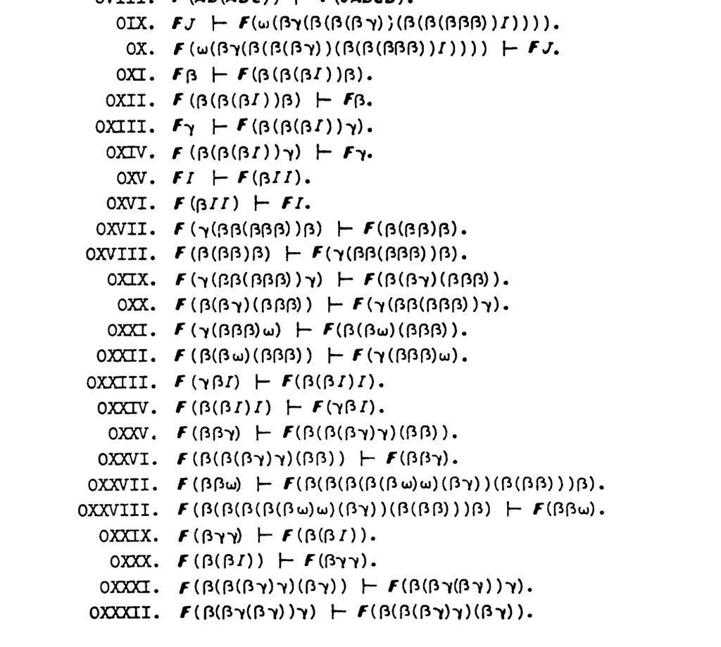

$$OXXXIII.F(βγω)⊢F(β(β(βω)γ)(βγ)).OXXXIV.F(β(β(βω)γ)(βγ))⊢F(βγω).OXXXV.F(βωγ)⊢Fω.OXXXVI.Fω⊢F(βωγ).OXXXVII.F(βωω)⊢F(βω(βω)).OXXXVIII.F(βω(βω))⊢F(βωω).γ→JT(JT)(JT).β→γ(JIγ)(JI).ω→γ(γ(βγ(γ(βJT)T))T).$$

（注意，$T,γ,β,ω$ 分别可转换为 $T,C,B,W$。）

(Note that T, γ, β, ω are convertible respectively into T, C, B, W.)

这三十八种运算具有第 6 节的运算 I、II、III 所没有的简单性特征：（1）它们是单值的，即给定被作用的组合和所施用的三十八种运算中的某一种，所得组合就唯一确定；（2）它们不涉及在任意位置替换的观念，只涉及在指定位置替换的观念。这使第 16 节中的某些展开比原本可能的情形简单得多。

These thirty-eight operations have characteristics of simplicity not possessed by the operations I, II, III of §6, namely: (1) they are one-valued, i.e., given the combination operated on and the particular one of the thirty-eight operations which is applied, the combination resulting is uniquely determined; (2) they do not involve the idea of substitution at an arbitrary place, but only that of substitution at a specified place. This has the effect of rendering some of the developments in §16 much simpler than they otherwise might be.

OI—OXXXVIII 与转换等价的证明太长，无法在这里列出。证明可见罗瑟的博士论文 [47]（参见其中 H 节）。其中许多重要思想和方法来自 Curry [17,18,20,21]；事实上，柯里已有可看作与这里所讨论的结果近似等价的结果，但差别仍然足够大，以致我们不能直接使用它们。

The proof of the equivalence of OI–OXXXVIII to conversion is too long to be included here. It may be found in Rosser’s dissertation [47] (cf. Section H therein). Many of the important ideas and methods involved derive from Curry [17,18,20,21]; in fact, Curry has results which may be thought of as constituting an approximate equivalent to the one in question here but which are nevertheless sufficiently different so that we are unable to use them directly.

### 16. 哥德尔数

### 16. GÖDEL NUMBERS

组合的哥德尔数归纳定义如下：

The Gödel number of a combination is defined by induction as follows:

（1）$I$ 的哥德尔数为 1。

(1) The Gödel number of I is 1.

（2）$J$ 的哥德尔数为 3。

(2) The Gödel number of J is 3.

（3）按字母顺序排列的第 $n$ 个变量（见第 5 节）的哥德尔数为 $2n+5$。

(3) The Gödel number of the nth variable in alphabetical order (see §5) is 2n+5.

（4）若 $m,n$ 分别为 $A,B$ 的哥德尔数，则 $AB$ 的哥德尔数为 $(m+n)(m+n−1)−2n+2$。

(4) If m and n are the Gödel numbers of A and B respectively, the Gödel number of AB is (m+n)(m+n−1)−2n+2.

属于某个公式的哥德尔数，定义为属于该公式的组合的哥德尔数。（注意，属于某个组合的哥德尔数，一般并不等于该组合的哥德尔数。）

The Gödel number belonging to a formula is defined to be the Gödel number of the combination belonging to the formula. (Notice that the Gödel number belonging to a combination is thus in general not the same as the Gödel number of the combination.)

请读者验证：两个组合 $A,B$ 的哥德尔数相同，当且仅当 $A,B$ 相同；属于两个公式 $A,B$ 的哥德尔数相同，当且仅当 $A$ conv-I $B$（参见 12 III）。（注意，按（4）给出的 $AB$ 的哥德尔数，是有序对 $[m,n]$ 在第 9 节末尾所述枚举中的序号的两倍。）

It is left to the reader to verify that the Gödel numbers of two combinations A and B are the same if and only if A and B are the same; and that the Gödel numbers belonging to two formulas A and B are the same if and only if A conv-I B (cf. 12 III). (Notice that the Gödel number of AB, according to (4), is twice the number of the ordered pair [m,n] in the enumeration of ordered pairs described at the end of §9.)

哥德尔数的用途源于这样一个事实：我们的形式系统不含表示公式（即符号序列）的记号。（不能把公式用作它自身的记号，因为可相互转换的公式必须指称同一事物，尽管它们并非同一个公式；而且，含有自由变量的公式不能指称任何固定事物。）属于一个公式的哥德尔数，在许多场合可以代替该公式的记号，并常常使我们能够完成一些本来可能被认为没有公式的形式记号就无法完成的事情。

The usefulness of Gödel numbers arises from the fact that our formalism contains no notations for formulas, i.e., for sequences of symbols. (It is not possible to use formulas as notations for themselves, because interconvertible formulas must denote the same thing although they are not the same formula, and because formulas containing free variables cannot denote any fixed thing.) The Gödel number belonging to a formula serves in many situations as a substitute for a notation for the formula and often enables us to accomplish things which might have been thought to be impossible without a formal notation for formulas.

公式 $form$ 的存在便利了哥德尔数的这种使用：若 $N$ 表示属于 $A$ 的哥德尔数，且 $A$ 不含自由变量，则：

This use of Gödel numbers is facilitated by the existence of a formula, form, such that, if N represents the Gödel number belonging to A, and A contains no free variables, then,

$$formNconvA.$$

为得到这个公式，先注意：若 $N$ 表示具有多于一项的组合的哥德尔数，则 $parN$ conv 2；若 $N$ 表示只有一项的组合的哥德尔数，则 $parN$ conv 1。此外，若 $N$ 表示组合 $AB$ 的哥德尔数，则 $Z(HN)$ 可转换为表示 $A$ 的哥德尔数的公式，而 $Z′(HN)$ 可转换为表示 $B$ 的哥德尔数的公式（见第 9 节）。我们引入缩写：

In order to obtain this formula, first notice that par N conv 2 if N represents the Gödel number of a combination having more than one term, and par N conv 1 if N represents the Gödel number of a combination having only one term; also that if N represents the Gödel number of a combination AB, then Z(HN) is convertible into the formula representing the Gödel number of A, and Z′(HN) is convertible into the formula representing the Gödel number of B (see §9). We introduce the abbreviations:

$$N1→Z(HN),N2→Z′(HN).$$

这种下标可以迭代，例如 $N122$ 是 $Z′(H(Z′(H(Z(HN)))))$ 的缩写。

Subscripts used in this way may be iterated, so that, for instance, N₁₂₂ is an abbreviation for Z′(H(Z′(H(Z(HN))))).

用第 14 节的方法，找出公式 $D$，使：

By the method of §14, find a formula D such that

$$𝔇1convλx.x12,𝔇2convI,𝔇3convλx.x12J,$$

再找出公式 $U$，使：

and a formula U such that

$$U1conv𝔇,U2convλxy.y(parx1)x1y(y(parx2)x2y),$$

（参照 14 I 和 14 II 的证明，可以明确写出这些公式 $D,U$。）令：

(these formulas D and U can be explicitly written down by referring to the proofs of 14 I and 14 II). Let

$$form→λn.U(parn)nU$$

则 $form1$ conv $I$，$form3$ conv $J$；若 $N$ 表示偶正整数，则 $formN$ conv $formN1(formN2)$。由此可知，$form$ 具有上文所述性质：因为若 $N$ 表示属于无自由变量公式 $A$ 的组合 $A′$ 的哥德尔数，则 $formN$ conv $A′$，且 $A′$ conv $A$。

Then form 1 conv I, form 3 conv J, and form N conv form N₁(form N₂) if N represents an even positive integer. From this it follows that form has the property ascribed to it above; for if N represents the Gödel number of a combination A′ belonging to a formula A, containing no free variables, then form N conv A′, and A′ conv A.

令：

Let:

$$σ→λn.[parn+parn1+eq24812¯n11+[3∔eq156¯n12]+parn2+eq12¯n21∔10¯]+[2·[parn+parn1+eq24812¯n11+[3∔min(parn2)(eq12¯n21)]∔6]]+[3·[parn+eq623375746¯n1+parn2+eq12¯n21+parn22+eq623375746¯n221+parn222+parn2221+eq24812¯n22211+parn2222+parn22221+eq24812¯n222211+eq3n22222∔24¯]]∔5.$$

**原图对照 / Source scan for verification**

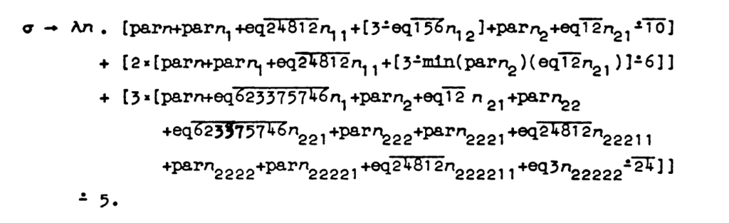

注意到 $JI,T,JT,JTT$ 的哥德尔数分别为 12、156、24812、623375746，读者可验证：若 $N$ 表示正整数，则 $aN$ conv 1、2、3 或 4；若它表示形式为 $JTB(JIA)$ 且 $B$ 不同于 $T$ 的组合的哥德尔数，则 conv 2；若它表示形式为 $JTBA$ 但不是 $JTB(JIA)$ 的组合的哥德尔数，则 conv 3；若它表示形式为 $JTT(JI(JTT(JTB(JTAJ))))$ 的组合的哥德尔数，则 conv 4；若它表示不属于上述三种形式的组合的哥德尔数，则 conv 1。

Noting that the Gödel numbers of JI, T, JT, JTT are respectively 12, 156, 24812, 623375746, the reader may verify that: aN conv 1, 2, 3, or 4 if N represents a positive integer; aN conv 2 if N represents the Gödel number of a combination of the form JTB(JIA), with B different from T; aN conv 3 if N represents the Gödel number of a combination of the form JTBA but not of the form JTB(JIA); aN conv 4 if N represents the Gödel number of a combination of the form JTT(JI(JTT(JTB(JTAJ)))); aN conv 1 if N represents the Gödel number of a combination not of one of these three forms.

再次利用第 14 节，找出公式 $u$，使：

Again using §14, we find a formula u such that

$$u1convλxy.y5xu2convλxy.y(ox12)x12yu3convλxy.y(ox2)x2yu4convλxy.min(y(ox22212)x22212y)(y(ox222212)x222212y)u5convλx.3∔x$$

并令：

and we let

$$o→λn.u(σn)nu$$

则 $o$ λ 定义一个正整数函数：当变元是形式为 $〚xM⟧$ 的组合的哥德尔数时取值 2；当变元是非此形式的组合的哥德尔数时取值 1。简言之，$o$ λ 定义组合具有形式 $〚xM⟧$ 这一性质。

Then o λ-defines a function of positive integers whose value is 2 for an argument which is the Gödel number of a combination of the form 〚xM⟧, and 1 for an argument which is the Gödel number of a combination not of this form, or, as we shall say briefly, o λ-defines the property of a combination of being of the form 〚xM⟧.

通过类似的构造，虽细节冗长，但原理上没有新内容，可以得到下列公式：

By similar constructions, involving lengthy detail but nothing new in principle, the following formulas may be obtained:

1）公式 $occ$，使得当 $N$ 表示正整数 $n$ 时，$occN$ λ 定义组合含有按字母顺序排列的第 $n$ 个变量作为自由变量（即作为一项）的性质。

1) A formula, occ, such that, if N represents a positive integer n, we have that occ N λ-defines the property of a combination of containing the nth variable in alphabetical order, as a free variable (i.e., as a term).

2）公式 $e$，使得当 $N$ 表示正整数 $n$ 时，若 $G$ 表示非 $〚xM⟧$ 形式的组合的哥德尔数，则 $eNG$ conv $G$；若 $G$ 表示组合 $〚xM⟧$ 的哥德尔数，则 $eNG$ 可转换为表示如下组合的哥德尔数的公式：在 $M$ 中把 $x$ 的全部自由出现替换为按字母顺序排列的第 $n$ 个变量。

2) A formula e, such that, N representing a positive integer n, if G represents the Gödel number of a combination not of the form 〚xM⟧, then eNG conv G, and if G represents the Gödel number of a combination 〚xM⟧, then eNG is convertible into the formula representing the Gödel number of the combination obtained from M by substituting for all free occurrences of x in M the nth variable in alphabetical order.

3）公式 $e′$，使得若 $G$ 表示非 $〚xM⟧$ 形式的组合的哥德尔数，则 $e′G$ conv $G$；若 $G$ 表示组合 $〚xM⟧$ 的哥德尔数，则 $e′G$ 可转换为表示如下组合的哥德尔数的公式：在 $M$ 中把 $x$ 的全部自由出现替换为按字母顺序第一个未在 $M$ 中自由出现的变量。

3) A formula e′, such that, if G represents the Gödel number of a combination not of the form 〚xM⟧, then e′G conv G, and if G represents the Gödel number of a combination 〚xM⟧, then e′G is convertible into the formula representing the Gödel number of the combination obtained from M by substituting for all free occurrences of x in M the first variable in alphabetical order which does not occur in M as a free variable.

4）一个公式，λ 定义组合具有“存在某个公式使该组合属于它”这一性质。

4) A formula which λ-defines the property of a combination, that there is a formula to which it belongs.

5）公式 $Λ$，λ 定义组合属于形式为 $λxM$ 的某个公式这一性质。

5) A formula Λ which λ-defines the property of a combination of belonging to a formula of the form λxM.

6）公式 $prim$，λ 定义组合不含自由变量这一性质。

6) A formula, prim, which λ-defines the property of a combination of containing no free variables.

7）公式 $norm$，λ 定义组合属于某个处于正规形的公式这一性质。

7) A formula, norm, which λ-defines the property of a combination of belonging to a formula which is in normal form.

8）公式 $o1$，在如下意义上对应于第 15 节的运算 OI：若 $G$ 表示某个组合的哥德尔数，且 OI 不适用于该组合，则 $o1G$ conv $G$；若 $G$ 表示可施用 OI 的组合 $M$ 的哥德尔数，则 $o1G$ 可转换为表示对 $M$ 施用 OI 所得组合的哥德尔数的公式。

8) A formula o₁ which corresponds to the operation OI of §15, in the sense that, if G represents the Gödel number of a combination of such a form that OI is not applicable to it, then o₁G conv G, and if G represents the Gödel number of a combination M to which OI is applicable, then o₁G is convertible into the formula representing the Gödel number of the combination obtained from M by applying OI.

9）公式 $o2,o3,…,o38$，在同一意义上分别对应于第 15 节的运算 OII、OIII、……、OXXXVIII。

9) Formulas o₂, o₃, …, o₃₈ which correspond respectively to the operations OII, OIII, …, OXXXVIII of §15, in the same sense.

由 14 III，可以找到公式 $cb$，表示包含 1 和 3、并对从公式 $X,Y$ 形成 $(λab.2•nrab)XY$ 的运算封闭的最小公式集的一个枚举。但若 $X,Y$ 分别表示组合 $A,B$ 的哥德尔数，则 $(λab.2•nrab)XY$ 可转换为表示 $AB$ 的哥德尔数的公式。因此，公式 $cb$ 枚举不含自由变量的组合的哥德尔数；其意义是，每个表示这种哥德尔数的公式都可转换为无穷序列 $cb1,cb2,…$ 中的某个公式，而序列中每个公式也都可转换为表示这种哥德尔数的公式。

By 14 III, a formula, cb, can be found which represents an enumeration of the least set of formulas which contains 1 and 3 and is closed under the operation of forming (λab.2•nr ab)XY from the formulas X,Y. But if X,Y represent the Gödel numbers of combinations A,B respectively, then (λab.2•nr ab)XY is convertible into the formula which represents the Gödel number of AB. Hence the formula, cb, enumerates the Gödel numbers of combinations containing no free variables, in the sense that every formula representing such a Gödel number is convertible into one of the formulas in the infinite sequence cb 1, cb 2, …, and every formula in this infinite sequence is convertible into a formula representing such a Gödel number.

现在若令：

If now we let

$$ncb→λn.cb(G′(λx.norm(cbx))n)$$

则 $ncb$ 在同一意义上枚举那些属于正规形公式且不含自由变量的组合的哥德尔数（参见 10 II）。

then ncb enumerates, in the same sense, the Gödel numbers of combinations which belong to formulas in normal form and contain no free variables (cf. 10 II).

由 14 IV，可以找到公式 $O$，表示包含 $I$、并对从公式 $X$ 形成 $(λab.oβ(ab))X$ 的三十八种运算（$β=1,2,…,38$）中的每一种封闭的最小公式集的一个枚举。令：

By 14 IV, a formula O can be found which represents an enumeration of the least set of formulas which contains I and is closed under each of the thirty-eight operations of forming (λab.oᵦ(ab))X from the formula X (β = 1,2,…,38). Let

$$cnvt→λab.Oba.$$

则若 $G$ 表示组合 $M$ 的哥德尔数，公式 $cnvtG$ 就枚举可由 $M$ 经转换得到的组合的哥德尔数（仍按前两段的同一意义）；参见第 15 节。

Then if G represents the Gödel number of a combination M, the formula, cnvt G, enumerates (again in the same sense as in the two preceding paragraphs) the Gödel numbers of combinations obtainable from M by conversion; cf. §15.

令：

Let

$$nf→λn.cnvtn(𝔭(λx.norm(cnvtnx))1).$$

则 $nf$ 在如下意义上 λ 定义“公式的正规形”这一运算：（1）若 $G$ 表示组合 $M$ 的哥德尔数，则 $nfG$ 可转换为表示属于 $M$ 的正规形的哥德尔数的公式；从而（2）若 $G$ 表示属于公式 $M$ 的哥德尔数，则 $nfG$ 可转换为表示属于 $M$ 的正规形的哥德尔数的公式。若 $G$ 表示一个无正规形的组合的哥德尔数，或属于一个无正规形的公式的哥德尔数，则 $nfG$ 无正规形（参见 10 I）。

Then nf λ-defines the operation normal form of a formula, in the sense that (1) if G represents the Gödel number of a combination M, then nf G is convertible into the formula representing the Gödel number belonging to the normal form of M; and hence (2) if G represents the Gödel number belonging to a formula M, then nf G is convertible into the formula representing the Gödel number belonging to the normal form of M. If G represents the Gödel number of a combination (or belonging to a formula) which has no normal form, then nf G has no normal form (cf. 10 I).

令 $i,s$ 分别为表示属于 $1,S$ 的哥德尔数的公式。则下列公式分别可转换为表示属于 $1,S1,S(S1),…$ 的哥德尔数的公式：

Let i and s be the formulas representing the Gödel numbers belonging to 1 and S respectively. Then the formulas

$$Z′(H(1(λx.2·nrsx)i)),Z′(H(2(λx.2·nrsx)i)),Z′(H(3(λx.2·nrsx)i)),⋯,$$

因此，可以通过如下定义得到公式 $v$，它 λ 定义组合属于某个表示正整数的正规形公式这一性质：

are convertible respectively into formulas representing Gödel numbers belonging to 1, S1, S(S1), …. Hence a formula v which λ-defines the property of a combination of belonging to a formula in normal form which represents a positive integer, may be obtained by defining:

$$v→λn.π(eqn)(λm.eqn(nf(Z′(H(m(λx.2·nrsx)i)))))$$

（要看出这一点，必须参照 10 III，并注意：属于一个表示正整数的正规形公式的哥德尔数，总是大于该正整数。）

(It is necessary, in order to see this, to refer to 10 III, and to observe that the Gödel number belonging to a formula in normal form representing a positive integer is always greater than that positive integer.)

## 第五章 λ-K 转换演算与 λ-δ 转换演算

## Chapter V. THE CALCULI OF λ-K-CONVERSION AND λ-δ-CONVERSION

### 17. λ-K 转换演算

### 17. THE CALCULUS OF λ-K-CONVERSION

只须对第 5、6 节中的 λ 转换演算构造作一处修改，就得到 λ-K 转换演算：在合式公式的定义（第 5 节）中，从规则 3 删去“并且至少含有 $x$ 的一次自由出现”这几个字。第 6 节中的转换规则 I、II、III 保持不变，只是“合式”须按新的意义理解。

The calculus of λ-K-conversion is obtained if a single change is made in the construction of the calculus of λ-conversion which appears in §§5,6: namely, in the definition of well-formed formula (§5) deleting the words “and contains at least one free occurrence of x” from the rule 3. The rules of conversion, I,II,III, in §6 remain unchanged, except that well-formed is understood in the new sense.

λ 转换演算与 λ-K 转换演算之间差别的一个典型例子，是在后者中可以定义常值函数：

Typical of the difference between the calculi of λ-conversion and λ-K-conversion is the possibility of defining in the latter the constancy function,

$$K→λa(λb.a),$$

以及仿照第 8 节中正整数的定义，定义整数零：

and the integer zero, by analogy with definitions of the positive integers in §8,

$$0→λa(λb.b).$$

第 7 节的许多定理在 λ-K 转换演算中也成立。但 7 III 和 7 V 必须作显然的小修改，而下列定理不再成立：7 XVII、7 XXVI 的第（3）款、7 XXXI 和 7 XXXII。可以证明下列较弱定理来代替 7 XXXI；它对某些目的已足够，特别是对 $𝔭$ 的定义（见第 10 节）：

Many of the theorems of §7 hold also in the calculus of λ-K-conversion. But obvious minor modifications must be made in 7 III and 7 V, and the following theorems fail: 7 XVII, clause (3) of 7 XXVI, and 7 XXXI, and 7 XXXII. Instead of 7 XXXI, the following weaker theorem can be proved, which is sufficient for certain purposes, in particular for the definition of 𝔭 (see §10):

17 I. 若某次归约中规则 II 的应用，是对如下形式的公式中开头的 $(λxM)N1$ 作收缩，就称该归约为一阶归约：

17 I. Let a reduction be called of order one if the application of Rule II involved is a contraction of the initial (λxM)N₁ in a formula of the form

$$(λxM)N1N2…Nn.$$

则若 $A$ 具有正规形，存在数 $m$，使对 $A$ 的任一归约序列中至多出现 $m$ 次一阶归约。

Then if A has a normal form, there is a number m such that at most m reductions of order one can occur in a sequence of reductions on A.

可以仿照正整数函数的 λ 可定义性，引入非负整数函数的 λ-K 可定义性概念，于是第三章的展开便可以在 λ-K 转换演算中完全平行地进行。后继函数、加法和乘法可采用与第三章相同的定义。零的存在使许多展开得到简化；特别是，在前驱函数的定义中可以用有序对代替有序三元组，而 $𝔭$ 的定义也可按 Turing [58] 加以简化。

A notion of λ-K-definability of functions of non-negative integers may be introduced, analogous to that of λ-definability of functions of positive integers, and the developments of Chapter III may then be completely paralleled in the calculus of λ-K-conversion. The same definitions may be employed for the successor function and for addition and multiplication as in Chapter III. Many of the developments are simplified by the presence of the zero: in particular, ordered pairs may be employed instead of ordered triads in the definition of the predecessor function, and the definition of 𝔭 may be simplified as in Turing [58].

可以证明（见 Kleene [37]、Turing [57]），单个非负整数变元的函数 $F$ 是 λ-K 可定义的，当且仅当 $λx.F(x−1)+1$ 是 λ 可定义的；多变元函数也有类似结果。

It can be proved (see Kleene [37], Turing [57]) that a function F of one non-negative integer argument is λ-K-definable if and only if λx.F(x−1)+1 is λ-definable, and similarly for functions of more than one argument.

λ-K 转换演算相对于 λ 转换演算有显然的优点，包括能够定义常值函数，以及以更简单、更自然的方式引入整数零。然而，对许多目的，特别是对下文第 21 节所勾勒的那种符号逻辑系统的展开，7 XXXII 的失效所造成的损失远远超过这些优点。事实上，若我们认为恰好那些具有正规形的公式才有意义，那么 $FM$ 有正规形而 $M$ 无正规形（这在 λ-K 转换演算中可能发生），显然就变得不合理。即使对有意义性施加更严格的条件，仍可从下述理由反对 λ-K 转换演算的规则 III：若 $N$ 是不含自由变量的有意义公式，那么除非 $M$ 有意义，否则不应允许用 $(λxN)M$ 替换 $N$。这种说法涉及公式的意义，因而诉诸直观；但在某些方向的形式展开中，确实会出现相应的困难。

The calculus of λ-K-conversion has obvious advantages over the calculus of λ-conversion, including the possibility of defining the constancy function and of introducing the integer zero in a simpler and more natural way. However, for many purposes, in particular for the development of a system of symbolic logic such as that sketched in §21 below, these advantages are more than offset by the failure of 7 XXXII. Indeed if we regard those and only those formulas as meaningful which have a normal form, it becomes clearly unreasonable that FM should have a normal form and M have no normal form (as may happen in the calculus of λ-K-conversion); or even if we impose a more stringent condition of meaningfulness, Rule III of the calculus of λ-K-conversion can be objected to on the ground that if N is a meaningful formula containing no free variables, the substitution of (λxN)M for N ought not to be possible unless M is meaningful. This way of putting the matter involves the meanings of the formulas, and thus an appeal to intuition, but corresponding difficulties do appear in the formal developments in certain directions.

### 18. 受限 λ-K 转换演算

### 18. THE CALCULUS OF RESTRICTED λ-K-CONVERSION

为避免刚才所述的困难，Bernays [4] 提议修改 λ-K 转换演算，在规则 II、III 中加入条件，要求 $M$ 必须处于正规形（注意，“处于正规形”这一条件是有效的，尽管“具有正规形”这一条件不是）。我们把所得演算称为受限 λ-K 转换演算。由第 7 节的方法可知，在这个演算中，一个在 λ-K 转换演算中具有正规形、且不含无正规形部分的公式，仍将具有同一个正规形；特别地，在 λ 转换演算中已有的转换到正规形的可能性没有丧失。另一方面，定理 7 XXVIII—7 XXXII 在受限 λ-K 转换演算中仍然有效，而且比在 λ 转换演算中更容易证明。（还应补充：7 XXVIII—7 XXXII 对受限 λ-K 转换演算的内容，在某种意义上比这些定理对 λ 转换演算的内容少得多；事实上，如果不加上这样的定理，即对于所有部分都有正规形的公式，它与不受限的 λ-K 转换演算等价，那么从直观观点看，这些定理还不足以确立受限 λ-K 转换演算的妥当性。）

In order to avoid the difficulty just described, Bernays [4] has proposed a modification of the calculus of λ-K-conversion which consists in adding to Rules II and III the proviso that M shall be in normal form (notice that the condition of being in normal form is effective, although that of having a normal form is not). We shall call the calculus so obtained the calculus of restricted λ-K-conversion. In it, as follows by the methods of §7, a formula which in the calculus of λ-K-conversion had a normal form and had no parts without normal form will continue to have the same normal form; in particular, no possibility of conversion into a normal form is lost which existed in the calculus of λ-conversion. On the other hand, all of the theorems 7 XXVIII–7 XXXII remain valid in the calculus of restricted λ-K-conversion, and are much more simply proved than in the calculus of λ-conversion. (It should be added that the content of the theorems 7 XXVIII–7 XXXII for the calculus of restricted λ-K-conversion is in a certain sense much less than the content of these theorems for the calculus of λ-conversion, and in fact cannot be regarded as sufficient to establish the satisfactoriness of the calculus of restricted λ-K-conversion from an intuitive viewpoint without addition of such a theorem as that asserting the equivalence to the calculus of unrestricted λ-K-conversion in the case of formulas all of whose parts have normal forms.)

受限 λ-K 转换演算的展开，可以紧密遵循 λ 转换演算的展开（如第二至四章），并作第 17 节为 λ-K 转换演算所指出的那些修改。许多定理必须补充假设，断言其中某些公式具有正规形。

The development of the calculus of restricted λ-K-conversion may follow closely that of the calculus of λ-conversion (as in Chapters II–IV), with such modifications as are indicated in §17 for the calculus of λ-K-conversion. Many of the theorems must have added hypotheses asserting that certain of the formulas involved have normal forms.

### 19. 超限序数

### 19. TRANSFINITE ORDINALS

Church 和 Kleene [15] 已把 λ 可定义性的概念推广到第二数类的序数及这些序数的函数。由此，一方面得到有效可计算性概念向第二数类的推广（参见 Church [13]、Kleene [39]、Turing [59]）；另一方面得到把某些序数理论引入下文第 21 节符号逻辑系统的方法。

Church and Kleene [15] have extended the concept of λ-definability to ordinal numbers of the second number class and functions of such ordinal numbers. There results from this on the one hand an extension of the notion of effective calculability to the second number class (cf. Church [13], Kleene [39], Turing [59]), and on the other hand a method of introducing some theory of ordinal numbers into the system of symbolic logic of §21 below.

这里不重述在 λ 转换演算中的这一展开，而是简略勾勒在受限 λ-K 转换演算中的类似展开。

Instead of reproducing here this development within the calculus of λ-conversion, we sketch briefly an analogous development within the calculus of restricted λ-K-conversion.

按照第 8 节定义背后的思想，正整数（或非负整数）是某些函数的函数，即一个函数在迭代意义下的有限次幂。如果先固定一个取超限幂所依据的极限过程，就可以让第二数类的序数以同样方式对应于一个函数的超限次幂，从而把这一思想推广到这些序数。例如，可以把序数 $ω$ 取为这样一个函数：它以函数 $f$ 为变元时的值是函数 $g$，使 $gx$ 是序列 $x,fx,f(fx),…$ 的极限。于是 $ω+1$ 就是 $λx.f(ωfx)$，依此类推。

According to the idea underlying the definitions of §8, the positive integers (or the non-negative integers) are certain functions of functions, namely the finite powers of a function in the sense of iteration. This idea might be extended to the ordinal numbers of the second number class by allowing them to correspond in the same way to the transfinite powers of a function, provided that we first fixed upon a limiting process relative to which the transfinite powers should be taken. Thus the ordinal ω could be taken as the function whose value for a function f as argument is the function g such that gx is the limit of the sequence x, fx, f(fx), …. Then ω+1 would be λx.f(ωfx), and so on.

或者，不固定一个极限过程，而把它作为一个附加变元 $a$ 引入。例如，把序数 $ω$ 取为这样一个函数：以 $a,f$ 为变元时的值是函数 $g$，使 $gx$ 是序列 $x,fx,f(fx),…$ 相对于极限过程 $a$ 的极限。这导出受限 λ-K 转换演算中的下列定义，其中下标 $o$ 用于把这些记号与其他场合使用的类似记号区分开：

Or, instead of fixing upon a limiting process, we may introduce the limiting process as an additional argument a (for instance taking the ordinal ω to be the function whose value for a and f as arguments is the function g such that gx is the limit of the sequence x, fx, f(fx), …, relative to the limiting process a). This leads to the following definitions in the calculus of restricted λ-K-conversion, the subscript o being used to distinguish these notations from similar notations used in other connections:

我们规定：$0o$ 表示序数 0；若 $N$ 表示序数 $n$，则 $SoN$ 的主正规形表示序数 $n+1$；若 $R$ 表示单调递增的序数无穷序列 $n0,n1,n2,…$，其意义是 $R0o,R1o,R2o,…$ 分别可转换为表示 $n0,n1,n2,…$ 的公式，则 $LoR$ 的主正规形表示该序数无穷序列的上极限。这样，被公式表示的超限序数构成第二数类的某个初段，可以把它描述为那些能够从下方有效构造到达的序数，具体意义这里不作明确说明。

We prescribe that 0ₒ shall represent the ordinal 0; if N represents the ordinal n, the principal normal form of SₒN shall represent the ordinal n+1; if R represents the monotone increasing infinite sequence of ordinals n₀,n₁,n₂,…, in the sense that R0ₒ, R1ₒ, R2ₒ,… are convertible into formulas representing n₀,n₁,n₂,… respectively, then the principal normal form of LₒR shall represent the upper limit of this infinite sequence of ordinals. The transfinite ordinals which are represented by formulas then turn out to constitute a certain segment of the second number class, which may be described as consisting of those ordinals which can be effectively built up to from below (in a sense which we do not make explicit here).

表示第二数类中某个给定序数的公式并不唯一。例如，序数 $ω$ 不仅由 $ωo$ 表示，也由 $LoSo$ 的主正规形及许多其他公式表示。因此，表示序数的公式不应被看作指称序数本身，而应看作指称某些与序数存在多对一对应的东西。

The formula representing a given ordinal of the second number class is not unique: for example, the ordinal ω is represented not only by ωₒ but also by the principal normal form of LₒSₒ, and by many other formulas. Hence the formulas representing ordinals are not to be taken as denoting ordinals but rather as denoting certain things which are in many-one correspondence with ordinals.

序数函数 $F$ 称为由公式 $F$ λ-K 定义，如果：（1）每当 $Fm=n$ 且 $M$ 表示 $m$ 时，公式 $FM$ 都可转换为表示 $n$ 的公式；（2）每当序数 $m$ 不在 $F$ 的定义范围内且 $M$ 表示 $m$ 时，公式 $FM$ 都无正规形。

A function F of ordinal numbers is said to be λ-K-defined by a formula F if (1) whenever Fm = n and M represents m, the formula FM is convertible into a formula representing n, and (2) whenever an ordinal m is not in the range of F and M represents m, the formula FM has no normal form.

上述叙述预设了经典的第二数类。通过适当修改（参见 Church [13]），可以消除这一预设，从而利用受限 λ-K 转换演算来定义一个非经典的构造性第二数类；在其中，每个经典序数若得到表示，就由无穷多个元素表示。

The foregoing account presupposes the classical second number class. By suitable modifications (cf. Church [13]), this presupposition may be eliminated, with the result that the calculus of restricted λ-K-conversion is used to obtain a definition of a non-classical constructive second number class, in which each classical ordinal is represented, if at all, by an infinity of elements.

### 20. λ-δ 转换演算

### 20. THE CALCULUS OF λ-δ-CONVERSION

λ-δ 转换演算是对第 5、6 节中的 λ 转换演算构造作如下修改而得到的：把符号 $δ$ 加入原始符号表；它既不是非正常符号，也不是变量，而是与变量同属正常符号；在合式公式定义的规则 1 中补充规定，符号 $δ$ 是合式公式；在第 6 节的转换规则中加入下列四条附加规则：

The calculus of λ-δ-conversion is obtained by making the following changes in the construction of the calculus of λ-conversion which appears in §§5,6: adding to the list of primitive symbols a symbol δ, which is neither an improper symbol nor a variable, but is classed with the variables as a proper symbol; adding to the rule 1 in the definition of well-formed formula that the symbol δ is a well-formed formula; and adding to the rules of conversion in §6 four additional rules, as follows:

IV. 把公式中任意部分 $δMN$ 替换为 $1$，条件是 $M,N$ 处于 δ 正规形、不含自由变量，且 $N$ 不能转换-I 为 $M$。

IV. To replace any part δMN of a formula by 1, provided that M and N are in δ-normal form and contain no free variables and N is not convertible-I into M.

V. 把公式中任意部分 $1$ 替换为 $δMN$，条件是 $M,N$ 处于 δ 正规形、不含自由变量，且 $N$ 不能转换-I 为 $M$。

V. To replace any part 1 of a formula by δMN, provided that M and N are in δ-normal form and contain no free variables and N is not convertible-I into M.

VI. 把公式中任意部分 $δNN$ 替换为 $2$，条件是 $N$ 处于 δ 正规形且不含自由变量。

VI. To replace any part δNN of a formula by 2, provided that N is in δ-normal form and contains no free variables.

VII. 把公式中任意部分 $2$ 替换为 $δNN$，条件是 $N$ 处于 δ 正规形且不含自由变量。

VII. To replace any part 2 of a formula by δNN, provided that N is in δ-normal form and contains no free variables.

这里，一个公式称为处于 δ 正规形，如果它不含形如 $(λxP)Q$ 的部分，也不含形如 $δRS$ 且 $R,S$ 不含自由变量的部分。必须注意，“处于 δ 正规形”以及“$N$ 不能转换-I 为 $M$”这两个条件都是有效的。

Here a formula is said to be in δ-normal form if it contains no part of the form (λxP)Q and contains no part of the form δRS with R and S containing no free variables. It is necessary to observe that both the condition of being in δ-normal form and the condition that N is not convertible-I into M are effective.

一个转换（或 λ-δ 转换）是规则 I—VII 的应用的有限序列。若一个 λ-δ 转换不含规则 III、V、VII 的应用，并且恰好含有一次规则 II、IV、VI 之一的应用，则称它为归约（或 λ-δ 归约）。若存在从 $A$ 到 $B$ 的归约，则称 $A$ 可立即归约到 $B$；若存在从 $A$ 到 $B$ 的转换，且它由一次或多次连续归约组成，则称 $A$ 可归约到 $B$。

A conversion (or a λ-δ-conversion) is a finite sequence of applications of Rules I–VII. A λ-δ-conversion is called a reduction (or a λ-δ-reduction) if it contains no application of Rules III,V,VII and exactly one application of one of the Rules II,IV,VI. A is said to be immediately reducible to B if there is a reduction of A into B, and A is said to be reducible to B if there is a conversion of A into B which consists of one or more successive reductions.

第 7 节的所有定理在 λ-δ 转换演算中也都成立，只须作适当修改（见 Church and Rosser [16]）。施用规则 I 或 II 后，$(λxMp)Np$ 的残余与以前同样定义；施用 IV 或 VI 后，其残余定义为它变成的东西，这总是某个形如 $(λxpM′p)N′p$ 的东西。$δMpNp$ 在施用 I、II、IV 或 VI 后的残余，仅在 $Mp,Np$ 处于 δ 正规形且不含自由变量时定义；其定义是它变成的东西，但在施用 IV 或 VI 且 $δMpNp$ 本身被收缩（即替换为 1 或 2）时，它没有残余。因此，$δMpNp$ 的残余总是形如 $δM′N′$，其中 $M′,N′$ 处于 δ 正规形且不含自由变量。对 $A1$ 中一组部分 $(λxjMj)Nj$ 和 $δRiSi$（其中 $Ri,Si$ 处于 δ 正规形且不含自由变量）的收缩序列，仿照第 7 节的定义来定义；这种收缩的终止序列也类似定义。在 7 XXV 中，允许取收缩序列的部分集不仅包含形如 $(λxjMj)Nj$ 的部分，也包含形如 $δRiSi$、且 $Ri,Si$ 处于 δ 正规形并不含自由变量的部分。对第 7 节的证明作显然的扩展，就能证明修改后的 7 XXV，随后 7 XXVI—7 XXXII 像以前一样得出。在 7 XXVI—7 XXXII 中，必须把各处的 “conv-I-II” 替换为 “conv-I-II-IV-VI”；在 7 XXVI 中，还须考虑 $A$ imr $B$ 是通过收缩 $A$ 的部分 $δMN$ 而得到的情形。对于 7 XXX，须仿照第 6 节的主 λ 正规形定义，给出公式的主 δ 正规形定义。

All the theorems of §7 hold also in the calculus of λ-δ-conversion, if some appropriate modifications are made (see Church and Rosser [16]). The residuals of (λxMₚ)Nₚ after an application of Rule I or II are defined in the same way as before, and after an application of IV or VI they are defined as what (λxMₚ)Nₚ becomes (this is always something of the form (λxₚM′ₚ)N′ₚ). The residuals of δMₚNₚ after an application of I,II,IV, or VI are defined only in the case that Mₚ and Nₚ are in δ-normal form and contain no free variables, and are defined as what δMₚNₚ becomes, except that after an application of IV or VI in which δMₚNₚ itself is contracted (i.e., replaced by 1 or 2), δMₚNₚ has no residual. Thus residuals of δMₚNₚ are always of the form δM′N′, where M′ and N′ are in δ-normal form and contain no free variables. A sequence of contractions on a set of parts (λxⱼMⱼ)Nⱼ and δRᵢSᵢ of A₁, where Rᵢ and Sᵢ are in δ-normal form and contain no free variables, is defined by analogy with the definition in §7. Similarly a terminating sequence of such contractions. In 7 XXV, the set of parts of A on which a sequence of contractions is taken is allowed to include not only parts of the form (λxⱼMⱼ)Nⱼ but also parts of the form δRᵢSᵢ in which Rᵢ and Sᵢ are in δ-normal form and contain no free variables. The modified 7 XXV may then be proved by an obvious extension of the proof given in §7, and thereupon 7 XXVI–7 XXXII follow as before. In 7 XXVI–7 XXXII “conv-I-II” must be replaced throughout by “conv-I-II-IV-VI” and in 7 XXVI the case must also be considered that A imr B by a contraction of the part δMN of A. For 7 XXX, there must be supplied a definition of principal δ-normal form of a formula, analogous to the definition in §6 of the principal λ-normal form.

讨论 λ-δ 转换演算时，我们同时使用“λ 转换”和“λ-δ 转换”两个术语：前者指规则 I—III 的应用的有限序列，后者指规则 I—VII 的应用的有限序列。如前所述，单独的“转换”一词表示 λ-δ 转换。

In connection with the calculus of λ-δ-conversion we shall use both of the terms λ-conversion and λ-δ-conversion, the former meaning a finite sequence of applications of Rules I–III, the latter a finite sequence of applications of Rules I–VII. The term conversion will be used to mean a λ-δ-conversion, as already explained.

类似地，我们同时使用“公式的 λ 正规形”和“公式的 δ 正规形”两个术语。若一个公式处于 λ 正规形，且可由另一个公式经 λ 转换得到，就称它为后者的一个 λ 正规形。若一个公式处于 δ 正规形，且可由另一个公式经 λ-δ 转换得到，就称它为后者的一个 δ 正规形。把 7 XXIX 应用于 λ 转换演算可知，λ-δ 转换演算中一个公式的 λ 正规形，若存在，则在规则 I 的应用意义下唯一。由 λ-δ 转换演算中与 7 XXIX 对应的定理可知，一个公式的 δ 正规形，若存在，也在规则 I 的应用意义下唯一。

Similarly we shall use both of the terms λ-normal form of a formula and δ-normal form of a formula. A formula will be called a λ-normal form of another if it is in λ-normal form and can be obtained from the other by λ-conversion. A formula will be called a δ-normal form of another if it is in δ-normal form and can be obtained from the other by λ-δ-conversion. By 7 XXIX applied to the calculus of λ-conversion, the λ-normal form of a formula (in the calculus of λ-δ-conversion), if it exists, is unique to within applications of Rule I. By the analogue of 7 XXIX for the calculus of λ-δ-conversion, the δ-normal form of a formula, if it exists, is unique to within applications of Rule I.

要看出 λ-δ 转换演算要求内涵解释（参见第 2 节），只须注意：例如，虽然 $1$ 和 $λab.δab1ab$ 在外延上对应于同一个函数，它们却不能互换，因为 $δ11$ conv $2$，但 $δ1(λab.δab1ab)$ conv $1$。

In order to see that the calculus of λ-δ-conversion requires an intensional interpretation (cf. §2), it is sufficient to observe that, for example, although 1 and λab.δab1ab correspond to the same function in extension, they are nevertheless not interchangeable, since δ11 conv 2 but δ1(λab.δab1ab) conv 1.

可以定义一个常值函数 $κ$：

A constancy function κ may be defined:

$$κ→λab.δbb1a.$$

于是，$κAB$ conv $A$ 当且仅当 $B$ 具有 δ 正规形且不含自由变量。因此，$κ$ 的转换性质弱于两种 λ-K 转换演算中公式 $K$ 的转换性质。

Then κAB conv A, if B has a δ-normal form and contains no free variables, and in that case only (the conversion properties of κ are thus weaker than those of the formula K in either of the calculi of λ-K-conversion).

正整数函数的 λ 可定义性理论可以全部移植到 λ-δ 转换演算中，因为 λ 转换演算作为一个部分包含在 λ-δ 转换演算中。只须证明，正整数函数的 λ-δ 可定义性概念并不比 λ 可定义性概念更一般；这一点可由已知方法证明，例如 Kleene [37] 的方法。

The entire theory of λ-definability of functions of positive integers carries over into the calculus of λ-δ-conversion, since the calculus of λ-conversion is contained in that of λ-δ-conversion as a part. It only requires proof that the notion of λ-δ-definability of functions of positive integers is not more general than that of λ-definability, and this can be supplied by known methods (e.g., those of Kleene [37]).

组合理论可移植到 λ-δ 转换演算中，只须把组合重新定义为 ${I,J,δ}$ 组合。在定义属于一个公式的组合时，须补充规定，属于 $δ$ 的组合就是 $δ$。

The theory of combinations carries over into the calculus of λ-δ-conversion, provided that we redefine a combination to mean an {I,J,δ}-combination. In defining the combination belonging to a formula, it is necessary to add the provision that the combination belonging to δ is δ.

若 $A1$ 是 λ-δ 转换演算的合式公式且不含自由变量，则可找到公式 $B1$，使 $B1J$ conv $A1$，且 $B1I$ conv $I$。因为，令 $A′1$ 为属于 $A1$ 的组合；但若该组合既不含 $J$ 也不含 $δ$ 的出现，则令 $A′1$ 为 $JIIII$。令 $A″1$ 为在 $A′1$ 中把所有 $J,δ$ 分别替换为 $j$ 和 $δIj(λx.x(λv.vIII))(λz.zI)δ$ 所得的结果。则 $B1$ 可以取为 $λjA″1$。

If A₁ is a well-formed formula of the calculus of λ-δ-conversion and contains no free variables, a formula B₁ can be found such that B₁J conv A₁ and B₁I conv I. For let A′₁ be the combination belonging to A₁, unless that combination fails to contain an occurrence of either J or δ, in which case let A′₁ be JIIII. Let A″₁ be obtained from A′₁ by replacing J and δ throughout by j and δIj(λx.x(λv.vIII))(λz.zI)δ respectively. Then B₁ may be taken as λjA″₁.

因此，可以用与 λ 转换演算相同的方法，证明 λ-δ 转换演算中的 14 I 及第 14 节的其余定理。

Hence 14 I, and the remaining theorems of §14, may be proved for the calculus of λ-δ-conversion in the same way as for the calculus of λ-conversion.

为得到与第 15 节所给 λ 转换的组合等价形式类似的 λ-δ 转换的组合等价形式，须在 OI—OXXXVIII 之外加入下列四种运算。其中 $F,A,B,C$ 为组合；$A,B$ 属于处于 δ 正规形的公式，不含自由变量，且彼此不同；$C$ 属于表示 $A$ 的哥德尔数的公式：

In order to obtain a combinatory equivalent of λ-δ-conversion, analogous to the combinatory equivalent of λ-conversion given in §15, it is necessary to add to OI–OXXXVIII the following four additional operations, where F,A,B,C are combinations, and A and B belong to formulas in δ-normal form, contain no free variables, and are not the same, and C belongs to the formula which represents the Gödel number of A:

$$OXXXIX.F(δAB)⊢F(βI).OXL.FAB(βI)⊢FAB(δAB).OXLI.F(δAA)⊢F(ωβ).OXLII.FC(ωβ)⊢FC(δAA).$$

读者应验证，对 $A,B,C$ 的这些条件虽然复杂，却是有效的（第 6 节）。

The reader should verify that the conditions on A,B,C, although complex in character, are effective (§6).

要看出在 OI—OXXXVIII 存在时，这四种运算等价于转换规则 IV—VII，必须注意 $βI$ 和 $ωβ$ 分别可经 λ 转换变为 1 和 2。

In order to see that these four operations are equivalent, in the presence of OI–OXXXVIII, to the rules of conversion IV–VII, it is necessary to observe that βI and ωβ are λ-convertible into 1 and 2 respectively.

为证明 OXLII 提供了规则 VII 的等价形式，必须证明它使我们能够把 $C(ωβ)$ 变为 $C(δAA)$。由于 OI—OXXXVIII 等价于 λ 转换，可如下做到：$C(ωβ)$ 可经 λ 转换变为 $γ(TI)CC(ωβ)$；由 OXLII，它变为 $γ(TI)CC(δAA)$；后者又可经 λ 转换变为 $C(δAA)$。

To show that OXLII provides an equivalent to Rule VII, we must show that it enables us to change C(ωβ) into C(δAA). Since OI–OXXXVIII are equivalent to λ-conversion, this can be done as follows: C(ωβ) is λ-convertible into γ(TI)CC(ωβ), and this becomes, by OXLII, γ(TI)CC(δAA), and this in turn is λ-convertible into C(δAA).

类似地，为证明 OXL 提供了规则 V 的等价形式，必须证明它使我们能够把 $C(βI)$ 变为 $C(δAB)$。这可按下列步骤完成：

Similarly, to show that OXL provides an equivalent of Rule V, we must show that it enables us to change C(βI) into C(δAB). This can be done as follows:

这可以按下列步骤完成：

This can be done as follows:

$$C(βI)$$

起式。

Initial expression.

$$γ(γ(TI)C)(βI)(ωβ)$$

λ 转换。

λ-conversion.

$$γ(γ(TI)C)(βI)(δBB)$$

按前段的方法。

By the method of the preceding paragraph.

$$γ(γ(TI)(γ(γ(TI)C)(βI)))(δBB)(ωβ)$$

λ 转换。

λ-conversion.

$$γ(γ(TI)(γ(γ(TI)C)(βI)))(δBB)(δAA)$$

按前段的方法。

By the method of the preceding paragraph.

$$γ(β(γ(βγ(γ(γ(β(ββ)(ωδ))I)(γ(γ(TI)C)))))(ωδ))AB(βI)$$

$$γ(β(γ(βγ(γ(γ(β(ββ)(ωδ))I)(γ(γ(TI)C)))))(ωδ))AB(δAB)$$

$$γ(γ(TI)(γ(γ(TI)C)(δAB)))(δBB)(δAA)$$

λ 转换。

λ-conversion.

$$γ(γ(TI)(γ(γ(TI)C)(δAB)))(δBB)(ωβ)$$

应用 OXLI。

By OXLI.

$$γ(γ(TI)C)(δAB)(δBB)$$

λ 转换。

λ-conversion.

$$γ(γ(TI)C)(δAB)(ωβ)$$

应用 OXLI。

By OXLI.

$$C(δAB)$$

λ 转换。

λ-conversion.

**原图对照 / Source scan for verification**

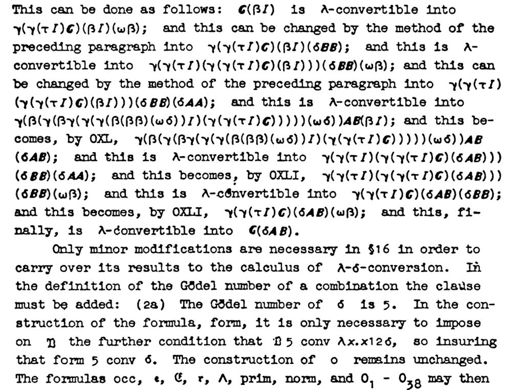

为把第 16 节的结果移植到 λ-δ 转换演算中，只须作一些小的修改。在组合的哥德尔数定义中须加入一条：（2a）$δ$ 的哥德尔数为 5。在公式 $form$ 的构造中，只须对 $D$ 再加上条件 $D5$ conv $λx.x12δ$，从而保证 $form5$ conv $δ$。$o$ 的构造保持不变。随后可得到具有第 16 节所述性质的 $occ,e,e′,r,Λ,prim,norm$ 和 $o1—o38$，其中 $norm$ λ 定义组合属于某个处于 λ 正规形的公式这一性质。然后也可像以前一样得到 $cb,ncb,O,cnvt,nf$（λ 正规形运算）及 $v$。公式 $cb$ 表示包含 1、3、5，并对从公式 $X,Y$ 形成 $(λab.2•nrab)XY$ 的运算封闭的最小公式集的一个枚举。

Only minor modifications are necessary in §16 in order to carry over its results to the calculus of λ-δ-conversion. In the definition of the Gödel number of a combination the clause must be added: (2a) The Gödel number of δ is 5. In the construction of the formula, form, it is only necessary to impose on D the further condition that D5 conv λx.x12δ, so insuring that form 5 conv δ. The construction of o remains unchanged. The formulas occ, e, e′, r, Λ, prim, norm, and o₁–o₃₈ may then be obtained, having the properties described in §16 (norm λ-defines the property of a combination of belonging to a formula which is in λ-normal form). The formulas cb, ncb, O, cnvt, nf (the λ-normal form of), and v may then also be obtained as before. The formula cb represents an enumeration of the least set of formulas which contains 1,3,5 and is closed under the operation of forming (λab.2•nr ab)XY from the formulas X,Y.

除了 $norm$，还可以得到公式 $dnorm$，它 λ 定义组合属于某个处于 δ 正规形的公式这一性质。细节留给读者。

Besides norm it is also possible to obtain a formula dnorm which λ-defines the property of a combination of belonging to a formula in δ-normal form. Details of this are left to the reader.

可以得到公式 $o39—o42$，它们与运算 OXXXIX—OXLII 的关系，正如 $o1—o38$ 与 OI—OXXXVIII 的关系一样。我们给出 $o40,o42$ 两种情形的细节。令 $i40$ 为满足下列条件的公式，再按下式定义 $o40$：

Formulas o₃₉–o₄₂ may be obtained, related to the operations OXXXIX–OXLII in the same way that o₁–o₃₈ are related to OI–OXXXVIII. We give details in the case of o₄₀ and o₄₂. Let i₄₀ be a formula such that

$$𝔧401convI,𝔧402convλx.2·nrx1[2·nr[2·nr5x112]x12];o40→λx.𝔧40[parx+parx1+parx11+primx112+dnormx112+primx12+dnormx12+eqηx2∔eqx112x12∔13¯]x,$$

其中 $η$ 是表示 $βI$ 的哥德尔数的公式。令 $i42$ 为满足下列条件的公式，再按下式定义 $o42$：

η being the formula representing the Gödel number of βI. Let i₄₂ be a formula such that

$$𝔧421convI,𝔧422convλx.2·nrx1[2·nr[2·nr5(formx12)](formx12)];o42→λx.𝔧42[parx+parx1+h(vx12)x12+eqζx2∔6]x,$$

其中 $ζ$ 是表示 $ωβ$ 的哥德尔数的公式，而 $h$ 满足 $h1$ conv $λx.xI$，$h2$ conv $λx.min(prim(formx))(dnorm(formx))$。

where ζ is the formula representing the Gödel number of ωβ, and h is such a formula that h1 conv λx.xI and h2 conv λx.min(prim(form x))(dnorm(form x)).

于是可得到类似于 $O$、但涉及全部 $o1—o42$ 而不只是 $o1—o38$ 的公式 $dO$。令：

Then a formula dO may be obtained, analogous to O but involving all of o₁–o₄₂ instead of only o₁–o₃₈. Let

$$dcnvt→λab.dOba.$$

则若 $G$ 表示组合 $M$ 的哥德尔数，公式 $dcnvtG$ 枚举可由 $M$ 经 λ-δ 转换得到的组合的哥德尔数，而 $cnvtG$ 只枚举可由 $M$ 经 λ 转换得到的组合的哥德尔数。

Then, if G represents the Gödel number of a combination M, the formula dcnvt G enumerates the Gödel numbers of combinations obtainable from M by λ-δ-conversion (whereas cnvt G enumerates merely the Gödel numbers of combinations obtainable from M by λ-conversion).

利用公式 $dnorm$，还可以得到公式 $dnf$，它 λ 定义“公式的 δ 正规形”这一运算；以及公式 $dncb$，它枚举那些属于处于 δ 正规形且不含自由变量的公式的组合的哥德尔数。这些定义与 $nf,ncb$ 的定义平行。

It is also possible, by using the formula dnorm, to obtain a formula dnf which λ-defines the operation δ-normal form of a formula, and a formula dncb which enumerates the Gödel numbers of combinations which belong to formulas in δ-normal form and contain no free variables. The definitions parallel those of nf and ncb.

最后，在 λ-δ 转换演算中，可以得到公式 $met$，它提供函数 $form$ 的一种逆：若公式 $M$ 不含自由变量且具有 δ 正规形，则 $metM$ 可转换为表示属于 $M$ 的 δ 正规形的哥德尔数的公式。定义如下：

Finally, in the calculus of λ-δ-conversion, a formula met may be obtained which provides a kind of inverse of the function form: if M is a formula which contains no free variables and has a δ-normal form, then met M is convertible into the formula representing the Gödel number belonging to the δ-normal form of M. The definition is as follows:

$$met→λx.dncb(𝔭(λn.δ(form(dncbn))x)1).$$

### 21. 一个符号逻辑系统

### 21. A SYSTEM OF SYMBOLIC LOGIC

若把真值“真”和“假”分别与正整数 2 和 1 等同起来，就可以在 λ-δ 转换演算的基础上建立一个符号逻辑系统。该系统只有一个原始公式或公理，即公式 2；有七条推理规则，即 λ-δ 转换的规则 I—VII。系统的可证公式或论题，就是可由公式 2 经推理规则应用的序列推导出的公式。（事实上，推理规则 II、IV、VI 是多余的，即删去它们不会减少可证公式的类；这由 7 XXVII，确切地说由 λ-δ 转换演算中与该定理对应的定理得出。）

If we identify the truth values, truth and falsehood, with the positive integers 2 and 1 respectively, we may base a system of symbolic logic on the calculus of λ-δ-conversion. This system has one primitive formula or axiom, namely the formula 2, and seven rules of inference, namely the rules I–VII of λ-δ-conversion; the provable formulas, or theses, of the system are the formulas which can be derived from the formula 2 by sequences of applications of the rules of inference. (As a matter of fact, the rules of inference II,IV,VI are superfluous, in the sense that their omission would not decrease the class of provable formulas, as follows from 7 XXVII, or rather from the analogue of this theorem for the calculus of λ-δ-conversion.)

把真值“真”和“假”与正整数 2 和 1 等同起来，当然是人为的，但看来并不会引起实际的形式困难。如果认为这不可取，可以对系统作一个小修改来避免这种人为性：引入符号 $⊢$，把原始公式写为 $⊢2$ 而不是 $2$。这样，系统的所有论题前面都加上符号 $⊢$，可以把它解释为断言其后面的东西等于 2。

The identification of the truth values, truth and falsehood, with the positive integers 2 and 1 is, of course, artificial, but apparently it gives rise to no actual formal difficulty. If it be thought objectionable, the artificiality may be avoided by a minor modification in the system, which consists in introducing a symbol ⊢ and writing ⊢2, instead of 2, as the primitive formula; all the theses of the system will then be preceded by the sign ⊢, which may be interpreted as asserting that that which follows is equal to 2.

由这些定义可知，$A∨B$ 只有在 $A$ 或 $B$ 至少有一个是论题时才可能是论题，而且看来无论怎样适当修改定义，都不能改变这种情形。已知经典逻辑系统，例如 Whitehead 和 Russell 的《数学原理》系统，并不具有这一性质。因此，显然当前系统在一个可视为具有有穷主义性质的方向上不同于经典系统。

It follows from these definitions that A∨B cannot be a thesis unless either A or B is a thesis, and this situation apparently cannot be altered by any suitable change in the definitions. Since this property is known to fail for classical systems of logic, e.g., that of Whitehead and Russell’s Principia Mathematica, it is clear that the present system therefore differs from the classical systems in a direction which may be regarded as finitistic in character.

正整数函数当然由 λ 定义这些函数的公式在系统中表示；正整数的性质及正整数之间的关系，则由 λ 定义相应特征函数的公式表示。命题函数“是一个正整数”在系统中由公式 $Π$ 表示，定义如下，参照第 16、20 节：

Functions of positive integers are of course represented in the system by the formulas λ-defining these functions, and properties of and relations between positive integers are represented by the formulas λ-defining the corresponding characteristic functions. The propositional function to be a positive integer is represented in the system as a formula Π, defined as follows (referring to §§16,20):

$$Π→λx.v(metx).$$

一般的相等或同一关系，在内涵意义下，由 $δ$ 表示。

The general relation of equality or identity (in intension) is represented by δ.

可以引入存在量词 $Σ$：

An existential quantifier Σ may be introduced:

$$Σ→λf.f(ιf).$$

这里 $ι$ 表示一个一般选择算子。给定公式 $F$，若存在某个公式 $A$ 使 $FA$ conv $2$，则 $ιF$ 就是具有这一性质的公式 $A$ 之一；反之，$ιF$ 无正规形。因此，$Σ$ 表示一个没有否定的存在量词：若存在公式 $A$ 使 $FA$ conv $2$，则 $ΣF$ conv $2$；反之，$ΣF$ 无正规形。

Here ι represents a general selection operator. Given a formula F, if there is any formula A such that FA conv 2, then ιF is one of the formulas A having this property; and in the contrary case ιF has no normal form. Consequently Σ represents an existential quantifier without a negation: ΣF conv 2 if there is a formula A such that FA conv 2, and in the contrary case ΣF has no normal form.

算子 $ι$ 应与 Hilbert 的 $ε$ 算子（[31] 及其他文献）比较，或更恰当地与 Hilbert 和 Bernays [33] 的 $μ$ 算子比较。使用 $ι$ 时应注意：系统中由 $F,G$ 表示的命题函数等价，并不必然蕴含 $ιF$ 与 $ιG$ 相等。

The operator ι should be compared with Hilbert’s operator ε [31 and elsewhere], or, perhaps better, the μ-operator of Hilbert and Bernays [33]. The ι should be used with the caution that the equivalence of propositional functions represented in the system by F and G need not imply the equality of ιF and ιG.

把 $ι$ 解释为选择算子、把 $Σ$ 解释为存在量词，依赖于把系统中的形式可证性与真等同起来。但系统所具有的一种完备性性质为此提供了根据：一个不可证的公式，除非它可转换为一个不同于 2 的主正规形、从而可被否证，否则就必定无正规形，因而没有意义。

The interpretation of ι as a selection operator and of Σ as an existential quantifier depends on an identification of formal provability in the system with truth. But this is justified by a completeness property which the system possesses: a formula which is not provable, unless it is convertible into a principal normal form other than 2 and hence is disprovable, must have no normal form, and hence be meaningless.

为便于进一步展开该系统，或为了与更通常的记号比较，可以引入缩写：

For convenience in the further development of the system, or for the sake of comparison with more usual notations, we may introduce the abbreviations:

$$[ιxM]→ι(λxM).[∃xM]→Σ(λxM).$$

在系统中引入全称量词的问题，或者等价地，引入具有否定的存在量词的问题，超出了本书范围。由 Gödel [27] 的方法可知，任何通过定义引入的全称量词都会具有某种不完备性；实际上，这与按照哥德尔的结果，几乎任何一致且充分适用的形式逻辑系统都必须具有的不完备性性质相同，只不过在这里，它从可证性的领域转移到了量词意义的领域。

The problem of introducing universal quantifiers into the system, or, equivalently, of introducing existential quantifiers having a negation, is beyond the scope of the present treatise. It follows by the methods of Gödel [27] that any universal quantifier introduced by definition will have a certain character of incompleteness; this is in effect the same incompleteness property which, in accordance with the results of Gödel, almost any consistent and satisfactorily adequate system of formal logic must have, except that it here appears transferred from the realm of provability to the realm of meaning of the quantifiers.

刚才勾勒的符号逻辑系统的一致性，是 7 XXX 的推论，确切地说，是 λ-δ 转换演算中与该定理对应的定理的推论。因为两个不同的主正规形不可能彼此可转换，所以并非每个公式都是可证的。

The consistency of the system of symbolic logic just outlined is a corollary of 7 XXX, or rather of the analogue of this theorem for the calculus of λ-δ-conversion. For two different principal normal forms cannot be interconvertible, and hence not every formula is provable.

在这个系统中，已知集合论悖论的失效，在一些较简单的情形下，仅仅取决于那个本来会导致悖论的公式没有正规形。例如，在 Russell 悖论的情形，我们发现 $(λx.¬(xx))(λx.¬(xx))$ 无正规形；在 Grelling 关于异谓词的悖论，或者按我们的说法，关于异谓哥德尔数的悖论中，我们发现 $(λx.¬(formxx))(met(λx.¬(formxx)))$ 无正规形。在更复杂、表达悖论需要全称量词的情形中，悖论的失效可能取决于上文指出的量词的不完备性性质。

(The failure in this system of the known paradoxes of set theory depends, in some of the simpler cases, merely on the fact that the formula which would otherwise lead to the paradox fails to have a normal form. Thus, in the case of Russell’s paradox, we find that (λx.¬(xx))(λx.¬(xx)) has no normal form; and in the case of Grelling’s paradox concerning heterological words, or, as we shall put it, concerning heterological Gödel numbers, we find that (λx.¬(form xx))(met(λx.¬(form xx))) has no normal form. In more complicated cases, where the expression of the paradox requires a universal quantifier, the failure may depend on the above indicated incompleteness property of the quantifier.)